# UGA Real Analysis Solutions (Fall 2014 – Spring 2021)

# 1 Preface

I’d like to extend my gratitude to Peter Woolfitt for supplying many solutions and checking many proofs of the rest in problem sessions. Many other solutions contain input and ideas from other graduate students and faculty members at UGA, along with questions and answers posted on Math Stack Exchange or Math Overflow.

# 2 Undergraduate Analysis: Uniform Convergence

## 2.1 Fall 2018 # 1 $\done$

Let $f(x) = \frac 1 x$. Show that $f$ is uniformly continuous on $(1, \infty)$ but not on $(0,\infty)$.

- Uniform continuity:
  $$\begin{align*}
  \forall \varepsilon>0, \exists \delta({\varepsilon})>0 \quad\text{such that}\quad {\left\lvert {x-y} \right\rvert}<\delta \implies {\left\lvert {f(x) - f(y)} \right\rvert} < {\varepsilon}
  .\end{align*}$$
- Negating uniform continuity: $\exists {\varepsilon}> 0$ such that $\forall \delta({\varepsilon})$ there exist $x, y$ such that ${\left\lvert {x-y} \right\rvert} < \delta$ *and* ${\left\lvert {f(x) - f(y)} \right\rvert} > {\varepsilon}$.
- Archimedean property: for all $x,y\in {\mathbb{R}}$ there exists an $n \in {\mathbb{N}}$ such that $nx>y$. Take $x={\varepsilon}, y=1$, so $n{\varepsilon}> 1$ and ${1\over n} < {\varepsilon}$.

1 is the only constant around, so try to use it for uniform continuity. To negate, find a bad $x$: since $1/x$ blows up near zero, go hunting for small $x$s!

- **Claim**: $f(x) = \frac 1 x$ is uniformly continuous on $(c, \infty)$ for any $c > 0$.
  - Note that
    $$\begin{align*}
    {\left\lvert {x} \right\rvert}, {\left\lvert {y} \right\rvert} > c > 0 \implies {\left\lvert {xy} \right\rvert} = {\left\lvert {x} \right\rvert}{\left\lvert {y} \right\rvert} > c^2 \implies \frac{1}{{\left\lvert {xy} \right\rvert}} < \frac 1 {c^{2}}
    .\end{align*}$$
  - Letting $\varepsilon$ be arbitrary, choose $\delta < \varepsilon c^2$.
    - Note that $\delta$ does not depend on $x, y$.
  - Then
    $$\begin{align*}
    {\left\lvert {f(x) - f(y)} \right\rvert}
    &= {\left\lvert {\frac 1 x - \frac 1 y} \right\rvert} \\
    &= \frac{{\left\lvert {x-y} \right\rvert}}{xy} \\
    &\leq \frac{\delta}{xy} \\
    &< \frac{\delta}{c^2} \\
    &< \varepsilon
    .\end{align*}$$
- **Claim**: $f$ is *not* uniformly continuous when $c=0$.
  - Take $\varepsilon < 1$, and let $\delta = \delta({\varepsilon})$ be arbitrary.
  - Let $x_n = \frac 1 n$ for $n\geq 1$.
  - Choose $n$ large enough such that ${1\over n} < \delta$
  - Then a computation:
    $$\begin{align*}
    {\left\lvert {x_n - x_{n+1}} \right\rvert}
    &= \frac 1 n - \frac 1 {n+1} \\
    &= {1\over n(n+1) } \\
    &< {1\over n} \\
    &< \delta
    ,\end{align*}$$
  - Why this can be done: by the Archimedean property of ${\mathbb{R}}$, for any $\delta\in {\mathbb{R}}$, one can choose choose $n$ such that $n\delta > 1$. We’ve also used that $n+1 > 1$ so ${1\over n+1}< 1$
  - Note that $f(x_n) = n$, so
    $$\begin{align*}
    {\left\lvert {f(x_{n+1}) - f(x_{n})} \right\rvert} = (n+1) - n = 1 > \varepsilon
    .\end{align*}$$

## 2.2 Fall 2017 # 1 $\done$

Let
$$\begin{align*}
f(x) = \sum _{n=0}^{\infty} \frac{x^{n}}{n !}.
\end{align*}
Describe the intervals on which \(f\) does and does not converge uniformly.$$

- $f_N\to f$ uniformly $\iff$ ${\left\lVert {f_N - f} \right\rVert}_\infty \to 0$.
  - Applied to sums:
    $$\begin{align*}
    \sum_{0 \leq k\leq N} f_n \overset{u}\to \sum_{k\geq 0} f_n \iff {\left\lVert {\sum_{k\geq N+1} f_n } \right\rVert}_{\infty} \to 0
    .\end{align*}$$
- An infinite sum is defined as the pointwise limit of its partial sums:
  $$\begin{align*}
  \sum_{n=0}^\infty c_n x^n \mathrel{\vcenter{:}}=\lim_{N\to \infty} \sum_{n=0}^N c_n x^n
  .\end{align*}$$
- Uniformly decaying terms for uniformly convergent series: if $\sum_{n=0}^\infty f_n(x)$ converges uniformly on a set $A$, then
  $$\begin{align*}
  {\left\lVert {f_n} \right\rVert}_{\infty, A} \mathrel{\vcenter{:}}=\sup_{x\in A} {\left\lvert {f_n(x)} \right\rvert} \overset{n\to\infty}\longrightarrow 0
  .\end{align*}$$
- $M{\hbox{-}}$test: if $f_n:A \to{\mathbb{C}}$ with ${\left\lVert {f_n} \right\rVert}_\infty < M_n$ and $\sum M_n < \infty$, then $\sum f_n$ converges uniformly and absolutely.
  - If the $f_n$ are continuous, the uniform limit theorem implies $\sum f_n$ is also continuous.

No real place to start, so pick the nicest place: compact intervals. Then bounded intervals, then unbounded sets.

- Set $f_N(x) = \sum_{n=1}^N {x^n \over n!}$.
  - Then by definition, $f_N(x) \to f(x)$ pointwise on ${\mathbb{R}}$.
- **Claim**: $f_N$ converges on compact intervals
  - For any compact interval $[-M, M]$, we have
    $$\begin{align*}
    {\left\lVert {f_N(x) - f(x)} \right\rVert}_\infty
    &= \sup_{x\in [-M, M] } ~{\left\lvert {\sum_{n=N+1}^\infty {x^n \over {n!}} } \right\rvert} \\
    &\leq \sup_{x\in [-M, M] } ~\sum_{n=N+1}^\infty {\left\lvert { {x^n \over {n!}} } \right\rvert} \\
    &\leq \sum_{n=N+1}^\infty {M^n \over n!} \\
    &\leq \sum_{n=0}^\infty {M^n \over {n!} } \quad\text{since all additional terms are positive} \\
    &= e^M \\
    &<\infty
    ,\end{align*}
    so \(f_N \to f\) uniformly on \([-M, M]\) by the M-test.
    Note: we’ve used that this power series converges to \(e^x\) pointwise everywhere.$$
- This argument shows that $f$ converges on any bounded set.
- **Claim**: $f_N$ does not converge uniformly on all of ${\mathbb{R}}$.
  - Uniformly convergent sums have uniformly decaying terms:
    $$\begin{align*}
    \sum_{n\leq N} g_n \overset{N\to\infty}\longrightarrow\sum g_n \text{ uniformly on } A \implies {\left\lVert {g_n} \right\rVert}_{\infty, A} \mathrel{\vcenter{:}}=\sup_{x\in A} {\left\lvert {g_n(x)} \right\rvert} \overset{n\to\infty}\longrightarrow 0
    .\end{align*}$$
  - Take $B_N$ a ball of radius $N$ about 0, then for $N>1$, note that $x=N$ on the boundary and so
    $$\begin{align*}
    {\left\lVert {x^k \over k!} \right\rVert}_{\infty, B_N} = {N^k \over k!} \overset{N\to\infty}\longrightarrow\infty
    .\end{align*}$$
- **Conclusion**: $f_N$ converges on any bounded $A\subseteq {\mathbb{R}}$ but not on all of ${\mathbb{R}}$.

## 2.3 Fall 2014 # 1 $\done$

Let $\left\{{f_n}\right\}$ be a sequence of continuous functions such that $\sum f_n$ converges uniformly.

Prove that $\sum f_n$ is also continuous.

- The uniform limit theorem.
- ${\varepsilon}/3$ trick.

If $F_N\to F$ uniformly with each $F_N$ continuous, then $F$ is continuous.

- Follows from an $\varepsilon/3$ argument:
  $$\begin{align*}
  {\left\lvert {F(x) - F(y} \right\rvert} \leq
  {\left\lvert {F(x) - F_N(x)} \right\rvert} + {\left\lvert {F_N(x) - F_N(y)} \right\rvert} + {\left\lvert {F_N(y) - F(y)} \right\rvert}
  \leq {\varepsilon}\to 0
  .\end{align*}$$
  - The first and last ${\varepsilon}/3$ come from uniform convergence of $F_N\to F$.
  - The middle ${\varepsilon}/3$ comes from continuity of each $F_N$.
- Now setting $F_N\mathrel{\vcenter{:}}=\sum_{n=1}^N f_n$ yields a finite sum of continuous functions, which is continuous.
- Each $F_N$ is continuous and $F_N\to F$ uniformly, so $F$ is continuous.

## 2.4 Spring 2017 # 4 $\done$

Let $f(x, y)$ on $[-1, 1]^2$ be defined by
$$\begin{align*}
f(x, y) = \begin{cases}
\frac{x y}{\left(x^{2}+y^{2}\right)^{2}} & (x, y) \neq (0, 0) \\
0 & (x, y) = (0, 0)
\end{cases}
\end{align*}
Determine if \(f\) is integrable.$$

- Just Calculus.
- $1/r$ is not integrable on $(0, 1)$.

Switching to polar coordinates and integrating over the quarter of the unit disc $D \cap Q_1 \subseteq I^2$ in quadrant 1, we have
$$\begin{align*}
\int_{I^2} f \, dA
&\geq \int_D f \, dA \\
&= \int_0^{\pi/2} \int_0^1 \frac{r^2 \cos(\theta)\sin(\theta)}{r^4} ~r~\,dr\,d\theta\\
&= \int_0^{\pi/2} \int_0^1 \frac{\cos(\theta)\sin(\theta)}{r} \,dr\,d\theta\\
&= \qty{ \int_0^1 {1\over r } \,dr} \qty{ \int_0^{\pi/2} \cos(\theta)\sin(\theta) \,d\theta} \\
&= \qty{ \int_0^1 {1\over r } \,dr} \qty{ \int_0^{1} u \,du} && u=\sin(\theta)\\
&= {1\over 2}\qty{ \int_0^1 {1\over r } \,dr} \\
&\longrightarrow\infty
.\end{align*}$$

## 2.5 Spring 2015 # 1 $\done$

Let $(X, d)$ and $(Y, \rho)$ be metric spaces, $f: X\to Y$, and $x_0 \in X$.

Prove that the following statements are equivalent:

1. For every $\varepsilon > 0 \quad \exists \delta > 0$ such that $\rho( f(x), f(x_0) ) < \varepsilon$ whenever $d(x, x_0) < \delta$.
2. The sequence $\left\{{f(x_n)}\right\}_{n=1}^\infty \to f(x_0)$ for every sequence $\left\{{x_n}\right\} \to x_0$ in $X$.
- What it means for a sequence to converge.
- Trading $N$s for $\delta$s.
- Let $\left\{{x_n}\right\} \overset{n\to\infty}\to x_0$ be arbitrary; we want to show $\left\{{f(x_n)}\right\}\overset{n\to\infty}\to f(x_0)$.
  - We thus want to show that for every ${\varepsilon}>0$, there exists an $N({\varepsilon})$ such that
    $$\begin{align*}n\geq N({\varepsilon}) \implies \rho(f(x_n), f(x_0)) < {\varepsilon}.\end{align*}$$
- Let ${\varepsilon}>0$ be arbitrary, then by (1) choose $\delta$ such that $\rho(f(x), f(x_0)) < {\varepsilon}$ when $d(x, x_0) < \delta$.
- Since $x_n\to x$, there is some $N$ such that $n\geq N \implies d(x_n, x_0) < \delta$
- Then for $n\geq N$, $d(x_n, x_0) < \delta$ and thus $\rho(f(x_n), f(x_0)) < {\varepsilon}$, so $f(x_n)\to f(x_0)$ by definition.

> The direct implication is not a good idea here, since you need a handle on *all* $x$ in a neighborhood of $x_0$, not just a specific sequence.
- By contrapositive, show that $\not 1\implies \not 2$.
- Need to show: if $f$ is not ${\varepsilon}{\hbox{-}}\delta$ continuous at $x_0$, then there exists a sequence $x_n\to x_0$ where $f(x_n)\not\to f(x_0)$.
- Negating $1$, we have that there exists an ${\varepsilon}>0$ such that for all $\delta$, there exists an $x$ with $d(x, x_0) < \delta$ but $\rho(f(x), f(x_0))>{\varepsilon}$
- So take a sequence of deltas $\delta_n = {1\over n}$, apply this to produce a sequence $x_n$ with $d(x_n, x_0) < \delta_n \mathrel{\vcenter{:}}={1\over n} \longrightarrow 0$ and $\rho(f(x_n), f(x_0)) > {\varepsilon}$ for all $n$.
- This yields a sequence $x_n \to x_0$ where $f(x_n) \not\to f(x_0)$.

## 2.6 Fall 2014 # 2 $\done$

Let $I$ be an index set and $\alpha: I \to (0, \infty)$.

1. Show that
   $$\begin{align*}
   \sum_{i \in I} a(i):=\sup _{\substack{ J \subset I \\ J \text { finite }}} \sum_{i \in J} a(i)<\infty \implies I \text{ is countable.}
   \end{align*}$$
2. Suppose $I = {\mathbb{Q}}$ and $\sum_{q \in \mathbb{Q}} a(q)<\infty$. Define
   $$\begin{align*}
   f(x):=\sum_{\substack{q \in \mathbb{Q}\\ q \leq x}} a(q).
   \end{align*}
   Show that \(f\) is continuous at \(x \iff x\not\in {\mathbb{Q}}\).$$
- Can always filter sets $X$ with a function $X\to {\mathbb{R}}$.
- Countable union of countable sets is still countable.
- Continuity: $\lim_{y\to x} f(y) = f(x)$ from either side.
- Trick: pick enumerations of countable sets and reindex sums
- Set $S \mathrel{\vcenter{:}}=\sum_{i\in I} \alpha(i)$, we will show that $S<\infty \implies I$ is countable.
- Write
  $$\begin{align*}
  I = \displaystyle\bigcup_{n\geq 0} S_n, &&
  S_n \mathrel{\vcenter{:}}=\left\{{i\in I {~\mathrel{\Big|}~}\alpha(i) \geq {1\over n}}\right\}
  .\end{align*}
  Note that \(S_n \subseteq S\) for all \(n\), so \(\sum_{i\in I}\alpha(i) \geq \sum_{i\in S_n} \alpha(i)\) for all \(n\).
  It suffices to show that \(S_n\) is countable, since \(I\) is a countable union of \(S_n\).$$
- There is an inequality
  $$\begin{align*}
  \infty
  &> S \mathrel{\vcenter{:}}=\sum_{i\in I} \alpha(i) \\
  &\geq \sum_{i\in S_n} \alpha(i) \\
  &\geq \sum_{i\in S_n} {1\over n} \\
  &= {1\over n} \sum_{i\in S_n} 1 \\
  &= \qty{1\over n} \# S_n \\ \\
  \implies \infty &> n S \geq \# S_n
  .\end{align*}$$
- We’ll prove something more general: let $Q = \left\{{q_k}\right\}$ be countable and $\left\{{\alpha_k \mathrel{\vcenter{:}}=\alpha(q_k)}\right\}$ be summable, and define
  $$\begin{align*}
  f(x) \mathrel{\vcenter{:}}=\sum_{q_k\leq x} \alpha_k
  .\end{align*}$$
  - $f$ is always discontinuous precisely on the countable set $Q$ and continuous on ${\mathbb{R}}\setminus Q$.
  - $f$ is always left-continuous, is right-continuous at $x\in{\mathbb{R}}\setminus Q$, and *not* right-continuous at $x\in Q$
  - $f$ has jump discontinuities at every $q_m$, where the jump is precisely $\alpha_m$.
- This follows from computing the left and right limits:
  $$\begin{align*}
  f(x^+) &= \lim_{h\to 0} \sum_{q_k \leq x+h} \alpha_k = \sum_{q_k\leq x} \alpha_k = \sum_{q_k < x} \alpha_k + \sum_{q_k = x} \alpha_k \\
  f(x^-) &= \lim_{h\to 0} \sum_{q_k \leq x-h} \alpha_k = \sum_{q_k < x} \alpha_k
  ,\end{align*}
  where we’ve used that \(\left\{{q_k \leq x}\right\} = \left\{{q_k < x}\right\} {\textstyle\coprod}\left\{{x}\right\}\) in the first equality.$$
- Then if $x=q_m$ for some $m$,
  $$\begin{align*}
  f(x^+) &= f(q_m^+) = \sum_{q_k < q_m} \alpha_k + \alpha_m \\
  f(x^-) &= f(a_m^-) = \sum_{q_k< q_m} \alpha_k
  ,\end{align*}
  which clearly differ if \(\alpha_m \neq 0\).$$
- Taking $x\not\in Q$, we have $\left\{{q_k \leq x}\right\} = \left\{{q_k < x}\right\}$, since $\left\{{q_k=x}\right\} = \emptyset$, so
  $$\begin{align*}
  f(x^+) &= \sum_{q_k\leq x} \alpha_k = \sum_{q_k < x} \alpha_k \\
  f(x^-) &= \sum_{q_k< x} \alpha_k
  ,\end{align*}
  so the limits agree.$$
- To recover the result in the problem, let ${\mathbb{Q}}= \left\{{q_k}\right\}$ be any enumeration of the rationals.

# 3 General Analysis

## 3.1 Spring 2020 # 1 $\done$

Prove that if $f: [0, 1] \to {\mathbb{R}}$ is continuous then
$$\begin{align*}
\lim_{k\to\infty} \int_0^1 kx^{k-1} f(x) \,dx = f(1)
.\end{align*}$$

- DCT
- Weierstrass Approximation Theorem
  - If $f: [a, b] \to {\mathbb{R}}$ is continuous, then for every ${\varepsilon}>0$ there exists a polynomial $p_{\varepsilon}(x)$ such that ${\left\lVert {f - p_{\varepsilon}} \right\rVert}_\infty < {\varepsilon}$.
- Suppose $p$ is a polynomial, then integrate by parts:
  $$\begin{align*}
  \lim_{k\to\infty} \int_0^1 kx^{k-1} p(x) \, dx
  &= \lim_{k\to\infty} \int_0^1 \qty{ {\frac{\partial }{\partial x}\,}x^k } p(x) \, dx \\
  &= \lim_{k\to\infty} \left[ x^k p(x) \Big|_0^1 - \int_0^1 x^k \qty{{\frac{\partial p}{\partial x}\,}(x) } \, dx \right] \quad\text{IBP}\\
  &= p(1) - \lim_{k\to\infty} \int_0^1 x^k \qty{{\frac{\partial p}{\partial x}\,}(x) } \, dx
  ,\end{align*}$$
- Thus it suffices to show that
  $$\begin{align*}
  \lim_{k\to\infty} \int_0^1 x^k \qty{{\frac{\partial p}{\partial x}\,} (x) } \, dx = 0
  .\end{align*}$$
- Integrating by parts a second time yields
  $$\begin{align*}
  \lim_{k\to\infty}
  \int_0^1 x^k \qty{{\frac{\partial p}{\partial x}\,}(x) } \, dx
  &= \lim_{k\to\infty}
  {x^{k+1} \over k+1} {\frac{\partial p}{\partial x}\,}(x) \Big|_0^1 - \int_0^1 {x^{k+1} \over k+1} \qty{ {\frac{\partial ^2 p}{\partial x^2}\,}(x)} \, dx \\
  &= \lim_{k\to\infty} {p'(1) \over k+1} - \lim_{k\to\infty} \int_0^1 {x^{k+1} \over k+1} \qty{ {\frac{\partial ^2p}{\partial x^2}\,}(x)} \, dx \\
  &= - \lim_{k\to\infty} \int_0^1 {x^{k+1} \over k+1} \qty{ {\frac{\partial ^2p}{\partial x^2}\,}(x)} \, dx \\
  &= - \int_0^1 \lim_{k\to\infty} {x^{k+1} \over k+1} \qty{ {\frac{\partial ^2p}{\partial x^2}\,}(x)} \, dx \quad\text{by DCT} \\
  &= - \int_0^1 0 \qty{ {\frac{\partial ^2p}{\partial x^2}\,}(x)} \, dx \\
  &= 0
  .\end{align*}$$
  - The DCT can be applied here because polynomials are smooth and $[0, 1]$ is compact, so ${\frac{\partial ^2 p}{\partial x^2}\,}$ is bounded on $[0, 1]$ by some constant $M$ and
    $$\begin{align*} \int_0^1 {\left\lvert {x^k {\frac{\partial ^2 p}{\partial x^2}\,} (x)} \right\rvert} \leq \int_0^1 1\cdot M = M < \infty.\end{align*}$$
- So the result holds when $f$ is a polynomial.
- Now use the Weierstrass approximation theorem:
  - If $f: [a, b] \to {\mathbb{R}}$ is continuous, then for every ${\varepsilon}>0$ there exists a polynomial $p_{\varepsilon}(x)$ such that ${\left\lVert {f - p_{\varepsilon}} \right\rVert}_\infty < {\varepsilon}$.
- Thus
  $$\begin{align*}
  {\left\lvert { \int_0^1 kx^{k-1} p_{\varepsilon}(x)\,dx - \int_0^1 kx^{k-1}f(x)\,dx } \right\rvert}
  &= {\left\lvert { \int_0^1 kx^{k-1} \qty{p_{\varepsilon}(x) - f(x)} \,dx } \right\rvert} \\
  &\leq {\left\lvert { \int_0^1 kx^{k-1} {\left\lVert {p_{\varepsilon}-f} \right\rVert}_\infty \,dx } \right\rvert} \\
  &= {\left\lVert {p_{\varepsilon}-f} \right\rVert}_\infty \cdot {\left\lvert { \int_0^1 kx^{k-1} \,dx } \right\rvert} \\
  &= {\left\lVert {p_{\varepsilon}-f} \right\rVert}_\infty \cdot x^k \Big|_0^1 \\
  &= {\left\lVert {p_{\varepsilon}-f} \right\rVert}_\infty \\ \\
  &\overset{{\varepsilon}\to 0}\to 0
  \end{align*}$$

  and the integrals are equal.
- By the first argument,
  $$\begin{align*}\int_0^1 kx^{k-1} p_{\varepsilon}(x) \,dx = p_{\varepsilon}(1) \text{ for each } {\varepsilon}\end{align*}$$
- Since uniform convergence implies pointwise convergence, $p_{\varepsilon}(1) \overset{{\varepsilon}\to 0}\to f(1)$.

## 3.2 Fall 2019 # 1 $\done$

Let $\{a_n\}_{n=1}^\infty$ be a sequence of real numbers.

1. Prove that if $\displaystyle\lim_{n\to \infty } a_n = 0$, then
   $$\begin{align*}
   \lim _{n \rightarrow \infty} \frac{a_{1}+\cdots+a_{n}}{n}=0
   \end{align*}$$
2. Prove that if $\displaystyle\sum_{n=1}^{\infty} \frac{a_{n}}{n}$ converges, then
   $$\begin{align*}
   \lim _{n \rightarrow \infty} \frac{a_{1}+\cdots+a_{n}}{n}=0
   \end{align*}$$
- Cesaro mean/summation.
- Break series apart into pieces that can be handled separately.
- Idea: once $N$ is large enough, $a_k \approx S$, and all smaller terms will die off as $N\to \infty$.
  - See [this MSE answer](https://math.stackexchange.com/questions/514802/convergence-of-series-implies-convergence-of-cesaro-mean).
- Prove a stronger result:
  $$\begin{align*}
  a_k \to S \implies S_N\mathrel{\vcenter{:}}=\frac 1 N \sum_{k=1}^N a_k \to S
  .\end{align*}$$
- For any ${\varepsilon}> 0$, use convergence $a_k \to S$: choose (and fix) $M = M({\varepsilon})$ large enough such that
  $$\begin{align*}
  k\geq M+1 \implies {\left\lvert {a_k - S} \right\rvert} < \varepsilon
  .\end{align*}$$
- With $M$ fixed, choose $N = N(M, {\varepsilon})$ large enough so that ${1\over N} \sum_{k=1}^{M} {\left\lvert {a_k - S} \right\rvert} < {\varepsilon}$.
- Then
  $$\begin{align*}
  \left|\left(\frac{1}{N} \sum_{k=1}^{N} a_{k}\right)-S\right|
  &= {1\over N} {\left\lvert { \qty{\sum_{k=1}^N a_k} - NS } \right\rvert} \\
  &= {1\over N} {\left\lvert { \qty{\sum_{k=1}^N a_k} - \sum_{k=1}^N S } \right\rvert} \\
  &=\frac{1}{N}\left|\sum_{k=1}^{N}\left(a_{k}-S\right)\right| \\
  &\leq \frac{1}{N} \sum_{k=1}^{N}\left|a_{k}-S\right| \\
  &= {1\over N} \sum_{k=1}^{M} {\left\lvert {a_k - S} \right\rvert} + \sum_{k=M+1}^N {\left\lvert {a_k - S} \right\rvert} \\
  &\leq {1\over N} \sum_{k=1}^{M} {\left\lvert {a_k - S} \right\rvert} + \sum_{k=M+1}^N {{\varepsilon}} \quad \text{since } a_k \to S\\
  &= {1\over N} \sum_{k=1}^{M} {\left\lvert {a_k - S} \right\rvert} + (N - M){{\varepsilon}} \\
  &\leq {\varepsilon}+ (N(M, {\varepsilon}) - M({\varepsilon})){\varepsilon}
  .\end{align*}$$
- Define
  $$\begin{align*}
  \Gamma_n \mathrel{\vcenter{:}}=\sum_{k=n}^\infty \frac{a_k}{k}
  .\end{align*}$$
- $\Gamma_1 = \sum_{k=1}^n \frac{ a_k } k$ is the original series and each $\Gamma_n$ is a tail of $\Gamma_1$, so by assumption $\Gamma_n \overset{n\to\infty}\to 0$.
- Compute
  $$\begin{align*}
  \frac 1 n \sum_{k=1}^n a_k
  &= \frac 1 n (\Gamma_1 + \Gamma_2 + \cdots + \Gamma_{n} \mathbf{- \Gamma_{n+1}}) \\
  .\end{align*}$$
- This comes from consider the following summation:

[figure not shown]

- Use part (a): since $\Gamma_n \overset{n\to\infty}\to 0$, we have ${1\over n} \sum_{k=1}^n \Gamma_k \overset{n\to\infty}\to 0$.
- Also a minor check: $\Gamma_n \to 0 \implies {1\over n}\Gamma_n \to 0$.
- Then
  $$\begin{align*}
  \frac 1 n \sum_{k=1}^n a_k
  &= \frac 1 n (\Gamma_1 + \Gamma_2 + \cdots + \Gamma_{n} \mathbf{- \Gamma_{n+1}}) \\
  &= \qty{ {1\over n } \sum_{k=0}^n \Gamma_k } - \qty{{1\over n}\Gamma_{n+1} } \\
  &\overset{n\to\infty}\to 0
  .\end{align*}$$

## 3.3 Fall 2018 # 4 $\done$

Let $f\in L^1([0, 1])$. Prove that
$$\begin{align*}
\lim_{n \to \infty} \int_{0}^{1} f(x) {\left\lvert {\sin n x} \right\rvert} ~d x= \frac{2}{\pi} \int_{0}^{1} f(x) ~d x
\end{align*}$$

> Hint: Begin with the case that $f$ is the characteristic function of an interval.
- Converting floor/ceiling functions to inequalities: $x-1 \leq {\left\lfloor x \right\rfloor} \leq x$.

Case of a characteristic function of an interval $[a, b]$:

- First suppose $f(x) = \chi_{[a, b]}(x)$.
- Note that $\sin(nx)$ has a period of $2\pi/n$, and thus ${\left\lfloor (b-a) \over (2\pi / n) \right\rfloor} = {\left\lfloor n(b-a)\over 2\pi \right\rfloor}$ full periods in $[a, b]$.
- Taking the absolute value yields a new function with half the period
  - So ${\left\lvert {\sin(nx)} \right\rvert}$ has a period of $\pi/n$ with ${\left\lfloor n(b-a) \over \pi \right\rfloor}$ full periods in $[a, b]$.
- We can compute the integral over one full period (which is independent of *which* period is chosen)
  - We can use translation invariance of the integral to compute this over the period $0$ to $\pi/n$.
  - Since $\sin(nx)$ is positive, it equals ${\left\lvert {\sin(nx)} \right\rvert}$ on its first period, so we have
    $$\begin{align*}
    \int_{\text{One Period}} {\left\lvert {\sin(nx)} \right\rvert} \, dx
    &= \int_0^{\pi/n} \sin(nx)\,dx \\
    &= {1\over n} \int_0^\pi \sin(u) \,du \quad u = nx \\
    &= {1\over n} \qty{-\cos(u)\mathrel{\Big|}_0^\pi} \\
    &= {2 \over n}
    .\end{align*}$$
- Then break the integral up into integrals over full periods $P_1, P_2, \cdots, P_N$ where $N \mathrel{\vcenter{:}}={\left\lfloor n(b-a)/\pi \right\rfloor}$
- Noting that each period is of length $\pi\over n$, so letting $L_n$ be the regions falling *outside* of a full period, we have
- Thus
  $$\begin{align*}
  \int_a^b {\left\lvert {\sin(nx)} \right\rvert} \, dx
  &= \qty{ \sum_{j=1}^{N} \int_{P_j} {\left\lvert {\sin(nx)} \right\rvert} \, dx } + \int_{L_n} {\left\lvert {\sin(nx)} \right\rvert}\,dx \\
  &= \qty{ \sum_{j=1}^{N} {2\over n} } + \int_{L_n} {\left\lvert {\sin(nx)} \right\rvert}\,dx \\
  &= N \qty{2\over n} + \int_{L_n} {\left\lvert {\sin(nx)} \right\rvert}\,dx \\
  &\mathrel{\vcenter{:}}={\left\lfloor (b-a) n \over \pi \right\rfloor} {2\over n} + R_n \\
  &\mathrel{\vcenter{:}}=(b-a)C_n + R_n
  \end{align*}
  where (claim) \(C_n \overset{n\to\infty}\to {2\over \pi}\) and \(R(n) \overset{n\to\infty}\to 0\).$$
- $C_n \to {2\over \pi}$:
  $$\begin{align*}
  {n-1 \over n} \qty{2\over \pi} = {n-1 \over \pi} \qty{2\over n} \leq {\left\lfloor n\over \pi \right\rfloor}\qty{2\over n} \leq {n \over \pi}\qty{2\over n} = {2 \over \pi}
  ,\end{align*}
  then use the fact that \({n-1 \over n} \to 1\).$$
  - Then equality follows by the Squeeze theorem.
- $R_n \to 0$:
  - We use the fact that $m(L_n) \to 0$, then $\int_{L_n} {\left\lvert {\sin(nx)} \right\rvert} \leq \int_{L_n} 1 = m(L_n) \to 0$.
  - This follows from the fact that $L_n$ is the complement of $\cup_j P_j$, the set of full periods, so
    $$\begin{align*}
    m(L_n)
    &= m(b-a) - \sum m(P_j) \\
    &= \qty{b-a} - {\left\lfloor n(b-a) \over \pi \right\rfloor}\qty{\pi \over n} \\
    &\overset{n\to \infty}\to (b-a) - (b-a) \\
    &= 0
    .\end{align*}
    where we’ve used the fact that
    \begin{align*}
    \qty{\pi \over n} \qty{(b-a)n-1 \over \pi}
    &\leq {\left\lfloor n(b-a) \over \pi \right\rfloor}\qty{\pi \over n} \\
    &\leq \qty{\pi \over n} \qty{(b-a)n\over \pi} \\
    &= (b-a)
    ,\end{align*}
    then taking \(n\to \infty\) sends the LHS to \(b-a\), forcing the middle term to be \(b-a\) by the Squeeze theorem.$$

General case:

- By linearity of the integral, the result holds for simple functions:
  - If $f = \sum c_j \chi_{E_j}$ where $E_j = [a_j, b_j]$, we have
    $$\begin{align*}
    \int_0^1 f(x) {\left\lvert {\sin(nx)} \right\rvert}\,dx
    &= \int_0^1 \sum c_j \chi_{E_j}(x) {\left\lvert {\sin(nx)} \right\rvert}\,dx \\
    &= \sum c_j \int_0^1 \chi_{E_j}(x) {\left\lvert {\sin(nx)} \right\rvert}\,dx \\
    &= \sum c_j (b_j - a_j) {2\over \pi} \\
    &= {2\over \pi} \sum c_j (b_j - a_j) \\
    &= {2\over \pi} \sum c_j m(E_j) \\
    &\mathrel{\vcenter{:}}={2\over \pi} \int_0^1 f
    .\end{align*}$$
- Since $f\in L^1$, where simple functions are dense, choose $s_n\nearrow f$ where ${\left\lVert {s_N - f} \right\rVert}_1 < {\varepsilon}$, then
  $$\begin{align*}
  {\left\lvert { \int_0^1 f(x) {\left\lvert {\sin(nx)} \right\rvert} \,dx - \int_0^1 s_N(x) {\left\lvert {\sin(nx)} \right\rvert}\,dx } \right\rvert}
  &= {\left\lvert { \int_0^1 \qty{f(x) - s_N(x)} {\left\lvert {\sin(nx)} \right\rvert} \,dx } \right\rvert} \\
  &\leq \int_0^1 {\left\lvert { f(x) - s_N(x)} \right\rvert} {\left\lvert {\sin(nx)} \right\rvert} \,dx \\
  &= {\left\lVert { \qty{f - s_N} {\left\lvert {\sin(nx)} \right\rvert} } \right\rVert}_1 \\
  &\leq {\left\lVert {f-s_N} \right\rVert}_1 \cdot {\left\lVert {{\left\lvert {\sin(nx)} \right\rvert}} \right\rVert}_\infty \quad\text{by Holder}\\
  &\leq {\varepsilon}\cdot 1
  ,\end{align*}$$
- So the integrals involving $s_N$ converge to the integral involving $f$, and
  $$\begin{align*}
  \lim_{n\to\infty} \int f(x){\left\lvert {\sin(nx)} \right\rvert}
  &= \lim_{n\to\infty} \lim_{N\to\infty} \int s_N(x) {\left\lvert {\sin(nx)} \right\rvert} \\
  &= \lim_{N\to\infty} \lim_{n\to\infty} \int s_N(x) {\left\lvert {\sin(nx)} \right\rvert} \quad\text{because ?}\\
  &= \lim_{N\to \infty} {2\over \pi} \int s_N(x) \\
  &= {2\over \pi} \int f
  ,\end{align*}
  which is the desired result.$$

## 3.4 Fall 2017 # 4 $\done$

Let
$$\begin{align*}
f_{n}(x) = n x(1-x)^{n}, \quad n \in {\mathbb{N}}.
\end{align*}$$

1. Show that $f_n \to 0$ pointwise but not uniformly on $[0, 1]$.
2. Show that
   $$\begin{align*}
   \lim _{n \to \infty} \int _{0}^{1} n(1-x)^{n} \sin x \, dx = 0
   \end{align*}$$

> Hint for (a): Consider the maximum of $f_n$.
- $\sum f_n < \infty \iff \sup f_n \to 0$.
- Negating uniform convergence: $f_n\not\to f$ uniformly iff $\exists {\varepsilon}$ such that $\forall N({\varepsilon})$ there exists an $x_N$ such that ${\left\lvert {f(x_N) - f(x)} \right\rvert} > {\varepsilon}$.
- Exponential inequality: $1+y \leq e^y$ for all $y\in {\mathbb{R}}$.

$f_n\to 0$ pointwise:

- Finding the maximum: can check that ${\frac{\partial f_n}{\partial x}\,} = x(1-x)^{n-1} \qty{1 + (n^2-1)x}$
- This has critical points $x=0, 1, {-1 \over n^2 + 1}$, and the latter is a global max on $[0, 1]$.
- Set $x_n \mathrel{\vcenter{:}}={-1 \over n^2 + 1}$
- Compute
  $$\begin{align*}
  \lim f_n(x_n) = \lim_{n\to \infty } {-n \over n^2 + 1} \qty{1 + x_n}^n = 0\cdot 1 = 0
  .\end{align*}$$
- So $\sup f_n \to 0$, forcing $f_n \to 0$ pointwise.

The convergence is not uniform:

- Let $x_n = \frac 1 n$ and $\varepsilon > e^{-1}$, then
  $$\begin{align*}
  {\left\lVert {nx(1-x)^n - 0} \right\rVert}_\infty
  &\geq {\left\lvert {nx_n (1-x_n)^n} \right\rvert} \\
  &= {\left\lvert {\left( 1 - \frac 1 n\right)^n} \right\rvert} \\
  &> e^{-1} \\
  &> \varepsilon
  .\end{align*}$$
  - Here we’ve used that $(1 + {x\over n})^n \leq e^x$ for all $x\in {\mathbb{R}}$ and all $n$.
  - Follows from $1+y \leq e^y$ applied to $y = x/n$.
- Thus ${\left\lVert {f_n - 0} \right\rVert}_\infty = {\left\lVert {f_n} \right\rVert}_\infty > e^{-1} > 0$.
- Noting that $\sin(x) \leq 1$, we have
  $$\begin{align*}
  {\left\lvert {\int_0^1 n(1-x)^{n} \sin(x)} \right\rvert}
  &\leq \int_0^1 {\left\lvert {n(1-x)^n \sin(x)} \right\rvert} \\
  &\leq \int_0^1 {\left\lvert {n (1-x)^n} \right\rvert} \\
  &= n\int_0^1 (1-x)^n \\
  &= -\frac{n(1-x)^{n+1}}{n+1} \\
  &\overset{n\to\infty}\longrightarrow 0
  .\end{align*}$$

## 3.5 Spring 2017 # 3 $\work$

Let
$$\begin{align*}
f_{n}(x) = a e^{-n a x} - b e^{-n b x} \quad \text{ where } 0 < a < b.
\end{align*}$$

Show that

1. $\sum_{n=1}^{\infty} \left|f_{n}\right|$ is not in $L^{1}([0, \infty), m)$

> Hint: $f_n(x)$ has a root $x_n$.
2. $$\begin{align*}
   \sum_{n=1}^{\infty} f_{n} \text { is in } L^{1}([0, \infty), m)
   {\quad \operatorname{and} \quad}
   \int _{0}^{\infty} \sum _{n=1}^{\infty} f_{n}(x) \,dm = \ln \frac{b}{a}
   \end{align*}$$
- $f_n$ has a root:
  $$\begin{align*}
  ae^{-nax} = be^{-nbx}
  &\iff {1\over n} = e^{-nbx} e^{nax} = e^{n(b-a)x}
  \iff x = {\ln\qty{a\over b} \over n(a-b)} \mathrel{\vcenter{:}}= x_n
  .\end{align*}$$
- Thus $f_n$ only changes sign at $x_n$, and is strictly positive on one side of $x_n$.
- Then
  $$\begin{align*}
  \int_{\mathbb{R}}\sum_n {\left\lvert {f_n(x)} \right\rvert}\,dx
  &= \sum_n \int_{\mathbb{R}}{\left\lvert {f_n(x)} \right\rvert} \,dx \\
  &\geq \sum_n \int_{x_n}^\infty f_n(x) \, dx \\
  &= \sum_n {1\over n} \qty{ e^{-bnx} - e^{-anx}\Big|_{x_n}^\infty } \\
  &= \sum_n {1\over n} \qty{ e^{-bnx_n} - e^{-anx_n} }
  .\end{align*}$$

## 3.6 Fall 2016 # 1 $\done$

Define
$$\begin{align*}
f(x) = \sum_{n=1}^{\infty} \frac{1}{n^{x}}.
\end{align*}
Show that \(f\) converges to a differentiable function on \((1, \infty)\) and that
\begin{align*}
f'(x) =\sum_{n=1}^{\infty}\left(\frac{1}{n^{x}}\right)^{\prime}.
\end{align*}$$

> Hint:
> $$\begin{align*}
> \left(\frac{1}{n^{x}}\right)' = -\frac{1}{n^{x}} \ln n
> \end{align*}$$
- ?
- Set $f_N(x) \mathrel{\vcenter{:}}=\sum_{n=1}^N n^{-x}$, so $f(x) = \lim_{N\to\infty} f_N(x)$.
- If an interchange of limits is justified, we have
  $$\begin{align*}
  {\frac{\partial }{\partial x}\,} \lim_{N\to\infty} \sum_{n=1}^N n^{-x}
  &= \lim_{h\to 0} \lim_{N\to\infty} {1\over h} \left[ \qty{\sum_{n=1}^N n^{-x}} - \qty{\sum_{n=1}^N n^{-(x+h)} }\right] \\
  &\mathop{\mathrm{=}}_{?} \lim_{N\to\infty} \lim_{h\to 0} {1\over h} \left[ \qty{\sum_{n=1}^N n^{-x}} - \qty{\sum_{n=1}^N n^{-(x+h)} }\right] \\
  &= \lim_{N\to\infty} \lim_{h\to 0} {1\over h} \left[ {\sum_{n=1}^N n^{-x}} - {n^{-(x+h)} }\right] \quad\text{(1)} \\
  &= \lim_{N\to\infty} \sum_{n=1}^N \lim_{h\to 0} {1\over h} \left[ n^{-x} - n^{-(x+h)} \right] \quad\text{since this is a finite sum} \\
  &\mathrel{\vcenter{:}}=\lim_{N\to\infty} \sum_{n=1}^N {\frac{\partial }{\partial x}\,}\qty{1 \over n^x} \\
  &= \lim_{N\to\infty} \sum_{n=1}^N -{\ln(n) \over n^x}
  ,\end{align*}
  where the combining of sums in (1) is valid because \(\sum n^{-x}\) is absolutely convergent for \(x>1\) by the \(p{\hbox{-}}\)test.$$
- Thus it suffices to justify the interchange of limits and show that the last sum converges on $(1, \infty)$.
- Claim: $\sum n^{-x}\ln(n)$ converges.
  - Use the fact that for any fixed ${\varepsilon}>0$,
    $$\begin{align*}
    \lim_{n\to\infty} {\ln(n) \over n^{\varepsilon}}
    \mathop{\mathrm{=}}^{L.H.} \lim_{n\to\infty}{1/n \over {\varepsilon}n^{{\varepsilon}-1}}
    = \lim_{n\to\infty} {1\over {\varepsilon}n^{\varepsilon}} = 0
    ,\end{align*}$$
  - This implies that for a fixed ${\varepsilon}>0$ and for any constant $c>0$ there exists an $N$ large enough such that $n\geq N$ implies $\ln(n)/n^{\varepsilon}< c$, i.e. $\ln(n) < c n^{{\varepsilon}}$.
  - Taking $c=1$, we have $n\geq N \implies \ln(n) < n^{\varepsilon}$
  - We thus break up the sum:
    $$\begin{align*}
    \sum_{n\in {\mathbb{N}}} {\ln(n) \over n^x}
    &= \sum_{n=1}^{N-1} { \ln(n) \over n^x} + \sum_{n=N}^\infty {\ln(n) \over n^x} \\
    &\leq \sum_{n=1}^{N-1} { \ln(n) \over n^x} + \sum_{n=N}^\infty {n^{\varepsilon}\over n^x} \\
    &\mathrel{\vcenter{:}}= C_{\varepsilon}+ \sum_{n=N}^\infty {n^{\varepsilon}\over n^x} \quad \text{with $C_{\varepsilon}<\infty$ a constant}\\
    &= C_{\varepsilon}+ \sum_{n=N}^\infty {1 \over n^{x-{\varepsilon}}}
    ,\end{align*}
    where the last term converges by the \(p{\hbox{-}}\)test if \(x-{\varepsilon}> 1\).$$
  - But ${\varepsilon}$ can depend on $x$, and if $x\in (1, \infty)$ is fixed we can choose ${\varepsilon}< {\left\lvert {x-1} \right\rvert}$ to ensure this.
- Claim: the interchange of limits is justified.

## 3.7 Fall 2016 # 5 $\done$

Let $\phi\in L^\infty({\mathbb{R}})$. Show that the following limit exists and satisfies the equality
$$\begin{align*}
\lim _{n \to \infty} \left(\int _{\mathbb{R}} \frac{|\phi(x)|^{n}}{1+x^{2}} \, dx \right) ^ {\frac{1}{n}}
= {\left\lVert {\phi} \right\rVert}_\infty.
\end{align*}$$

- ?

Let $L$ be the LHS and $R$ be the RHS.

Claim: $L\leq R$. - Since ${\left\lvert {\phi } \right\rvert}\leq {\left\lVert {\phi} \right\rVert}_\infty$ a.e., we can write
$$\begin{align*}
L^{1\over n}
&\mathrel{\vcenter{:}}=\int_{\mathbb{R}}{ {\left\lvert {\phi(x)} \right\rvert}^n \over 1+ x^2} \\
&\leq \int_{\mathbb{R}}{ {\left\lVert {\phi} \right\rVert}_\infty^n \over 1+ x^2} \\
&= {\left\lVert {\phi} \right\rVert}_\infty^n \int_{\mathbb{R}}{1\over 1 + x^2} \\
&= {\left\lVert {\phi} \right\rVert}_\infty^n \arctan(x)\Big|_{-\infty}^{\infty} \\
&= {\left\lVert {\phi} \right\rVert}_\infty^n \qty{{\pi \over 2} - {-\pi \over 2} } \\
&= \pi {\left\lVert {\phi} \right\rVert}_\infty^n \\ \\
\implies L^{1\over n} &\leq \sqrt[n]{\pi {\left\lVert {\phi} \right\rVert}_\infty^n} \\
\implies L &\leq \pi^{1\over n} {\left\lVert {\phi} \right\rVert}_\infty \\
&\overset{n\to \infty }\to {\left\lVert {\phi} \right\rVert}_\infty
,\end{align*}
where we’ve used the fact that \(c^{1\over n} \overset{n\to\infty}\to 1\) for any constant \(c\).$$

Claim: $R\leq L$.

- We will show that $R\leq L + {\varepsilon}$ for every ${\varepsilon}>0$.
- Set
  $$\begin{align*}
  S_{\varepsilon}\mathrel{\vcenter{:}}=\left\{{x\in {\mathbb{R}}^n{~\mathrel{\Big|}~}{\left\lvert {\phi(x)} \right\rvert} \geq {\left\lVert {\phi} \right\rVert}_\infty - {\varepsilon}}\right\}
  .\end{align*}$$
- Then we have
  $$\begin{align*}
  \int_{\mathbb{R}}{{\left\lvert {\phi(x)} \right\rvert}^n \over 1 +x^2}\,dx
  &\geq \int_{S_{\varepsilon}} {{\left\lvert {\phi(x)} \right\rvert}^n \over 1 +x^2}\,dx \quad S_{\varepsilon}\subset {\mathbb{R}}\\
  &\geq \int_{S_{\varepsilon}} { \qty{{\left\lVert {\phi} \right\rVert}_\infty - {\varepsilon}}^n \over 1 +x^2}\,dx \qquad\text{by definition of }S_{\varepsilon}\\
  &= \qty{{\left\lVert {\phi} \right\rVert}_\infty - {\varepsilon}}^n \int_{S_{\varepsilon}} { 1 \over 1 +x^2}\,dx \\
  &= \qty{{\left\lVert {\phi} \right\rVert}_\infty - {\varepsilon}}^n C_{\varepsilon}\qquad\text{where $C_{\varepsilon}$ is some constant} \\ \\
  \implies
  \qty{ \int_{\mathbb{R}}{{\left\lvert {\phi(x)} \right\rvert}^n \over 1 +x^2}\,dx }^{1\over n}
  &\geq \qty{{\left\lVert {\phi} \right\rVert}_\infty - {\varepsilon}} C_{\varepsilon}^{1 \over n} \\
  &\overset{n\to\infty}\to
  \qty{{\left\lVert {\phi} \right\rVert}_\infty - {\varepsilon}} \cdot 1 \\
  &\overset{{\varepsilon}\to 0}\to {\left\lVert {\phi} \right\rVert}_\infty
  ,\end{align*}
  where we’ve again used the fact that \(c^{1\over n} \to 1\) for any constant.$$

## 3.8 Fall 2016 # 6 $\done$

Let $f, g \in L^2({\mathbb{R}})$. Show that
$$\begin{align*}
\lim _{n \to \infty} \int _{{\mathbb{R}}} f(x) g(x+n) \,dx = 0
\end{align*}$$

- Cauchy Schwarz: ${\left\lVert {fg} \right\rVert}_1 \leq {\left\lVert {f} \right\rVert}_1 {\left\lVert {g} \right\rVert}_1$.
- Small tails in $L^p$.
- Use the fact that $L^p$ has small tails: if $h\in L^2({\mathbb{R}})$, then for any ${\varepsilon}> 0$,
  $$\begin{align*}
  \forall {\varepsilon},\, \exists N\in {\mathbb{N}}{\quad \operatorname{such that} \quad}\int_{{\left\lvert {x} \right\rvert} \geq {N}} {\left\lvert {h(x)} \right\rvert}^2 \,dx < {\varepsilon}
  .\end{align*}$$
- So choose $N$ large enough so that
  $$\begin{align*}
  \int_{{\left\lVert {x} \right\rVert} \geq N}{\left\lvert {g(x)} \right\rvert}^2 < {\varepsilon}\\
  \int_{{\left\lVert {x} \right\rVert} \geq N}{\left\lvert {f(x)} \right\rvert}^2 < {\varepsilon}\\
  .\end{align*}$$
- Then write
  $$\begin{align*}
  \int_{{\mathbb{R}}^d} f(x) g(x+n) \,dx = \int_{{\left\lVert {x} \right\rVert} \leq N} f(x)g(x+n)\,dx + \int_{{\left\lVert {x} \right\rVert} \geq N} f(x) g(x+n)\,dx
  .\end{align*}$$
- Bounding the second term: apply Cauchy-Schwarz
  $$\begin{align*}
  \int_{{\left\lVert {x} \right\rVert} \geq N} f(x) g(x+n)\,dx
  \leq
  \qty{ \int_{{\left\lVert {x} \right\rVert} \geq N} {\left\lvert {f(x)} \right\rvert}^2}^{1\over 2} \cdot
  \qty{ \int_{{\left\lVert {x} \right\rVert} \geq N} {\left\lvert {g(x)} \right\rvert}^2}^{1\over 2}
  \leq {\varepsilon}^{1\over 2} \cdot {\left\lVert {g} \right\rVert}_2
  .\end{align*}$$
- Bounding the first term: also Cauchy-Schwarz, after variable changes
  $$\begin{align*}
  \int_{{\left\lVert {x} \right\rVert} \leq N} f(x) g(x+n)\,dx
  &= \int_{-N}^N f(x) g(x+n)\,dx \\
  &= \int_{-N+n}^{N+n} f(x-n) g(x)\,dx \\
  &\leq \int_{-N+n}^{\infty} f(x-n) g(x)\,dx \\
  &\leq \qty{\int_{-N+n}^{\infty} {\left\lvert {f(x-n)} \right\rvert}^2}^{1\over 2}\cdot \qty{\int_{-N+n}^{\infty} {\left\lvert {g(x)} \right\rvert}^2}^{1\over 2} \\
  &\leq {\left\lVert {f} \right\rVert}_2 \cdot {\varepsilon}^{1\over 2}
  .\end{align*}$$
- Then as long as $n\geq 2N$, we have
  $$\begin{align*}
  \int {\left\lvert {f(x) g(x+n)} \right\rvert} \leq \qty{{\left\lVert {f} \right\rVert}_2 + {\left\lVert {g} \right\rVert}_2} \cdot {\varepsilon}^{1\over 2}
  .\end{align*}$$

## 3.9 Spring 2016 # 1 $\work$

For $n\in {\mathbb{N}}$, define
$$\begin{align*}
e_{n} = \left (1+ {1\over n} \right)^{n}
{\quad \operatorname{and} \quad}
E_{n} = \left( 1+ {1\over n} \right)^{n+1}
\end{align*}$$

Show that $e_n < E_n$, and prove Bernoulli’s inequality:
$$\begin{align*}
(1+x)^n \geq 1+nx && -1 < x < \infty ,\,\, n\in {\mathbb{N}}
.\end{align*}$$

Use this to show the following:

1. The sequence $e_n$ is increasing.
2. The sequence $E_n$ is decreasing.
3. $2 < e_n < E_n < 4$.
4. $\lim _{n \to \infty} e_{n} = \lim _{n \to \infty} E_{n}$.

## 3.10 Fall 2015 # 1 $\work$

Define
$$\begin{align*}
f(x)=c_{0}+c_{1} x^{1}+c_{2} x^{2}+\ldots+c_{n} x^{n} \text { with } n \text { even and } c_{n}>0.
\end{align*}$$

Show that there is a number $x_m$ such that $f(x_m) \leq f(x)$ for all $x\in {\mathbb{R}}$.

## 3.11 Fall 2020 # 1 $\work$

Show that if $x_n$ is a decreasing sequence of positive real numbers such that $\sum_{n=1}^\infty x_n$ converges, then
$$\begin{align*}
\lim_{n\to\infty} n x_n = 0.
\end{align*}$$

- Cauchy criterion for convergence
- Claim: even and odd subsequences converge iff whole sequence converges.

$\impliedby$: clear, since any subsequence of a convergent sequence converges, and to the same limit.

$\implies$: Fix ${\varepsilon}$, choose $N\gg 1$ so that both ${\left\lvert {a_n - L} \right\rvert} < {\varepsilon}, {\left\lvert {a_{2n} - L} \right\rvert} < {\varepsilon}$ for $n\geq N$. Then for any $n$, it is either even or odd, so one of these bounds applies.

See this MSE post for many solutions: https://math.stackexchange.com/questions/4603/if-a-n-subset0-infty-is-non-increasing-and-sum-a-n-infty-then-lim

- Since $\sum_{k\geq 1}x_k < \infty$, by the Cauchy criterion for convergent sequences we have
  $$\begin{align*}
  \lim_{M, N\to \infty} \sum_{M\leq k \leq N} x_k = 0
  .\end{align*}$$
  - This still holds if we freely add a constant $C$, so $C\sum_{M\leq k \leq N} x_k \to 0$ as well.
- Trick: $N \mathrel{\vcenter{:}}= n, M \mathrel{\vcenter{:}}= 2n$ and take $C\mathrel{\vcenter{:}}= 2$:
  $$\begin{align*}
  2\sum_{n\leq k \leq 2n} x_k
  &\geq 2\sum_{n\leq k \leq 2n} x_{2n} && \text{$x_k$ are non-increasing }\\
  &= 2 (2n-n)x_{2n} \\
  &= 2nx_{2n}
  ,\end{align*}
  and the upper bound goes to zero as \(n\to \infty\).$$
- So the even subsequence $2n x_{2n} \to 0$, it now suffices to show the odd subsequence $(2n+1) x_{2n+1} \to 0$.
- Write
  $$\begin{align*}
  (2n+1)x_{2n+1}
  &= 2n\cdot x_{2n+1} + 1\cdot x_{2n+1} \\
  &\leq 2n\cdot x_{2n} + 1\cdot x_{2n+1} &&\text{$x_k$ are non-increasing }\\
  &\overset{n\to \infty}\longrightarrow 0
  ,\end{align*}
  where the first term converges by what we showed above, and the second by assumption.$$

## 3.12 Fall 2020 # 3 $\work$

Let $f$ be a non-negative Lebesgue measurable function on $[1, \infty)$.

1. Prove that
   $$\begin{align*}
   1 \leq \qty{
   {1 \over b-a} \int_a^b f(x) \,dx
   }\qty{
   {1\over b-a} \int_a^b {1 \over f(x)}\, dx
   }
   \end{align*}
   for any \(1\leq a < b <\infty\).$$
2. Prove that if $f$ satisfies
   $$\begin{align*}
   \int_1^t f(x) \, dx \leq t^2 \log(t)
   \end{align*}
   for all \(t\in [1, \infty)\), then
   \begin{align*}
   \int_1^\infty {1\over f(x) \,dx} = \infty
   .\end{align*}$$

> Hint: write
> $$\begin{align*}
> \int_1^\infty {1\over f(x) \, dx} = \sum_{k=0}^\infty \int_{2^k}^{2^{k+1}} {1 \over f(x)}\,dx
> .\end{align*}$$

## 3.13 Unsorted

## 3.14 Spring 2014 # 2 $\done$

Let $\left\{{a_n}\right\}$ be a sequence of real numbers such that
$$\begin{align*}
\left\{{b_n}\right\} \in \ell^2({\mathbb{N}}) \implies \sum a_n b_n < \infty.
\end{align*}
Show that \(\sum a_n^2 < \infty\).$$

> Note: Assume $a_n, b_n$ are all non-negative.
- Define a sequence of operators
  $$\begin{align*}
  T_N: \ell^2 &\to \ell^1\\
  \left\{{b_n}\right\} &\mapsto \sum_{n=1}^N a_n b_n
  .\end{align*}$$
- By assumption, these are well defined: the image is $\ell^1$ since ${\left\lvert {T_N(\left\{{b_n}\right\})} \right\rvert} < \infty$ for all $N$ and all $\left\{{b_n}\right\} \in \ell^2$.
- So each $T_N \in \qty{\ell^2} {}^{ \vee }$ is a linear functional on $\ell^2$.
- For each $x\in \ell^2$, we have ${\left\lVert {T_N(x)} \right\rVert}_{{\mathbb{R}}} = \sum_{n=1}^N a_n b_n < \infty$ by assumption, so each $T_N$ is pointwise bounded.
- By the Uniform Boundedness Principle, $\sup_N {\left\lVert {T_N} \right\rVert}_{\text{op}} < \infty$.
- Define $T = \lim_{N \to\infty } T_N$, then ${\left\lVert {T} \right\rVert}_{\text{op}} < \infty$.
- By the Riesz Representation theorem,
  $$\begin{align*}
  \sqrt{\sum a_n^2} \mathrel{\vcenter{:}}={\left\lVert {\left\{{a_n}\right\}} \right\rVert}_{\ell^2} = {\left\lVert {T} \right\rVert}_{\qty{\ell^2} {}^{ \vee }} = {\left\lVert {T} \right\rVert}_{\text{op}} < \infty
  .\end{align*}$$
- So $\sum a_n^2 < \infty$.

# 4 Measure Theory: Sets

## 4.1 Spring 2020 # 2 $\done$

Let $m_*$ denote the Lebesgue outer measure on ${\mathbb{R}}$.

a.. Prove that for every $E\subseteq {\mathbb{R}}$ there exists a Borel set $B$ containing $E$ such that
$$\begin{align*}
m_*(B) = m_*(E)
.\end{align*}$$

b.. Prove that if $E\subseteq {\mathbb{R}}$ has the property that
$$\begin{align*}
m_*(A) = m_*(A\displaystyle\bigcap E) + m_*(A\displaystyle\bigcap E^c)
\end{align*}
for every set \(A\subseteq {\mathbb{R}}\), then there exists a Borel set \(B\subseteq {\mathbb{R}}\) such that \(E = B\setminus N\) with \(m_*(N) = 0\).$$

Be sure to address the case when $m_*(E) = \infty$.

- Definition of outer measure:
  $$\begin{align*}
  m_*(E) = \inf_{\left\{{Q_j}\right\} \rightrightarrows E} \sum {\left\lvert {Q_j} \right\rvert}
  \end{align*}
  where \(\left\{{Q_j}\right\}\) is a countable collection of closed cubes.$$
- Break ${\mathbb{R}}$ into ${\textstyle\coprod}_{n\in {\mathbb{Z}}} [n, n+1)$, each with finite measure.
- Theorem: $m_*(Q) = {\left\lvert {Q} \right\rvert}$ for $Q$ a closed cube (i.e. the outer measure equals the volume).
- $m_*(Q) \leq {\left\lvert {Q} \right\rvert}$:
- Since $Q\subseteq Q$, $Q\rightrightarrows Q$ and $m_*(Q) \leq {\left\lvert {Q} \right\rvert}$ since $m_*$ is an infimum over such coverings.
- ${\left\lvert {Q} \right\rvert} \leq m_*(Q)$:
- Fix ${\varepsilon}> 0$.
- Let $\left\{{Q_i}\right\}_{i=1}^\infty \rightrightarrows Q$ be arbitrary, it suffices to show that
  $$\begin{align*}{\left\lvert {Q} \right\rvert} \leq \qty{\sum_{i=1}^\infty {\left\lvert {Q_i} \right\rvert}} + {\varepsilon}.\end{align*}$$
- Pick open cubes $S_i$ such that $Q_i\subseteq S_i$ and ${\left\lvert {Q_i} \right\rvert} \leq {\left\lvert {S_i} \right\rvert} \leq (1+{\varepsilon}){\left\lvert {Q_i} \right\rvert}$.
- Then $\left\{{S_i}\right\} \rightrightarrows Q$, so by compactness of $Q$ pick a finite subcover with $N$ elements.
- Note
  $$\begin{align*}
  Q \subseteq \displaystyle\bigcup_{i=1}^N S_i \implies {\left\lvert {Q} \right\rvert} \leq \sum_{i=1}^N {\left\lvert {S_i} \right\rvert} \leq \sum_{i=1}^N (1+{\varepsilon}) {\left\lvert {Q_j} \right\rvert} \leq (1+{\varepsilon})\sum_{i=1}^\infty {\left\lvert {Q_i } \right\rvert}
  .\end{align*}$$
- Taking an infimum over coverings on the RHS preserves the inequality, so
  $$\begin{align*}{\left\lvert {Q} \right\rvert} \leq (1+{\varepsilon}) m_*(Q)\end{align*}$$
- Take ${\varepsilon}\to 0$ to obtain final inequality.
- If $m_*(E) = \infty$, then take $B = {\mathbb{R}}^n$ since $m({\mathbb{R}}^n) = \infty$.
- Suppose $N \mathrel{\vcenter{:}}= m_*(E) < \infty$.
- Since $m_*(E)$ is an infimum, by definition, for every ${\varepsilon}> 0$ there exists a covering by closed cubes $\left\{{Q_i({\varepsilon})}\right\}_{i=1}^\infty \rightrightarrows E$ depending on ${\varepsilon}$ such that
  $$\begin{align*}
  \sum_{i=1}^\infty {\left\lvert {Q_i({\varepsilon})} \right\rvert} < N + {\varepsilon}
  .\end{align*}$$
- For each fixed $n$, set ${\varepsilon}_n = {1\over n}$ to produce such a covering $\left\{{Q_i({\varepsilon}_n)}\right\}_{i=1}^\infty$ and set $B_n \mathrel{\vcenter{:}}=\displaystyle\bigcup_{i=1}^\infty Q_i({\varepsilon}_n)$.
- The outer measure of cubes is *equal* to the sum of their volumes, so
  $$\begin{align*}
  m_*(B_n) = \sum_{i=1}^\infty {\left\lvert {Q_i({\varepsilon}_n)} \right\rvert} < N + {\varepsilon}_n = N + {1\over n}
  .\end{align*}$$
- Now set $B \mathrel{\vcenter{:}}=\displaystyle\bigcap_{n=1}^\infty B_n$.
  - Since $E\subseteq B_n$ for every $n$, $E\subseteq B$
  - Since $B$ is a countable intersection of countable unions of closed sets, $B$ is Borel.
  - Since $B_n \subseteq B$ for every $n$, we can apply subadditivity to obtain the inequality
    $$\begin{align*}
    E \subseteq B \subseteq B_n \implies
    N \leq m_*(B) \leq m_*(B_n) < N + {1\over n} {\quad \operatorname{for all} \quad} n\in {\mathbb{Z}}^{\geq 1}
    .\end{align*}$$
- This forces $m_*(E) = m_*(B)$.

Suppose $m_*(E) < \infty$.

- By (a), find a Borel set $B\supseteq E$ such that $m_*(B) = m_*(E)$
- Note that $E\subseteq B \implies B\displaystyle\bigcap E = E$ and $B\displaystyle\bigcap E^c = B\setminus E$.
- By assumption,
  $$\begin{align*}
  m_*(B) &= m_*(B\displaystyle\bigcap E) + m_*(B\displaystyle\bigcap E^c) \\
  m_*(E) &= m_*(E) + m_*(B\setminus E) \\
  m_*(E) - m_*(E) &= m_*(B\setminus E) \qquad\qquad\text{since } m_*(E) < \infty \\
  \implies m_*(B\setminus E) &= 0
  .\end{align*}$$
- So take $N = B\setminus E$; this shows $m_*(N) = 0$ and $E = B\setminus (B\setminus E) = B\setminus N$.

If $m_*(E) = \infty$:

- Apply result to $E_R\mathrel{\vcenter{:}}= E \displaystyle\bigcap[R, R+1)^n \subset {\mathbb{R}}^n$ for $R\in {\mathbb{Z}}$, so $E = {\textstyle\coprod}_R E_R$
- Obtain $B_R, N_R$ such that $E_R = B_R \setminus N_R$, $m_*(E_R) = m_*(B_R)$, and $m_*(N_R) = 0$.
- Note that
  - $B\mathrel{\vcenter{:}}=\displaystyle\bigcup_R B_R$ is a union of Borel sets and thus still Borel
  - $E = \displaystyle\bigcup_R E_R$
  - $N\mathrel{\vcenter{:}}= B\setminus E$
  - $N' \mathrel{\vcenter{:}}=\displaystyle\bigcup_R N_R$ is a union of null sets and thus still null
- Since $E_R \subset B_R$ for every $R$, we have $E\subset B$
- We can compute
  $$\begin{align*}
  N = B\setminus E = \qty{ \displaystyle\bigcup_R B_R } \setminus \qty{\displaystyle\bigcup_R E_R } \subseteq \displaystyle\bigcup_R \qty{B_R\setminus E_R} = \displaystyle\bigcup_R N_R \mathrel{\vcenter{:}}= N'
  \end{align*}
  where \(m_*(N') = 0\) since \(N'\) is null, and thus subadditivity forces \(m_*(N) = 0\).$$

## 4.2 Fall 2019 # 3. $\done$

Let $(X, \mathcal B, \mu)$ be a measure space with $\mu(X) = 1$ and $\{B_n\}_{n=1}^\infty$ be a sequence of $\mathcal B$-measurable subsets of $X$, and
$$\begin{align*}
B \mathrel{\vcenter{:}}=\left\{{x\in X {~\mathrel{\Big|}~}x\in B_n \text{ for infinitely many } n}\right\}.
\end{align*}$$

1. Argue that $B$ is also a $\mathcal{B} {\hbox{-}}$measurable subset of $X$.
2. Prove that if $\sum_{n=1}^\infty \mu(B_n) < \infty$ then $\mu(B)= 0$.
3. Prove that if $\sum_{n=1}^\infty \mu(B_n) = \infty$ **and** the sequence of set complements $\left\{{B_n^c}\right\}_{n=1}^\infty$ satisfies
   $$\begin{align*}
   \mu\left(\bigcap_{n=k}^{K} B_{n}^{c}\right)=\prod_{n=k}^{K}\left(1-\mu\left(B_{n}\right)\right)
   \end{align*}
   for all positive integers \(k\) and \(K\) with \(k < K\), then \(\mu(B) = 1\).$$

> Hint: Use the fact that $1 - x ≤ e^{-x}$ for all $x$.
- Borel-Cantelli: for a sequence of sets $X_n$,
  $$\begin{align*}
  \left\{{x {~\mathrel{\Big|}~}x\in X_n \text{ for infinitely many $n$} }\right\}
  &= \displaystyle\bigcap_{N\geq 1} \displaystyle\bigcup_{n\geq N} X_n = \limsup_n X_n
  \\
  \left\{{x {~\mathrel{\Big|}~}x\in X_n \text{ for all but finitely many $n$} }\right\}
  &= \displaystyle\bigcup_{N\geq 1} \displaystyle\bigcap_{n\geq N} X_n = \liminf X_n
  .\end{align*}$$
- Properties of logs and exponentials:
  $$\begin{align*}
  \prod_n e^{x_n} = e^{\Sigma_n x_n} \quad\text{and} \quad \sum_n \log(x_n) = \log\left(\prod_n x_n\right)
  .\end{align*}$$
- Tails of convergent sums vanish.
- Continuity of measure: $B_n \searrow B$ and $\mu(B_0)<\infty$ implies $\lim_n \mu(B_n) = \mu(B)$, and $B_n\nearrow B \implies \lim_n \mu(B_n) = \mu(B)$.
- The Borel $\sigma{\hbox{-}}$algebra is closed under countable unions/intersections/complements,
- $B = \limsup_n B_n = \cap_{N\geq 1} \cup_{n\geq N} B_n$ is an intersection of unions of measurable sets.
- Tails of convergent sums vanish, so
  $$\begin{align*}
  \sum_{n\geq N} \mu(B_n) \xrightarrow{N\to\infty} 0
  .\end{align*}$$
- Also,
  $$\begin{align*}
  B_M \mathrel{\vcenter{:}}=\displaystyle\bigcap_{N = 1}^M \displaystyle\bigcup_{n\geq N} B_n \searrow B
  .\end{align*}$$
- A computation:
  $$\begin{align*}
  \mu(B)
  &\mathrel{\vcenter{:}}=\mu\left(\displaystyle\bigcap_{N\geq 1} \displaystyle\bigcup_{n\geq N} B_n\right) \\
  &\leq \mu\left( \displaystyle\bigcup_{n\geq N} B_n \right) && \forall N \\
  &\leq \sum_{n\geq N} \mu(B_n) && \forall N \\
  &\overset{N\to\infty}\longrightarrow 0
  ,\end{align*}
  where we’ve used that we’re intersecting over fewer sets and this can only increase measure.$$
- Since $\mu(X) = 1$, in order to show $\mu(B) = 1$ it suffices to show $\mu(X\setminus B) = 0$.
- A computation:
  $$\begin{align*}
  \mu(B^c)
  &= \mu\qty{
  \qty{
  \displaystyle\bigcap_{N=1}^\infty \displaystyle\bigcup_{n=N}^\infty B_n
  }^c
  }\\
  &= \mu\qty{
  \displaystyle\bigcup_{N=1}^\infty \displaystyle\bigcap_{n=N}^\infty B_n^c
  } \\
  &\leq \sum_{N=1}^\infty
  \mu\qty{
  \displaystyle\bigcap_{n=N}^\infty B_n^c
  } \\
  &=
  \sum_{N=1}^\infty \lim_{K\to\infty} \mu\qty{ \displaystyle\bigcap_{n=N}^K B_n^c } && \text{continuity of measure from above} \\
  &=
  \sum_{N=1}^\infty \lim_{K\to\infty} \prod_{n=N}^K \qty{1 - \mu(B_n)} && \text{by assumption} \\
  &\leq
  \sum_{N=1}^\infty \lim_{K\to\infty} \prod_{n=N}^K e^{-\mu(B_n)} && \text{by hint} \\
  &=
  \sum_{N=1}^\infty \lim_{K\to\infty} e^{-\sum_{n=N}^K \mu(B_n)} \\
  &=
  \sum_{N=1}^\infty e^{-\lim_{K\to\infty} \sum_{n=N}^K \mu(B_n)} && \text{by continuity of } f(x) = e^x \\
  &=
  \sum_{N=1}^\infty e^{-\sum_{n=N}^\infty \mu(B_n)} \\
  &=
  \sum_{N=1}^\infty 0 \\
  &= 0
  .\end{align*}$$
- Here we’ve used that every tail of a divergent sum is divergent: if $\sum_{n=1}^\infty a_n \to \infty$ then for every $N$, the tail $\sum_{n=N}^\infty a_n \to \infty$ as well.
- We’ve also use that if $b_n\to \infty$ then $e^{-b_n} \to 0$.

## 4.3 Spring 2019 # 2 $\done$

Let $\mathcal B$ denote the set of all Borel subsets of ${\mathbb{R}}$ and $\mu : \mathcal B \to [0, \infty)$ denote a finite Borel measure on ${\mathbb{R}}$.

1. Prove that if $\{F_k\}$ is a sequence of Borel sets for which $F_k \supseteq F_{k+1}$ for all $k$, then
   $$\begin{align*}
   \lim _{k \rightarrow \infty} \mu\left(F_{k}\right)=\mu\left(\bigcap_{k=1}^{\infty} F_{k}\right)
   \end{align*}$$
2. Suppose $\mu$ has the property that $\mu (E) = 0$ for every $E \in \mathcal B$ with Lebesgue measure $m(E) = 0$. Prove that for every $\epsilon > 0$ there exists $\delta > 0$ so that if $E \in \mathcal B$ with $m(E) < δ$, then $\mu(E) < ε$.
- Proof of continuity of measure.
- Using limsup/liminf sets (intersections of unions and vice-versa) and (sub)additivity to bound measures.
  - Control over lower bound: use tails of convergent sums
  - Control over upper bound: use rapidly converging coefficients like $\sum 1/2^n$
- Convergent sums have vanishing tails.
- Intersecting over *more* sets can only lose measure, taking a union over *more* can only gain measure.
- Similarly intersecting over *fewer* sets can only *gain* measure, and taking a union over *fewer* sets can only *lose* measure.

Use a limsup or liminf of sets and continuity of measure. Note that choosing a limsup vs a liminf is fiddly – for one choice, you can only get one of the bounds you need, for the other choice you can get both.

- Observation: $\mu$ finite means $\mu(E) < \infty$ for all $E \in\mathcal{B}$, which we’ll need in several places.
- Prove a more general statement: for any measure $\mu$,
  $$\begin{align*}
  \mu(F_1) < \infty,\, F_k \searrow F \implies \lim_{k\to\infty}\mu(F_k) = \mu(F)
  ,\end{align*}
  where \(F_k \searrow F\) means \(F_1 \supseteq F_2 \supseteq \cdots\) with \(\displaystyle\bigcap_{k=1}^\infty F_k = F\).$$
  - Note that $\mu(F)$ makes sense: each $F_k \in \mathcal{B}$, which is a $\sigma{\hbox{-}}$algebra and closed under countable intersections.
- Take disjoint annuli by setting $E_k \mathrel{\vcenter{:}}= F_k \setminus F_{k+1}$
- Funny step: write
  $$\begin{align*}
  F_1 = F {\textstyle\coprod}\displaystyle\coprod_{k=1}^{\infty} E_k
  .\end{align*}$$
  - This is because $x\in F_1$ iff $x$ is in every $F_k$, so in $F$, **or**
  - $x\not \in F_1$ but $x\in F_2$, noting incidentally $x\in F_3, F_4,\cdots$, **or**,
  - $x\not\in F_2$ but $x\in F_3$, and so on.
- Now take measures, and note that we get a telescoping sum:
  $$\begin{align*}
  \mu(F_1)
  &= \mu(F) + \sum_{k=1}^\infty \mu(E_k) \\
  &= \mu(F) + \lim_{N\to\infty} \sum_{k=1}^N \mu(E_k) \\
  &\mathrel{\vcenter{:}}=\mu(F) + \lim_{N\to\infty} \sum_{k=1}^N \mu(F_k \setminus F_{k+1} ) \\
  &\mathrel{\vcenter{:}}=\mu(F) + \lim_{N\to\infty} \sum_{k=1}^N \mu(F_k) - \mu(F_{k+1} ) \hspace{5em}\text{to be justified}\\
  &= \mu(F) + \lim_{N\to\infty}
  [
  (\mu(F_1) - \mu(F_2)) +
  (\mu(F_2) - \mu(F_3)) +
  \cdots \\
  & \hspace{8em} + (\mu(F_{N-1}) - \mu(F_N)) +
  (\mu(F_N) - \mu(F_{N+1}))
  ] \\ \\
  &= \mu(F) + \lim_{N\to\infty} \mu(F_1) - \mu(F_{N+1}) \\
  &= \mu(F) + \mu(F_1) - \lim_{N\to\infty} \mu(F_{N+1})
  .\end{align*}$$
- Justifying the measure subtraction: the general statement is that for any pair of sets $A\subseteq X$, $\mu(X\setminus A) = \mu(X) - \mu(A)$ when $\mu(A) < \infty$:
  $$\begin{align*}
  X &= A {\textstyle\coprod}(X\setminus A) \\
  \implies \mu(X) &= \mu(A) + \mu(X\setminus A) && \text{countable additivity} \\
  \implies \mu(X) -\mu(A) &= \mu(X\setminus A) && \text{if } \mu(A) < \infty
  .\end{align*}$$
- Now use that $\mu(F_1)<\infty$ to justify subtracting it from both sides:
  $$\begin{align*}
  \mu(F_1)
  &= \mu(F) + \mu(F_1) - \lim_{N\to\infty} \mu(F_{N+1}) \\
  \implies
  0
  &= \mu(F_1) - \lim_{N\to\infty} \mu(F_{N+1}) \\
  \lim_{N\to\infty} \mu(F_{N+1})
  &= \mu(F_1)
  .\end{align*}$$
- Now use that $\lim_{N\to\infty}\mu(F_{N+1}) = \lim_{N\to\infty} \mu(F_N)$ to conclude.
- Toward a contradiction, negate the implication: there exists an ${\varepsilon}>0$ such that for all $\delta$, there exists an $E\in \mathcal{B}$
  $$\begin{align*}
  m(E) < \delta && \text{but} \hspace{4em} \mu(E) > {\varepsilon}
  .\end{align*}$$
  - **Goal**: produce a set $A$ with $m(A)= 0$ **but** $\mu(A)\neq 0$.
- Take a sequence $\delta_n = \alpha(n)$, some function to be determined later, produce sets $E_n$ with
  $$\begin{align*}
  m(E_n) < \delta_n && \text{but} \hspace{4em} \mu(E_n) > {\varepsilon}\quad \forall n
  .\end{align*}$$
- Set
  $$\begin{align*}
  A_M \mathrel{\vcenter{:}}=\displaystyle\bigcap_{N=1}^M \displaystyle\bigcup_{n=N}^\infty E_n \mathrel{\vcenter{:}}=\displaystyle\bigcap_{N=1}^M F_N
  \hspace{4em}
  F_N \mathrel{\vcenter{:}}=\displaystyle\bigcup_{n=N}^\infty E_n
  .\end{align*}$$
  - Observation: $F_N \supseteq F_{N+1}$ for all $N$, since the right-hand side involves taking a union over *fewer* sets.
  - Notation: define
    $$\begin{align*}
    A_\infty \mathrel{\vcenter{:}}=\displaystyle\bigcap_{N=1}^\infty \displaystyle\bigcup_{n=N}^\infty E_n
    .\end{align*}$$
- Bounding the Lebesgue measure $m$ from above: \begin{align*} m(A_\infty) &\mathrel{\vcenter{:}}= m\qty{ \displaystyle\bigcap_{N=1}^\infty \displaystyle\bigcup_{n=N}^\infty E_n } \\ &\leq m\qty{ \displaystyle\bigcup_{n=N}^\infty E_n } && \forall N \\ &\leq \sum_{n=N}^\infty m(E_n) && \forall N \quad \text{by countable subadditivity} \\ &\leq \sum_{n=N}^\infty \alpha(n) \\ \\ &\overset{N\to\infty}\longrightarrow 0 ,\end{align*} where we’ve used that intersecting over *fewer* sets (i.e. none) can only increase measure in the first bound.
  - We have control over the sequence $\alpha(n)$, so we can choose it to be summable so that the tails converge to zero as rapidly as we’d like.
  - So e.g. for any ${\varepsilon}_1 >0$, we can choose $\alpha(n) \mathrel{\vcenter{:}}={\varepsilon}_1/2^n$, then
    $$\begin{align*}
    \sum_{n=N}^\infty \alpha(n) &\leq \sum_{n=1}^\infty {{\varepsilon}_1 \over 2^n} = {\varepsilon}_1 \to 0
    .\end{align*}$$
- Bounding the $\mu$ measure from below: \begin{align*} \mu(A_\infty) &\mathrel{\vcenter{:}}= \mu\qty{\displaystyle\bigcap_{N=1}^\infty F_N} \\ &= \lim_{N\to\infty} \mu(F_N) && \text{by part (1) }\\ &= \lim_{N\to\infty} \mu\qty{ \displaystyle\bigcup_{n=N}^\infty E_n } \\ &\geq \lim_{N\to\infty} \mu(E_N ) \\ &\geq \lim_{N\to\infty} {\varepsilon}\\ &= {\varepsilon}\\ &>0 ,\end{align*} where we’ve used that taking a union over *fewer* sets can only make the measure smaller.

## 4.4 Fall 2018 # 2 $\work$

Let $E\subset {\mathbb{R}}$ be a Lebesgue measurable set. Show that there is a Borel set $B \subset E$ such that $m(E\setminus B) = 0$.

- Definition of measurability: there exists an open $O\supset E$ such that $m_*(O\setminus E) < {\varepsilon}$ for all ${\varepsilon}> 0$.
- Theorem: $E$ is Lebesgue measurable iff there exists a closed set $F\subseteq E$ such that $m_*(E\setminus F) < {\varepsilon}$ for all ${\varepsilon}>0$.
- Every $F_\sigma, G_\delta$ is Borel.
- Claim: $E$ is measurable $\iff$ for every $\varepsilon$ there exist $F_\varepsilon \subset E \subset G_\varepsilon$ with $F_\varepsilon$ closed and $G_\varepsilon$ open and $m(G_\varepsilon \setminus E)< \varepsilon$ and $m(E\setminus F_\varepsilon) < \varepsilon$.
  - Proof: existence of $G_{\varepsilon}$ is the definition of measurability.
  - Existence of $F_{\varepsilon}$: ?
- Claim: $E$ is measurable $\implies$ there exists an open $O\supseteq E$ such that $m(O\setminus E) = 0$.
  - Since $E$ is measurable, for each $n\in {\mathbb{N}}$ choose $G_n \supseteq E$ such that $m_*(G_n\setminus E) < {1\over n}$.
  - Set $O_N \mathrel{\vcenter{:}}=\displaystyle\bigcap_{n=1}^N G_n$ and $O\mathrel{\vcenter{:}}=\displaystyle\bigcap_{n=1}^\infty G_n$.
  - Suppose $E$ is bounded.
    - Note $O_N \searrow O$ and $m_*(O_1) < \infty$ if $E$ is bounded, since in this case
      $$\begin{align*}
      m_*(G_n\setminus E) = m_*(G_1) - m_*(E) < 1 \iff m_*(G_1) < m_*(E) + {1\over n} < \infty
      .\end{align*}$$
    - Note $O_N \setminus E \searrow O \setminus E$ since $O_N\setminus E \mathrel{\vcenter{:}}= O_N \displaystyle\bigcap E^c \supseteq O_{N+1} \displaystyle\bigcap E^c$ for all $N$, and again $m_*(O_1 \setminus E) < \infty$.
    - So it’s valid to apply continuity of measure from above:
      $$\begin{align*}
      m_*(O\setminus E)
      &= \lim_{N\to\infty} m_*(O_N\setminus E) \\
      &\leq \lim_{N\to \infty} m_*(G_N\setminus E) \\
      &= \lim_{N\to\infty} {1\over N} = 0
      ,\end{align*}
      where the inequality uses subadditivity on \(\displaystyle\bigcap_{n=1}^N G_n \subseteq G_N$$
  - Suppose $E$ is unbounded.
    - Write $E^k = E \displaystyle\bigcap[k, k+1]^d \subset {\mathbb{R}}^d$ as the intersection of $E$ with an annulus, and note that $E = {\textstyle\coprod}_{k\in {\mathbb{N}}} E_k$.
    - Each $E_k$ is bounded, so apply the previous case to obtain $O_k \supseteq E_k$ with $m(O_k\setminus E_k) = 0$.
    - So write $O_k = E_k {\textstyle\coprod}N_k$ where $N_k \mathrel{\vcenter{:}}= O_k \setminus E_k$ is a null set.
    - Define $O = \displaystyle\bigcup_{k\in {\mathbb{N}}} O_k$, note that $E\subseteq O$.
    - Now note
      $$\begin{align*}
      O\setminus E
      &= \qty{{\textstyle\coprod}_k O_k}\setminus \qty{{\textstyle\coprod}_K E_k} \\
      &\subseteq {\textstyle\coprod}_k \qty{O_k \setminus E_k} \\
      \implies m_*(O\setminus E)
      &\leq m_*\qty{{\textstyle\coprod}\qty{O_k \setminus E_k} } = 0
      ,\end{align*}
      since any countable union of null sets is again null.$$
  - So $O\supseteq E$ with $m(O\setminus E) = 0$.
- Theorem: since $E$ is measurable, $E^c$ is measurable
  - Proof: It suffices to write $E^c$ as the union of two measurable sets, $E^c = S \displaystyle\bigcup(E^c - S)$, where $S$ is to be determined.
  - We’ll produce an $S$ such that $m_*(E^c - S) = 0$ and use the fact that any subset of a null set is measurable.
  - Since $E$ is measurable, for every ${\varepsilon}> 0$ there exists an open ${\mathcal{O}}_{\varepsilon}\supseteq E$ such that $m_*({\mathcal{O}}_{\varepsilon}\setminus E) < {\varepsilon}$.
  - Take the sequence $\left\{{{\varepsilon}_n \mathrel{\vcenter{:}}={1\over n}}\right\}$ to produce a sequence of sets ${\mathcal{O}}_n$.
  - Note that each ${\mathcal{O}}_n^c$ is closed and
    $$\begin{align*}
    {\mathcal{O}}_n \supseteq E \iff {\mathcal{O}}_n^c \subseteq E^c
    .\end{align*}$$
  - Set $S \mathrel{\vcenter{:}}=\displaystyle\bigcup_n {\mathcal{O}}_n^c$, which is a union of closed sets, thus an $F_\sigma$ set, thus Borel, thus measurable.
  - Note that $S\subseteq E^c$ since each ${\mathcal{O}}_n \subseteq E^c$.
  - Note that
    $$\begin{align*}
    E^c\setminus S
    &\mathrel{\vcenter{:}}= E^c \setminus \qty{\displaystyle\bigcup_{n=1}^\infty {\mathcal{O}}_n^c} \\
    &\mathrel{\vcenter{:}}= E^c \displaystyle\bigcap\qty{\displaystyle\bigcup_{n=1}^\infty {\mathcal{O}}_n^c}^c \quad\text{definition of set minus} \\
    &= E^c \displaystyle\bigcap\qty{\displaystyle\bigcap_{n=1}^\infty {\mathcal{O}}_n}^c \quad \text{De Morgan's law}\\
    &= E^c \displaystyle\bigcup\qty{\displaystyle\bigcap_{n=1}^\infty {\mathcal{O}}_n} \\
    &\mathrel{\vcenter{:}}=\qty{ \displaystyle\bigcap_{n=1}^\infty {\mathcal{O}}_n} \setminus E \\
    & \subseteq {\mathcal{O}}_N \setminus E \quad \text{for every } N\in {\mathbb{N}}
    .\end{align*}$$
  - Then by subadditivity,
    $$\begin{align*}
    m_*(E^c\setminus S) \leq m_*({\mathcal{O}}_N \setminus E) \leq {1\over N} \quad \forall N \implies m_*(E^c\setminus S) = 0
    .\end{align*}$$
  - Thus $E^c\setminus S$ is measurable.
- Since $E$ is measurable, $E^c$ is measurable.
- Since $E^c$ is measurable exists an open $O\supseteq E^c$ such that $m(O\setminus E^c) = 0$.
- Set $B \mathrel{\vcenter{:}}= O^c$, then $O\supseteq E^c \iff {\mathcal{O}}^c \subseteq E \iff B\subseteq E$.
- Computing measures yields
  $$\begin{align*}
  E\setminus B \mathrel{\vcenter{:}}= E\setminus {\mathcal{O}}^c \mathrel{\vcenter{:}}= E\displaystyle\bigcap({\mathcal{O}}^c)^c = E\displaystyle\bigcap{\mathcal{O}}= {\mathcal{O}}\displaystyle\bigcap(E^c)^c \mathrel{\vcenter{:}}={\mathcal{O}}\setminus E^c
  ,\end{align*}
  thus \(m(E\setminus B) = m({\mathcal{O}}\setminus E^c) = 0\).$$
- Since ${\mathcal{O}}$ is open, $B$ is closed and thus Borel.

## 4.5 Spring 2018 # 1 $\done$

- Borel-Cantelli: If $\left\{{E_k}\right\}_{k\in{\mathbb{Z}}}\subset 2^{\mathbb{R}}$ is a countable collection of Lebesgue measurable sets with $\sum_{k\in {\mathbb{Z}}} m(E_k) < \infty$, then almost every $x\in {\mathbb{R}}$ is in *at most finitely* many $E_k$.
  - Equivalently (?), $m(\limsup_{k\to\infty} E_k) = 0$, where $\limsup_{k\to\infty} E_k = \displaystyle\bigcap_{k=1}^\infty \displaystyle\bigcup_{j\geq k} E_j$, the elements which are in $E_k$ for infinitely many $k$.
- Strategy: Borel-Cantelli.
- We’ll show that $m(E) \displaystyle\bigcap[n, n+1] = 0$ for all $n\in {\mathbb{Z}}$; then the result follows from
  $$\begin{align*}
  m(E) = m \qty{\displaystyle\bigcup_{n\in {\mathbb{Z}}} E \displaystyle\bigcap[n, n+1]} \leq \sum_{n=1}^\infty m(E \displaystyle\bigcap[n, n+1]) = 0
  .\end{align*}$$
- By translation invariance of measure, it suffices to show $m(E \displaystyle\bigcap[0, 1]) = 0$.
  - So WLOG, replace $E$ with $E\displaystyle\bigcap[0, 1]$.
- Define
  $$\begin{align*}
  E_j \mathrel{\vcenter{:}}=\left\{{x\in [0, 1] {~\mathrel{\Big|}~}\
  \exists p\in {\mathbb{Z}}^{\geq 0} \text{ s.t. } {\left\lvert {x - \frac{p}{j} } \right\rvert} < \frac 1 {j^3}}\right\}
  .\end{align*}$$
  - Note that $E_j \subseteq {\textstyle\coprod}_{p\in {\mathbb{Z}}^{\geq 0}} B_{j^{-3}}\qty{p\over j}$, i.e. a union over integers $p$ of intervals of radius $1/j^3$ around the points $p/j$. Since $1/j^3 < 1/j$, this union is in fact disjoint.
- Importantly, note that
  $$\begin{align*}
  \limsup_{j\to\infty} E_j \mathrel{\vcenter{:}}=\displaystyle\bigcap_{n=1}^\infty \displaystyle\bigcup_{j=n}^\infty E_j = E
  \end{align*}$$

  since

  $$\begin{align*}
  x \in \limsup_j E_j
  &\iff x \in E_j \text{ for infinitely many } j \\
  &\iff \text{ there are infinitely many $j$ for which there exist a $p$ such that } {\left\lvert {x - {p\over j}} \right\rvert} < j^{-3} \\
  &\iff \text{ there are infinitely many such pairs $p, j$} \\
  &\iff x\in E
  .\end{align*}$$
- Intersecting with $[0, 1]$, we can write $E_j$ as a union of intervals:
  $$\begin{align*}
  E_j =& \qty{0, {j^{-3}}}
  \quad {\textstyle\coprod}\quad
  B_{j^{-3}}\qty{1\over j} {\textstyle\coprod}
  B_{j^{-3}}\qty{2\over j} {\textstyle\coprod}
  \cdots {\textstyle\coprod}
  B_{j^{-3}}\qty{j-1\over j}
  \quad {\textstyle\coprod}\quad
  (1 - {j^{-3}}, 1)
  ,\end{align*}
  where we’ve separated out the “boundary” terms to emphasize that they are balls about \(0\) and \(1\) intersected with \([0, 1]\).$$
- Since $E_j$ is a union of open sets, it is Borel and thus Lebesgue measurable.
- Computing the measure of $E_j$:
  - For a fixed $j$, there are exactly $j+1$ possible choices for a numerator ($0, 1, \cdots, j$), thus there are exactly $j+1$ sets appearing in the above decomposition.
  - The first and last intervals are length $1 \over j^3$
  - The remaining $(j+1)-2 = j-1$ intervals are twice this length, $2 \over j^3$
  - Thus
    $$\begin{align*}
    m(E_j) = 2 \qty{1 \over j^3} + (j-1) \qty{2 \over j^3} = {2 \over j^2}
    \end{align*}$$
- Note that
  $$\begin{align*}
  \sum_{j\in {\mathbb{N}}} m(E_j) = 2\sum_{j\in {\mathbb{N}}} \frac 1 {j^2} < \infty
  ,\end{align*}
  which converges by the \(p{\hbox{-}}\)test for sums.$$
- But then
  $$\begin{align*}
  m(E)
  &= m(\limsup_j E_j) \\
  &= m(\displaystyle\bigcap_{n\in {\mathbb{N}}} \displaystyle\bigcup_{j\geq n} E_j) \\
  &\leq m(\displaystyle\bigcup_{j\geq N} E_j) \quad\text{for every } N \\
  &\leq \sum_{j\geq N} m(E_j) \\
  &\overset{N\to\infty}\to 0 \quad\text{}
  .\end{align*}$$
- Thus $E$ is measurable as a subset of a null set and $m(E) = 0$.

## 4.6 Fall 2017 # 2 $\done$

Let $f(x) = x^2$ and $E \subset [0, \infty) \mathrel{\vcenter{:}}={\mathbb{R}}^+$.

1. Show that
   $$\begin{align*}
   m^*(E) = 0 \iff m^*(f(E)) = 0.
   \end{align*}$$
2. Deduce that the map

$$\begin{align*}
\phi: \mathcal{L}({\mathbb{R}}^+) &\to \mathcal{L}({\mathbb{R}}^+) \\
E &\mapsto f(E)
\end{align*}
is a bijection from the class of Lebesgue measurable sets of \([0, \infty)\) to itself.$$

It suffices to consider the bounded case, i.e. $E \subseteq B_M(0)$ for some $M$. Then write $E_n = B_n(0) \displaystyle\bigcap E$ and apply the theorem to $E_n$, and by subadditivity, $m^*(E) = m^*(\displaystyle\bigcup_n E_n) \leq \sum_n m^*(E_n) = 0$.

**Lemma:** $f(x) = x^2, f^{-1}(x) = \sqrt{x}$ are Lipschitz on any compact subset of $[0, \infty)$.

*Proof:* Let $g = f$ or $f^{-1}$. Then $g\in C^1([0, M])$ for any $M$, so $g$ is differentiable and $g'$ is continuous. Since $g'$ is continuous on a compact interval, it is bounded, so ${\left\lvert {g'(x)} \right\rvert} \leq L$ for all $x$. Applying the MVT,
$$\begin{align*}
{\left\lvert {f(x) - f(y)} \right\rvert} = f'(c) {\left\lvert {x-y} \right\rvert} \leq L {\left\lvert {x-y} \right\rvert}
.\end{align*}$$

**Lemma:** If $g$ is Lipschitz on ${\mathbb{R}}^n$, then $m(E) = 0 \implies m(g(E)) = 0$.

*Proof:* If $g$ is Lipschitz, then
$$\begin{align*}
g(B_r(x)) \subseteq B_{Lr}(x)
,\end{align*}
which is a dilated ball/cube, and so
\begin{align*}
m^*(B_{Lr}(x)) \leq L^n \cdot m^*(B_{r}(x))
.\end{align*}$$

Now choose $\left\{{Q_j}\right\} \rightrightarrows E$; then $\left\{{g(Q_j)}\right\} \rightrightarrows g(E)$.

By the above observation,
$$\begin{align*}
{\left\lvert {g(Q_j)} \right\rvert} \leq L^n {\left\lvert {Q_j} \right\rvert}
,\end{align*}$$

and so
$$\begin{align*}
m^*(g(E)) \leq \sum_j {\left\lvert {g(Q_j)} \right\rvert} \leq \sum_j L^n {\left\lvert {Q_j} \right\rvert} = L^n \sum_j {\left\lvert {Q_j} \right\rvert} \to 0
.\end{align*}$$

Now just take $g(x) = x^2$ for one direction, and $g(x) = f^{-1}(x) = \sqrt{x}$ for the other.

> Lemma: $E$ is measurable iff $E = K {\textstyle\coprod}N$ for some $K$ compact, $N$ null.

Write $E = K {\textstyle\coprod}N$ where $K$ is compact and $N$ is null.

Then $\phi^{-1}(E) = \phi^{-1}(K {\textstyle\coprod}N) = \phi^{-1}(K) {\textstyle\coprod}\phi^{-1}(N)$.

Since $\phi^{-1}(N)$ is null by part (a) and $\phi^{-1}(K)$ is the preimage of a compact set under a continuous map and thus compact, $\phi^{-1}(E) = K' {\textstyle\coprod}N'$ where $K'$ is compact and $N'$ is null, so $\phi^{-1}(E)$ is measurable.

So $\phi$ is a measurable function, and thus yields a well-defined map $\mathcal L({\mathbb{R}}) \to \mathcal L({\mathbb{R}})$ since it preserves measurable sets. Restricting to $[0, \infty)$, $f$ is bijection, and thus so is $\phi$.

## 4.7 Spring 2017 # 2 $\done$

1. Let $\mu$ be a measure on a measurable space $(X, \mathcal M)$ and $f$ a positive measurable function.

Define a measure $\lambda$ by
$$\begin{align*}
\lambda(E):=\int_{E} f ~d \mu, \quad E \in \mathcal{M}
\end{align*}$$

Show that for $g$ any positive measurable function,
$$\begin{align*}
\int_{X} g ~d \lambda=\int_{X} f g ~d \mu
\end{align*}$$

2. Let $E \subset {\mathbb{R}}$ be a measurable set such that
   $$\begin{align*}
   \int_{E} x^{2} ~d m=0.
   \end{align*}
   Show that \(m(E) = 0\).$$
- Absolute continuity of measures: $\lambda \ll \mu \iff E\in\mathcal{M}, \mu(E) = 0 \implies \lambda(E) = 0$.
- Radon-Nikodym: if $\lambda \ll \mu$, then there exists a measurable function ${\frac{\partial \lambda}{\partial \mu}\,} \mathrel{\vcenter{:}}= f$ where $\lambda(E) = \int_E f \,d\mu$.
- Chebyshev’s inequality:
  $$\begin{align*}
  A_c \mathrel{\vcenter{:}}=\left\{{ x\in X {~\mathrel{\Big|}~}{\left\lvert {f(x)} \right\rvert} \geq c }\right\} \implies \mu(A_c) \leq c^{-p} \int_{A_c} {\left\lvert {f} \right\rvert}^p \,d\mu \quad \forall 0 < p < \infty
  .\end{align*}$$
- Strategy: use approximation by simple functions to show absolute continuity and apply Radon-Nikodym
- Claim: $\lambda \ll \mu$, i.e. $\mu(E) = 0 \implies \lambda(E) = 0$.
  - Note that if this holds, by Radon-Nikodym, $f = {\frac{\partial \lambda}{\partial \mu}\,} \implies d\lambda = f d\mu$, which would yield
    $$\begin{align*}
    \int g ~d\lambda = \int g f ~d\mu
    .\end{align*}$$
- So let $E$ be measurable and suppose $\mu(E) = 0$.
- Then
  $$\begin{align*}
  \lambda(E) \mathrel{\vcenter{:}}=\int_E f ~d\mu
  &= \lim_{n\to\infty} \left\{{\int_E s_n \,d\mu {~\mathrel{\Big|}~}s_n \mathrel{\vcenter{:}}=\sum_{j=1}^\infty c_j \mu(E_j),\, s_n \nearrow f}\right\}
  \end{align*}
  where we take a sequence of simple functions increasing to \(f\).$$
- But since each $E_j \subseteq E$, we must have $\mu(E_j) = 0$ for any such $E_j$, so every such $s_n$ must be zero and thus $\lambda(E) = 0$.
- Set $g(x) = x^2$, note that $g$ is positive and measurable.
- By part (a), there exists a positive $f$ such that for any $E\subseteq {\mathbb{R}}$,
  $$\begin{align*}
  \int_E g ~dm = \int_E gf ~d\mu
  \end{align*}$$
  - The LHS is zero by assumption and thus so is the RHS.
  - $m \ll \mu$ by construction.
  - Note that $gf$ is positive.
- Define $A_k = \left\{{x\in X {~\mathrel{\Big|}~}gf \cdot \chi_E > {1 \over k} }\right\}$, for $k\in {\mathbb{Z}}^{\geq 0}$
- Then by Chebyshev with $p=1$, for every $k$ we have

$$\begin{align*}
\mu(A_k) \leq k \int_E gf ~d\mu = 0
\end{align*}$$

- Then noting that $A_k \searrow A \mathrel{\vcenter{:}}=\left\{{x\in X {~\mathrel{\Big|}~}gf\cdot \chi_E(x) > 0}\right\}$, we have $\mu(A) = 0$.
- Since $gf$ is positive, we have
  $$\begin{align*}
  x\in E \iff gf\chi_E(x) > 0 \iff x\in A
  \end{align*}
  so \(E = A\) and \(\mu(E) = \mu(A)\).$$
- But $m \ll \mu$ and $\mu(E) = 0$, so we can conclude that $m(E) = 0$.

## 4.8 Fall 2016 # 4 $\done$

Let $(X, \mathcal M, \mu)$ be a measure space and suppose $\left\{{E_n}\right\} \subset \mathcal M$ satisfies
$$\begin{align*}
\lim _{n \rightarrow \infty} \mu\left(X \backslash E_{n}\right)=0.
\end{align*}$$

Define
$$\begin{align*}
G \mathrel{\vcenter{:}}=\left\{{x\in X {~\mathrel{\Big|}~}x\in E_n \text{ for only finitely many } n}\right\}.
\end{align*}$$

Show that $G \in \mathcal M$ and $\mu(G) = 0$.

- Claim: $G\in {\mathcal{M}}$.
  - Claim:
    $$\begin{align*}
    G = \qty{ \displaystyle\bigcap_{N=1}^\infty \displaystyle\bigcup_{n=N}^\infty E_n}^c = \displaystyle\bigcup_{N=1}^\infty \displaystyle\bigcap_{n=N}^\infty E_n^c
    .\end{align*}$$
    - This follows because $x$ is in the RHS $\iff$ $x\in E_n^c$ for all but finitely many $n$ $\iff$ $x\in E_n$ for at most finitely many $n$.
  - But ${\mathcal{M}}$ is a $\sigma{\hbox{-}}$algebra, and this shows $G$ is obtained by countable unions/intersections/complements of measurable sets, so $G\in {\mathcal{M}}$.
- Claim: $\mu(G) = 0$.
  - We have
    $$\begin{align*}
    \mu(G)
    &= \mu\qty{\displaystyle\bigcup_{N=1}^\infty \displaystyle\bigcap_{n=N}^\infty E_n^c} \\
    &\leq \sum_{N=1}^\infty \mu \qty{\displaystyle\bigcap_{n=N}^\infty E_n^c} \\
    &\leq \sum_{N=1}^\infty \mu(E_M^c) \\
    &\mathrel{\vcenter{:}}=\sum_{N=1}^\infty \mu(X\setminus E_N) \\
    &\overset{N\to\infty}\to 0
    .\end{align*}$$

## 4.10 Spring 2016 # 5 $\work$

Let $(X, \mathcal M, \mu)$ be a measure space. For $f\in L^1(\mu)$ and $\lambda > 0$, define
$$\begin{align*}
\phi(\lambda)=\mu(\{x \in X | f(x)>\lambda\})
\quad \text { and } \quad
\psi(\lambda)=\mu(\{x \in X | f(x)<-\lambda\})
\end{align*}$$

Show that $\phi, \psi$ are Borel measurable and
$$\begin{align*}
\int_{X}|f| ~d \mu=\int_{0}^{\infty}[\phi(\lambda)+\psi(\lambda)] ~d \lambda
\end{align*}$$

## 4.11 Fall 2015 # 2 $\work$

Let $f: {\mathbb{R}}\to {\mathbb{R}}$ be Lebesgue measurable.

1. Show that there is a sequence of simple functions $s_n(x)$ such that $s_n(x) \to f(x)$ for all $x\in {\mathbb{R}}$.
2. Show that there is a Borel measurable function $g$ such that $g = f$ almost everywhere.

## 4.12 Spring 2015 # 3 $\work$

Let $\mu$ be a finite Borel measure on ${\mathbb{R}}$ and $E \subset {\mathbb{R}}$ Borel. Prove that the following statements are equivalent:

1. $\forall \varepsilon > 0$ there exists $G$ open and $F$ closed such that
   $$\begin{align*}
   F \subseteq E \subseteq G \quad \text{and} \quad \mu(G\setminus F) < \varepsilon.
   \end{align*}$$
2. There exists a $V \in G_\delta$ and $H \in F_\sigma$ such that
   $$\begin{align*}
   H \subseteq E \subseteq V \quad \text{and}\quad \mu(V\setminus H) = 0
   \end{align*}$$

## 4.13 Spring 2014 # 3 $\work$

Let $f: {\mathbb{R}}\to {\mathbb{R}}$ and suppose
$$\begin{align*}
\forall x\in {\mathbb{R}},\quad f(x) \geq \limsup _{y \rightarrow x} f(y)
\end{align*}
Prove that \(f\) is Borel measurable.$$

## 4.14 Spring 2014 # 4 $\work$

Let $(X, \mathcal M, \mu)$ be a measure space and suppose $f$ is a measurable function on $X$. Show that
$$\begin{align*}
\lim _{n \rightarrow \infty} \int_{X} f^{n} ~d \mu =
\begin{cases}
\infty & \text{or} \\
\mu(f^{-1}(1)),
\end{cases}
\end{align*}
and characterize the collection of functions of each type.$$

## 4.15 Spring 2017 # 1 $\done$

Let $K$ be the set of numbers in $[0, 1]$ whose decimal expansions do not use the digit $4$.

> We use the convention that when a decimal number ends with 4 but all other digits are different from 4, we replace the digit $4$ with $399\cdots$. For example, $0.8754 = 0.8753999\cdots$.

Show that $K$ is a compact, nowhere dense set without isolated points, and find the Lebesgue measure $m(K)$.

- Definition: $A$ is *nowhere dense* $\iff$ every interval $I$ contains a subinterval $S \subseteq A^c$.
  - Equivalently, the interior of the closure is empty, $\qty{\mkern 1.5mu\overline{\mkern-1.5muK\mkern-1.5mu}\mkern 1.5mu}^\circ = \emptyset$.

Claim: **$K$ is compact**.

- It suffices to show that $K^c \mathrel{\vcenter{:}}=[0, 1]\setminus K$ is open; Then $K$ will be a closed and bounded subset of ${\mathbb{R}}$ and thus compact by Heine-Borel.
- Strategy: write $K^c$ as the union of open balls (since these form a basis for the Euclidean topology on ${\mathbb{R}}$).
  - Do this by showing every point $x\in K^c$ is an interior point, i.e. $x$ admits a neighborhood $N_x$ such that $N_x \subseteq K^c$.
- Identify $K^c$ as the set of real numbers in $[0, 1]$ whose decimal expansion **does** contain a 4.
  - We will show that there exists a neighborhood small enough such that all points in it contain a $4$ in their decimal expansions.
- Let $x\in K^c$, suppose a 4 occurs as the $k$th digit, and write
  $$\begin{align*}
  x = 0.d_1 d_2 \cdots d_{k-1}~ 4 ~d_{k+1}\cdots
  = \qty{\sum_{j=1}^k d_j 10^{-j}} + \qty{4\cdot 10^{-k}} + \qty{\sum_{j=k+1}^\infty d_j 10^{-j}}
  .\end{align*}$$
- Set $r_x < 10^{-k}$ and let $y \in [0, 1] \displaystyle\bigcap B_{r_x}(x)$ be arbitrary and write
  $$\begin{align*}
  y = \sum_{j=1}^\infty c_j 10^{-j}
  .\end{align*}$$
- Thus ${\left\lvert {x-y} \right\rvert} < r_x < 10^{-k}$, and the first $k$ digits of $x$ and $y$ must agree:
  - We first compute the difference:
    $$\begin{align*}
    x - y &= \sum_{i=1}^\infty d_j 10^{-j} - \sum_{i=1}^\infty c_j 10^{-j} = \sum_{i=1}^\infty \qty{d_j - c_j} 10^{-j} \\
    \end{align*}$$
  - Thus (claim)
    $$\begin{align*}
    {\left\lvert {x-y} \right\rvert} &\leq \sum_{j=1}^\infty {\left\lvert {d_j - c_j} \right\rvert} 10^j < 10^{-k} \iff {\left\lvert {d_j - c_j} \right\rvert} = 0 \quad \forall j\leq k
    .\end{align*}$$
  - Otherwise we can note that any term ${\left\lvert {d_j - c_j} \right\rvert}\geq 1$ and there is a contribution to ${\left\lvert {x-y} \right\rvert}$ of at least $1\cdot 10^{-j}$ for some $j < k$, whereas
    $$\begin{align*}
    j < k \iff 10^{-j} > 10^{-k}
    ,\end{align*}
    a contradiction.$$
- This means that for all $j \leq k$ we have $d_j = c_j$, and in particular $d_k = 4 = c_k$, so $y$ has a 4 in its decimal expansion.
- But then $K^c = \displaystyle\bigcup_x B_{r_x}(x)$ is a union of open sets and thus open.

Claim: **$K$ is nowhere dense and $m(K) = 0$:**

- Strategy: Show $\qty{\mkern 1.5mu\overline{\mkern-1.5muK\mkern-1.5mu}\mkern 1.5mu}^\circ = \emptyset$.
- Since $K$ is closed, $\mkern 1.5mu\overline{\mkern-1.5muK\mkern-1.5mu}\mkern 1.5mu = K$, so it suffices to show that $K$ does not properly contain any interval.
- It suffices to show $m(K^c) = 1$, since this implies $m(K) = 0$ and since any interval has strictly positive measure, this will mean $K$ can not contain an interval.
- As in the construction of the Cantor set, let
  - $K_0$ denote $[0, 1]$ with 1 interval $\left({4 \over 10}, {5 \over 10} \right)$ of length $1 \over 10$ deleted, so
    $$\begin{align*}m(K_0^c) = {1\over 10}.\end{align*}$$
  - $K_1$ denote $K_0$ with 9 intervals $\left({1 \over 100}, {5\over 100}\right), ~\left({14 \over 100}, {15 \over 100}\right), \cdots \left({94\over 100}, {95 \over 100}\right)$ of length ${1 \over 100}$ deleted, so
    $$\begin{align*}m(K_1^c) = {1\over 10} + {9 \over 100}.\end{align*}$$
  - $K_n$ denote $K_{n-1}$ with $9^{n}$ such intervals of length $1 \over 10^{n+1}$ deleted, so
    $$\begin{align*}m(K_n^c) = {1\over 10} + {9 \over 100} + \cdots + {9^{n} \over 10^{n+1}}.\end{align*}$$
- Then compute
  $$\begin{align*}
  m(K^c)
  = \sum_{j=0}^\infty {9^n \over 10^{n+1} }
  = {1\over 10} \sum_{j=0}^\infty \qty{9\over 10}^n
  = {1 \over 10} \qty{ {1 \over 1 - {9 \over 10 } } }
  = 1.
  \end{align*}$$

Claim: **$K$ has no isolated points**:

- A point $x\in K$ is isolated iff there there is an open ball $B_r(x)$ containing $x$ such that $B_r(x) \subsetneq K^c$.
  - So every point in this ball **should** have a 4 in its decimal expansion.
- Strategy: show that if $x\in K$, every neighborhood of $x$ intersects $K$.
- Note that $m(K_n) = \left( \frac 9 {10} \right)^n \overset{n\to\infty}\to 0$
- Also note that we deleted open intervals, and the endpoints of these intervals are never deleted.
  - Thus endpoints of deleted intervals are elements of $K$.
- Fix $x$. Then for every $\varepsilon$, by the Archimedean property of ${\mathbb{R}}$, choose $n$ such that $\left( \frac 9 {10} \right)^n < \varepsilon$.
- Then there is an endpoint $x_n$ of some deleted interval $I_n$ satisfying
  $$\begin{align*}{\left\lvert {x - x_n} \right\rvert} \leq \left( \frac 9 {10} \right)^n < {\varepsilon}.\end{align*}$$
- So every ball containing $x$ contains some endpoint of a removed interval, and thus an element of $K$.

## 4.16 Spring 2016 # 2 $\work$

Let $0 < \lambda < 1$ and construct a Cantor set $C_\lambda$ by successively removing middle intervals of length $\lambda$.

Prove that $m(C_\lambda) = 0$.

# 5 Measure Theory: Functions

## 5.1 Fall 2016 # 2 $\done$

Let $f, g: [a, b] \to {\mathbb{R}}$ be measurable with
$$\begin{align*}
\int_{a}^{b} f(x) ~d x=\int_{a}^{b} g(x) ~d x.
\end{align*}
Show that either$$

1. $f(x) = g(x)$ almost everywhere, or
2. There exists a measurable set $E \subset [a, b]$ such that
   $$\begin{align*}
   \int _{E} f(x) \, dx > \int _{E} g(x) \, dx
   \end{align*}$$
- Monotonicity of the Lebesgue integral: $f\leq g$ on $A$ $\implies \int_A f \leq \int_A g$

Take the assumption and the negation of (1) and show (2). The obvious move: define the set $A$ where they differ. The non-obvious move: split $A$ itself up to get a strict inequality.

- Write $X\mathrel{\vcenter{:}}=[a, b]$,
- Suppose it is *not* the case that $f=g$ almost everywhere; then letting $A\mathrel{\vcenter{:}}=\left\{{x\in X {~\mathrel{\Big|}~}f(x) \neq g(x)}\right\}$, we have $m(A) > 0$.
- Write
  $$\begin{align*}
  A = A_1 {\textstyle\coprod}A_2 \mathrel{\vcenter{:}}=\left\{{f > g}\right\} {\textstyle\coprod}\left\{{f < g}\right\}
  .\end{align*}$$
- Both $A_i$ are measurable:
  - Since $f,g$ are measurable functions, so is $h\mathrel{\vcenter{:}}= f-g$.
  - We can write
    $$\begin{align*}
    A_1 &\mathrel{\vcenter{:}}=\left\{{ x\in X {~\mathrel{\Big|}~}h > 0 }\right\} = h^{-1}((0, \infty)) \\
    A_2 &\mathrel{\vcenter{:}}=\left\{{ x\in X {~\mathrel{\Big|}~}h < 0 }\right\} = h^{-1}((-\infty, 0))
    ,\end{align*}
    and pullbacks of Borel sets by measurable functions are measurable.$$
- Then on $E$, we have $f(x)>g(x)$ pointwise. This is preserved by monotonicity of the integral, thus
  $$\begin{align*}
  f(x) > g(x) \text{ on } E \implies \int_{E} f(x)\,dx > \int_{E} g(x)\, dx
  .\end{align*}$$

## 5.2 Spring 2016 # 4 $\work$

Let $E \subset {\mathbb{R}}$ be measurable with $m(E) < \infty$. Define
$$\begin{align*}
f(x)=m(E \cap(E+x)).
\end{align*}$$

Show that

1. $f\in L^1({\mathbb{R}})$.
2. $f$ is uniformly continuous.
3. $\lim _{|x| \to \infty} f(x) = 0$.

> Hint:
> $$\begin{align*}
> \chi_{E \cap(E+x)}(y)=\chi_{E}(y) \chi_{E}(y-x)
> \end{align*}$$

## 5.3 Spring 2021 # 1 $\done$

Let $(X, \mathcal{M},\mu)$ be a measure space and let $E_n \in \mathcal{M}$ be a measurable set for $n\geq 1$. Let $f_n \mathrel{\vcenter{:}}=\chi_{E_n}$ be the indicator function of the set $E$ and show that

1. $f_n \overset{n\to\infty}\to 1$ uniformly $\iff$ there exists $N\in {\mathbb{N}}$ such that $E_n = X$ for all $n\geq N$.
2. $f_n(x) \overset{n\to\infty}\to 1$ for almost every $x$ $\iff$
   $$\begin{align*}
   \mu \qty{ \displaystyle\bigcap_{n \geq 0} \displaystyle\bigcup_{k \geq n} (X \setminus E_k) } = 0
   .\end{align*}$$

**Part a**:

$\implies$:

- Suppose $\chi_{E_n}\to 1$ uniformly, we want to produce an $N$ such that $n\geq N \implies x\in E_n$ for all $x\in X$.
- Take ${\varepsilon}\mathrel{\vcenter{:}}= 1/2$. By uniform convergence, for $N$ large enough,
  $$\begin{align*}
  & \forall n\geq N \quad {\left\lvert {\chi_{E_n}(x) - 1} \right\rvert} < 1/2 && \forall x\in X\\
  &\iff
  \forall n\geq N \quad \chi_{E_n}(x) = 1 && \forall x\in X \\
  &\iff
  \forall n\geq N \quad x\in E_n && \forall x\in X
  &\iff
  \forall n\geq N \quad E_n = X
  ,\end{align*}
  where we’ve used that \(E_n \subseteq X\) by definition and this shows \(X \subseteq E_n\). So this \(N\) suffices.$$

$\impliedby$:

- Let ${\varepsilon}> 0$ be arbitrary.
- Choose $N$ such that $n\geq N \implies X = E_n$. Then
  $$\begin{align*}
  &\forall n\geq N \quad x\in E_n && \forall x\in X \\
  &\forall n\geq N \quad \chi_{E_n}(x) = 1 && \forall x\in X \\
  &\forall n\geq N \quad {\left\lvert {\chi_{E_n}(x) - 1} \right\rvert} = 0 < {\varepsilon}&& \forall x\in X
  ,\end{align*}
  so \(\chi_{E_n} \to 1\) uniformly.$$

**Part b**:

- Define
  $$\begin{align*}
  S &\mathrel{\vcenter{:}}=\left\{{x\in X {~\mathrel{\Big|}~}\chi_{E_k}(x) \to 1}\right\}\\
  &\mathrel{\vcenter{:}}=\left\{{x\in X {~\mathrel{\Big|}~}\forall {\varepsilon},\, \exists N\, \text{ s.t. } {\left\lvert {\chi_{E_k}(x) - 1 } \right\rvert} < {\varepsilon},\forall k\geq N}\right\}\\
  L &\mathrel{\vcenter{:}}=\displaystyle\bigcap_{n\geq 0} \displaystyle\bigcup_{k\geq n} \qty{X\setminus E_k}
  ,\end{align*}
  so \(S\) is the set where \(f_n\to f\) and \(X\setminus S\) is the exceptional set where \(f_n\not\to f\) doesn’t converge pointwise.$$
- **Claim**: $L = X\setminus S$, so if $x\in S \iff x\in X\setminus L$.
- Proof of claim: Suppose there exists an $N$ such that the first line below is true. Then for a fixed $x$, there are equivalent statements:
  $$\begin{align*}
  &\qquad x \in S \\
  &\iff \exists N \text{ s.t. } \forall {\varepsilon}>0,\quad {\left\lvert {\chi_{E_k}(x) - 1 } \right\rvert} < {\varepsilon}&& \forall k\geq N \\
  &\iff
  \exists N \text{ s.t. }
  {\left\lvert {\chi_{E_k}(x) - 1 } \right\rvert} = 0 && \forall k\geq N \\
  &\iff
  \exists N \text{ s.t. }
  \chi_{E_k}(x) = 1 && \forall k\geq N \\
  &\iff
  \exists N \text{ s.t. }
  x\in E_k && \forall k\geq N \\
  &\iff
  \exists N \text{ s.t. }
  x\not\in X\setminus E_k &&\forall k\geq N \\
  &\iff
  \exists N \text{ s.t. }
  x\not\in \displaystyle\bigcup_{k\geq N} X\setminus E_k \\
  &{\color{blue} \iff}
  x\not\in \displaystyle\bigcap_{n\geq 0}\displaystyle\bigcup_{k\geq n} X\setminus E_k \\
  &\iff x\not\in L \\
  &\iff x\in X\setminus L
  .\end{align*}$$
- Proving the iff: $f_n\to f$ almost everywhere $\iff \mu(X\setminus S) = 0 \iff \mu(L) = 0$.

## 5.4 Spring 2021 # 3 $\work$

Let $(X, \mathcal{M}, \mu)$ be a finite measure space and let $\left\{{ f_n}\right\}_{n=1}^{\infty } \subseteq L^1(X, \mu)$. Suppose $f\in L^1(X, \mu)$ such that $f_n(x) \overset{n\to \infty }\to f(x)$ for almost every $x \in X$. Prove that for every ${\varepsilon}> 0$ there exists $M>0$ and a set $E\subseteq X$ such that $\mu(E) \leq {\varepsilon}$ and ${\left\lvert {f_n(x)} \right\rvert}\leq M$ for all $x\in X\setminus E$ and all $n\in {\mathbb{N}}$.

## 5.5 Fall 2020 # 2 $\work$

1. Let $f: {\mathbb{R}}\to {\mathbb{R}}$. Prove that
   $$\begin{align*}
   f(x) \leq \liminf_{y\to x} f(y)~ \text{for each}~ x\in {{\mathbb{R}}} \iff \{ x\in {{\mathbb{R}}} \mathrel{\Big|}f(x) > a \}~\text{is open for all}~ a\in {{\mathbb{R}}}
   \end{align*}$$
2. Recall that a function $f: {{\mathbb{R}}} \to {{\mathbb{R}}}$ is called *lower semi-continuous* iff it satisfies either condition in part (a) above.

Prove that if $\mathcal{F}$ is any family of lower semi-continuous functions, then
$$\begin{align*}
g(x) = \sup\{ f(x) \mathrel{\Big|}f\in \mathcal{F}\}
\end{align*}
is Borel measurable.$$

> Note that $\mathcal{F}$ need not be a countable family.

# 6 Integrals: Convergence

## 6.1 Fall 2019 # 2 $\done$

Prove that
$$\begin{align*}
\left| \frac{d^{n}}{d x^{n}} \frac{\sin x}{x}\right| \leq \frac{1}{n}
\end{align*}$$

for all $x \neq 0$ and positive integers $n$.

> Hint: Consider $\displaystyle\int_0^1 \cos(tx) dt$
- DCT
- Bounding in the right place. Don’t evaluate the actual integral!
- By induction on the number of limits we can pass through the integral.
- For $n=1$ we first pass one derivative into the integral: let $x_n \to x$ be any sequence converging to $x$, then
  $$\begin{align*}
  {\frac{\partial }{\partial x}\,} {\sin(x) \over x}
  &= {\frac{\partial }{\partial x}\,} \int_0^1 \cos(tx)\,dt \\
  &= \lim_{x_n\to x} {1\over x_n - x} \qty{ \int_0^1 \cos(t x_n)\,dt - \int_0^1 \cos(tx) \,dt} \\
  &= \lim_{x_n\to x} \qty{ \int_0^1 { \cos(tx_n) - \cos(tx) \over x_n - x} \,dt} \\
  &= \lim_{x_n\to x} \qty{ \int_0^1 \qty{t\sin(tx)\mathrel{\Big|}_{x=\xi_n}} \,dt} {\quad \operatorname{where} \quad} \xi_n \in [x_n, x] \text{ by MVT}, \xi_n\to x \\
  &= \lim_{\xi_n\to x} \qty{ \int_0^1 t \sin(t \xi_n) \,dt} \\
  &=_{\text{DCT}} \int_0^1 \lim_{\xi_n \to x} t \sin(t \xi_n) \,dt \\
  &= \int_0^1 t\sin(tx) \,dt \\
  .\end{align*}$$
- Taking absolute values we obtain an upper bound
  $$\begin{align*}
  {\left\lvert { {\frac{\partial }{\partial x}\,} {\sin(x) \over x} } \right\rvert}
  &= {\left\lvert { \int_0^1 t\sin(tx) \,dt } \right\rvert} \\
  &\leq \int_0^1 {\left\lvert {t\sin(tx)} \right\rvert} \,dt \\
  &\leq \int_0^1 1 \, dt = 1
  ,\end{align*}
  since \(t\in [0, 1] \implies {\left\lvert {t} \right\rvert} < 1\), and \({\left\lvert {\sin(xt)} \right\rvert} \leq 1\) for any \(x\) and \(t\).$$
- Note that this bound also justifies the DCT, since the functions $f_n(t) = t\sin(t \xi_n )$ are uniformly dominated by $g(t) = 1$ on $L^1([0, 1])$.

> Note: integrating by parts here yields the actual formula:
> $$\begin{align*}
> \int_0^1 t\sin(tx) \,dt
> &=_{\text{IBP}} \qty{-t\cos(tx) \over x}\mathrel{\Big|}_{t=0}^{t=1} - \int_0^1 {\cos(tx) \over x} \,dt \\
> &= {-\cos(x) \over x} - {\sin(x) \over x^2} \\
> &= {x\cos(x) - \sin(x) \over x^2}
> .\end{align*}$$
- For the inductive step, we assume that we can pass $n-1$ limits through the integral and show we can pass the $n$th through as well.
  $$\begin{align*}
  {\frac{\partial ^n}{\partial x^n}\,} {\sin(x) \over x}
  &= {\frac{\partial ^n}{\partial x^n}\,} \int_0^1 \cos(tx)\,dt \\
  &= {\frac{\partial }{\partial x}\,} \int_0^1 {\frac{\partial ^{n-1}}{\partial x^{n-1}}\,} \cos(tx)\,dt \\
  &= {\frac{\partial }{\partial x}\,} \int_0^1 t^{n-1} f_{n-1}(x, t) \,dt
  \end{align*}
  Note that \(f_n(x, t) = \pm \sin(tx)\) when \(n\) is odd and \(f_n(x, t) = \pm \cos(tx)\) when \(n\) is even, and a constant factor of \(t\) is multiplied when each derivative is taken.$$
- We continue as in the base case:
  $$\begin{align*}
  {\frac{\partial }{\partial x}\,} \int_0^1 t^{n-1} f_{n-1}(x, t) \,dt
  &= \lim_{x_k\to x} \int_0^1 t^{n-1} \qty{ f_{n-1}(x_n, t) - f_{n-1}(x, t) \over x_n - x} \,dt \\
  &=_{\text{IVT}} \lim_{x_k\to x} \int_0^1 t^{n-1} {\frac{\partial f_{n-1}}{\partial x}\,}(\xi_k, t) \,dt \quad\text{where } \xi_k\in [x_k, x],\, \xi_k \to x \\
  &=_{\text{DCT}} \int_0^1 \lim_{x_k\to x} t^{n-1} {\frac{\partial f_{n-1}}{\partial x}\,}(\xi_k, t) \,dt \\
  &\mathrel{\vcenter{:}}=\int_0^1 \lim_{x_k\to x} t^{n} f_n(\xi_k, t) \,dt \\
  &\mathrel{\vcenter{:}}=\int_0^1 t^{n} f_n(x, t) \,dt
  .\end{align*}
  We’ve used the fact that \(f_0(x) = \cos(tx)\) is smooth as a function of \(x\), and in particular continuous
  The DCT is justified because the functions \(h_{n, k}(x, t) = t^n f_n(\xi_k, t)\) are again uniformly (in \(k\)) bounded by 1 since \(t\leq 1 \implies t^n \leq 1\) and each \(f_n\) is a sin or cosine.$$
- Now take absolute values
  $$\begin{align*}
  {\left\lvert {{\frac{\partial ^n}{\partial x^n}\,} {\sin(x) \over x} } \right\rvert}
  &= {\left\lvert { \int_0^1 -t^n f_n(x, t) ~dt } \right\rvert} \\
  &\leq \int_0^1 {\left\lvert {t^n f_n(x, t)} \right\rvert} ~dt \\
  &\leq \int_0^1 {\left\lvert {t^n} \right\rvert} {\left\lvert {f_n(x, t)} \right\rvert} ~dt \\
  &\leq \int_0^1 {\left\lvert { t^n} \right\rvert} \cdot 1 ~dt \\
  &\leq \int_0^1 t^n ~dt \quad\text{since $t$ is positive} \\
  &= \frac{1}{n+1} \\
  &< \frac{1}{n}
  .\end{align*}
  We’ve again used the fact that \(f_n(x, t)\) is of the form \(\pm \cos(tx)\) or \(\pm \sin(tx)\), both of which are bounded by 1.$$

## 6.2 Spring 2020 # 5 $\done$

Compute the following limit and justify your calculations:
$$\begin{align*}
\lim_{n\to\infty} \int_0^n \qty{1 + {x^2 \over n}}^{-(n+1)} \,dx
.\end{align*}$$

- DCT
- Passing limits through products and quotients

Note that
$$\begin{align*}
\lim_{n} \qty{1 + {x^2 \over n}}^{-(n+1)}
&= {1 \over \lim_{n} \qty{1 + {x^2 \over n}}^1 \qty{1 + {x^2 \over n}}^n } \\
&= {1 \over 1 \cdot e^{x^2}} \\
&= e^{-x^2}
.\end{align*}$$

If passing the limit through the integral is justified, we will have
$$\begin{align*}
\lim_{n\to\infty} \int_0^n \qty{ 1 + {x^2\over n}}^{-(n+1)}\, dx
&= \lim_{n\to\infty} \int_{\mathbb{R}}\chi_{[0, n]} \qty{ 1 + {x^2\over n}}^{-(n+1)} \, dx \\
&= \int_{\mathbb{R}}\lim_{n\to\infty} \chi_{[0, n]} \qty{ 1 + {x^2\over n}}^{-(n+1)} \, dx {\quad \operatorname{by the DCT} \quad} \\
&= \int_{\mathbb{R}}\lim_{n\to\infty} \qty{ 1 + {x^2\over n}}^{-(n+1)} \, dx \\
&= \int_0^\infty e^{-x^2} \\
&= {\sqrt \pi \over 2}
.\end{align*}$$

Computing the last integral:

$$\begin{align*}
\qty{\int_{\mathbb{R}}e^{-x^2}\, dx}^2
&= \qty{\int_{\mathbb{R}}e^{-x^2}\,dx} \qty{\int_{\mathbb{R}}e^{-y^2}\,dx} \\
&= \int_{\mathbb{R}}\int_{\mathbb{R}}e^{-(x+y)^2}\, dx \\
&= \int_0^{2\pi} \int_0^\infty e^{-r^2} r\, dr \, d\theta \qquad u=r^2 \\
&= {1\over 2} \int_0^{2\pi } \int_0^\infty e^{-u}\, du \, d\theta \\
&= {1\over 2} \int_0^{2\pi} 1 \\
&= \pi
,\end{align*}
and now use the fact that the function is even so \(\int_0^\infty f = {1\over 2} \int_{\mathbb{R}}f\).$$

## 6.3 Spring 2019 # 3 $\done$

Let $\{f_k\}$ be any sequence of functions in $L^2([0, 1])$ satisfying ${\left\lVert {f_k} \right\rVert}_2 ≤ M$ for all $k ∈ {\mathbb{N}}$.

Prove that if $f_k \to f$ almost everywhere, then $f ∈ L^2([0, 1])$ with ${\left\lVert {f} \right\rVert}_2 ≤ M$ and
$$\begin{align*}
\lim _{k \rightarrow \infty} \int_{0}^{1} f_{k}(x) dx = \int_{0}^{1} f(x) d x
\end{align*}$$

> Hint: Try using Fatou’s Lemma to show that ${\left\lVert {f} \right\rVert}_2 ≤ M$ and then try applying Egorov’s Theorem.
- Definition of $L^+$: space of measurable function $X\to [0, \infty]$.
- Fatou: For any sequence of $L^+$ functions, $\int \liminf f_n \leq \liminf \int f_n$.
- Egorov’s Theorem: If $E\subseteq {\mathbb{R}}^n$ is measurable, $m(E) > 0$, $f_k:E\to {\mathbb{R}}$ a sequence of measurable functions where $\lim_{n\to\infty} f_n(x)$ exists and is finite a.e., then $f_n\to f$ *almost uniformly*: for every ${\varepsilon}>0$ there exists a closed subset $F_{\varepsilon}\subseteq E$ with $m(E\setminus F) < {\varepsilon}$ and $f_n\to f$ uniformly on $F$.

$L^2$ bound:

- Since $f_k \to f$ almost everywhere, $\liminf_n f_n(x) = f(x)$ a.e.
- ${\left\lVert {f_n} \right\rVert}_2 < \infty$ implies each $f_n$ is measurable and thus ${\left\lvert {f_n} \right\rvert}^2 \in L^+$, so we can apply Fatou:

$$\begin{align*}
{\left\lVert {f} \right\rVert}_2^2
&= \int {\left\lvert {f(x)} \right\rvert}^2 \\
&= \int \liminf_n {\left\lvert {f_n(x)} \right\rvert}^2 \\
&\underset{\text{Fatou}}\leq\liminf_n \int {\left\lvert {f_n(x)} \right\rvert}^2 \\
&\leq \liminf_n M \\
&= M
.\end{align*}$$

- Thus ${\left\lVert {f} \right\rVert}_2 \leq \sqrt{M} < \infty$ implying $f\in L^2$.

Equality of Integrals:

- Take the sequence ${\varepsilon}_n = {1\over n}$
- Apply Egorov’s theorem: obtain a set $F_{\varepsilon}$ such that $f_n \to f$ uniformly on $F_{\varepsilon}$ and $m(I\setminus F_{\varepsilon}) < {\varepsilon}$.
  $$\begin{align*}
  \lim_{n\to \infty} {\left\lvert { \int_0^1 f_n - f } \right\rvert}
  &\leq \lim_{n\to\infty} \int_0^1 {\left\lvert {f_n - f} \right\rvert} \\
  &= \lim_{n\to\infty} \qty{ \int_{F_{\varepsilon}} {\left\lvert {f_n - f} \right\rvert} + \int_{I\setminus F_{\varepsilon}} {\left\lvert {f_n - f} \right\rvert} } \\
  &= \int_{F_{\varepsilon}} \lim_{n\to\infty} {\left\lvert {f_n - f} \right\rvert} + \lim_{n\to\infty} \int_{I\setminus F_{\varepsilon}} {\left\lvert {f_n - f} \right\rvert} \quad\text{by uniform convergence} \\
  &= 0 + \lim_{n\to\infty} \int_{I\setminus F_{\varepsilon}} {\left\lvert {f_n - f} \right\rvert}
  ,\end{align*}$$

  so it suffices to show $\int_{I\setminus F_{\varepsilon}} {\left\lvert {f_n - f} \right\rvert} \overset{n\to\infty}\to 0$.
- We can obtain a bound using Holder’s inequality with $p=q=2$:
  $$\begin{align*}
  \int_{I\setminus F_{\varepsilon}} {\left\lvert {f_n - f} \right\rvert}
  &\leq \qty{ \int_{I\setminus F_{\varepsilon}} {\left\lvert {f_n - f} \right\rvert}^2 } \qty{ \int_{I\setminus F_{\varepsilon}} {\left\lvert {1} \right\rvert}^2 } \\
  &= \qty{ \int_{I\setminus F_{\varepsilon}} {\left\lvert {f_n - f} \right\rvert}^2 } \mu(F_{\varepsilon}) \\
  &\leq {\left\lVert {f_n - f} \right\rVert}_2 \mu(F_{\varepsilon}) \\
  &\leq \qty{ {\left\lVert {f_n} \right\rVert}_2 + {\left\lVert {f} \right\rVert}_2 } \mu(F_{\varepsilon}) \\
  &\leq 2M \cdot \mu(F_{\varepsilon})
  \end{align*}
  where \(M\) is now a constant not depending on \({\varepsilon}\) or \(n\).$$
- Now take a nested sequence of sets $F_{{\varepsilon}}$ with $\mu(F_{\varepsilon}) \to 0$ and applying continuity of measure yields the desired statement.

## 6.4 Fall 2018 # 6 $\done$

Compute the following limit and justify your calculations:
$$\begin{align*}
\lim_{n \rightarrow \infty} \int_{1}^{n} \frac{d x}{\left(1+\frac{x}{n}\right)^{n} \sqrt[n]{x}}
\end{align*}$$

- ?
- Note that $x^{1\over n} \overset{n\to\infty}\to 1$ for any $0 < x < \infty$.
- Thus the integrand converges to ${1\over e^x}$, which is integrable on $(0, \infty)$ and integrates to 1.
- Break the integrand up:
  $$\begin{align*}
  \int_0^\infty {1 \over \qty{ 1 + {x\over n} }^n x^{1\over n}} \,dx
  = \int_0^1 {1 \over \qty{ 1 + {x\over n} }^n x^{1\over n}} \,dx
  = \int_1^\infty {1 \over \qty{ 1 + {x\over n} }^n x^{1\over n}} \,dx
  .\end{align*}$$

## 6.5 Fall 2018 # 3 $\done$

Suppose $f(x)$ and $xf(x)$ are integrable on ${\mathbb{R}}$. Define $F$ by
$$\begin{align*}
F(t)\mathrel{\vcenter{:}}=\int _{-\infty}^{\infty} f(x) \cos (x t) dx
\end{align*}
Show that
\begin{align*}
F'(t)=-\int _{-\infty}^{\infty} x f(x) \sin (x t) dx
.\end{align*}$$

- Mean Value Theorem
- DCT

$$\begin{align*}
{\frac{\partial }{\partial t}\,} F(t)
&= {\frac{\partial }{\partial t}\,} \int_{\mathbb{R}}f(x) \cos(xt) ~dx \\
&\overset{DCT}= \int_{\mathbb{R}}f(x) {\frac{\partial }{\partial t}\,} \cos(xt) ~dx \\
&= \int_{\mathbb{R}}xf(x) \cos(xt)~dx
,\end{align*}
so it only remains to justify the DCT.$$

- Fix $t$, then let $t_n \to t$ be arbitrary.
- Define
  $$\begin{align*}
  h_n(x, t) = f(x)
  \left(\frac{\cos(tx) - \cos(t_n x)}{t_n - t}\right) \overset{n\to\infty}\to {\frac{\partial }{\partial t}\,} \qty{f(x) \cos(xt)}
  \end{align*}
  since \(\cos(tx)\) is differentiable in \(t\) and this is the limit definition of differentiability.$$
- Note that
  $$\begin{align*}
  {\frac{\partial }{\partial t}\,} \cos(tx)
  &\mathrel{\vcenter{:}}=\lim_{t_n \to t} \frac{\cos(tx) - \cos(t_n x)}{t_n - t} \\
  &\overset{MVT} = {\frac{\partial }{\partial t}\,}\cos(tx)\mathrel{\Big|}_{t = \xi_n} \hspace{6em} \text{for some } \xi_n \in [t, t_n] \text{ or } [t_n, t] \\
  &= x\sin(\xi_n x)
  \end{align*}
  where \(\xi_n \overset{n\to\infty}\to t\) since wlog \(t_n \leq \xi_n \leq t\) and \(t_n \nearrow t\).$$
- We then have
  $$\begin{align*}{\left\lvert {h_n(x)} \right\rvert} = {\left\lvert {f(x) x\sin(\xi_n x)} \right\rvert} \leq {\left\lvert {xf(x)} \right\rvert}\quad\text{since } {\left\lvert {\sin(\xi_n x)} \right\rvert} \leq 1\end{align*}
  for every \(x\) and every \(n\).$$
- Since $xf(x) \in L^1({\mathbb{R}})$ by assumption, the DCT applies.

## 6.6 Spring 2018 # 5 $\done$

Suppose that

- $f_n, f \in L^1$,
- $f_n \to f$ almost everywhere, and
- $\int\left|f_{n}\right| \rightarrow \int|f|$.

Show that $\int f_{n} \rightarrow \int f$.

- $\int {\left\lvert {f_n - f} \right\rvert} \to \iff \int f_n = \int f$.
- Fatou:
  $$\begin{align*}
  \int \liminf f_n \leq \liminf \int f_n \\
  \int \limsup f_n \geq \limsup \int f_n
  .\end{align*}$$
- Since $\int {\left\lvert {f_n} \right\rvert} \overset{n\to\infty}\to \int {\left\lvert {f} \right\rvert}$, define
  $$\begin{align*}
  h_n &= {\left\lvert {f_n - f} \right\rvert} &\overset{n\to\infty}\to 0 ~a.e.\\
  g_n &= {\left\lvert {f_n} \right\rvert} + {\left\lvert {f} \right\rvert} &\overset{n\to\infty}\to 2{\left\lvert {f} \right\rvert} ~a.e.
  \end{align*}$$
  - Note that $g_n - h_n \overset{n\to\infty}\to 2{\left\lvert {f} \right\rvert} - 0 = 2{\left\lvert {f} \right\rvert}$.
- Then
  $$\begin{align*}
  \int 2 {\left\lvert {f} \right\rvert}
  &= \int \liminf_n (g_n - h_n) \\
  &= \int \liminf_n(g_n) + \int \liminf_n(-h_n) \\
  &= \int \liminf_n(g_n) - \int \limsup_n(h_n) \\
  &= \int 2 {\left\lvert {f} \right\rvert} - \int \limsup_n(h_n) \\
  &\leq \int 2{\left\lvert {f} \right\rvert} - \limsup_n \int h_n \quad\text{by Fatou}
  ,\end{align*}$$
- Since $f\in L^1$, $\int 2{\left\lvert {f} \right\rvert} = 2{\left\lVert {f} \right\rVert}_1 < \infty$ and it makes sense to subtract it from both sides, thus
  $$\begin{align*}
  0 &\leq - \limsup_n \int h_n \\
  &\mathrel{\vcenter{:}}=- \limsup_n \int {\left\lvert {f_n - f} \right\rvert}
  .\end{align*}
  which forces \(\limsup_n \int {\left\lvert {f_n -f} \right\rvert} = 0\), since$$
  - The integral of a nonnegative function is nonnegative, so $\int {\left\lvert {f_n - f} \right\rvert} \geq 0$.
  - So $\qty{ -\int {\left\lvert {f_n - f} \right\rvert} } \leq 0$.
  - But the above inequality shows $\qty{ -\int {\left\lvert {f_n - f} \right\rvert} } \geq 0$ as well.
- Since $\liminf_n \int h_n \leq \limsup_n \int h_n = 0$, $\lim_n \int h_n$ exists and is equal to zero.
- But then
  $$\begin{align*}
  {\left\lvert {\int f_n - \int f} \right\rvert}
  &= {\left\lvert {\int f_n -f} \right\rvert}
  \leq \int {\left\lvert {f_n - f} \right\rvert}
  ,\end{align*}
  and taking \(\lim_{n\to\infty}\) on both sides yields
  \begin{align*}
  \lim_{n\to\infty} {\left\lvert {\int f_n - \int f} \right\rvert} \leq \lim_{n\to\infty} \int {\left\lvert {f_n - f} \right\rvert} = 0
  ,\end{align*}
  so \(\lim_{n\to\infty} \int f_n = \int f\).$$

## 6.7 Spring 2018 # 2 $\done$

Let
$$\begin{align*}
f_{n}(x):=\frac{x}{1+x^{n}}, \quad x \geq 0.
\end{align*}$$

1. Show that this sequence converges pointwise and find its limit. Is the convergence uniform on $[0, \infty)$?
2. Compute
   $$\begin{align*}
   \lim _{n \rightarrow \infty} \int_{0}^{\infty} f_{n}(x) d x
   \end{align*}$$
- ?

### 6.7.1 a

Claim: $f_n$ does not converge uniformly to its limit.

- Note each $f_n(x)$ is clearly continuous on $(0, \infty)$, since it is a quotient of continuous functions where the denominator is never zero.
- Note
  $$\begin{align*}
  x < 1 \implies x^n \overset{n\to\infty}\to 0{\quad \operatorname{and} \quad} x>1 \implies x^n \overset{n\to\infty}\to \infty
  .\end{align*}$$
- Thus
  $$\begin{align*}
  f_n(x) = \frac{x}{1+ x^n}\overset{n\to\infty}\longrightarrow
  f(x) \mathrel{\vcenter{:}}=
  \begin{cases}
  x, & 0 \leq x < 1 \\
  \frac 1 2, & x = 1 \\
  0, & x > 1 \\
  \end{cases}
  .\end{align*}$$
- If $f_n \to f$ uniformly on $[0, \infty)$, it would converge uniformly on every subset and thus uniformly on $(0, \infty)$.
  - Then $f$ would be a uniform limit of continuous functions on $(0, \infty)$ and thus continuous on $(0, \infty)$.
  - By uniqueness of limits, $f_n$ would converge to the pointwise limit $f$ above, which is not continuous at $x=1$, a contradiction.

### 6.7.2 b

- If the DCT applies, interchange the limit and integral:
  $$\begin{align*}
  \lim_{n\to\infty }\int_0^\infty f_n(x)\, dx
  &= \int_0^\infty \lim_{n\to\infty}f_n(x) \, dx \quad\text{DCT}\\
  &=\int_0^\infty f(x) \,dx \\
  &= \int_0^1 x \,dx + \int_1^\infty 0\, dx \\
  &= {1\over 2}x^2 \Big|_0^1 \\
  &= {1\over 2}
  .\end{align*}$$
- To justify the DCT, write
  $$\begin{align*}
  \int_0^\infty f_n(x)
  = \int_0^1 f_n(x) + \int_1^\infty f_n(x)
  .\end{align*}$$
- $f_n$ restricted to $(0, 1)$ is uniformly bounded by $g_0(x) = 1$ in the first integral, since
  $$\begin{align*}
  x \in [0, 1] \implies \frac{x}{1+x^n} < \frac{1}{1+x^n} < 1 \mathrel{\vcenter{:}}= g(x)
  \end{align*}
  so
  \begin{align*}
  \int_0^1 f_n(x)\,dx \leq \int_0^1 1 \,dx = 1 < \infty
  .\end{align*}
  Also note that \(g_0\cdot \chi_{(0, 1)} \in L^1((0, \infty))\).$$
- The $f_n$ restricted to $(1, \infty)$ are uniformly bounded by $g_1(x) = {1\over x^{2}}$ on $[1, \infty)$, since
  $$\begin{align*}
  x \in (1, \infty) \implies \frac{x}{1+x^n} \leq {x \over x^n} = {1 \over x^{n-1}} \leq {1\over x^2}\in L^1([1, \infty) \text{ when } n\geq 3
  ,\end{align*}
  by the \(p{\hbox{-}}\)test for integrals.$$
- So set
  $$\begin{align*}g \mathrel{\vcenter{:}}= g_0 \cdot \chi_{(0, 1)} + g_1 \cdot \chi_{[1, \infty)},\end{align*}
  then by the above arguments \(g \in L^1((0, \infty))\) and \(f_n \leq g\) everywhere, so the DCT applies.$$

## 6.8 Fall 2016 # 3 $\done$

Let $f\in L^1({\mathbb{R}})$. Show that
$$\begin{align*}
\lim _{x \to 0} \int _{{\mathbb{R}}} {\left\lvert {f(y-x)-f(y)} \right\rvert} \, dy = 0
\end{align*}$$

- $C_c^\infty \hookrightarrow L^p$ is dense.
- If $f$…?
- Fixing notation, set $\tau_x f(y) \mathrel{\vcenter{:}}= f(y-x)$; we then want to show
  $$\begin{align*}
  {\left\lVert {\tau_x f -f} \right\rVert}_{L^1} \overset{x\to 0}\to 0
  .\end{align*}$$
- Claim: by an ${\varepsilon}/3$ argument, it suffices to show this for compactly supported functions:
  - Since $f\in L^1$, choose $g_n\subset C_c^\infty({\mathbb{R}}^1)$ smooth and compactly supported so that
    $$\begin{align*}{\left\lVert {f-g} \right\rVert}_{L^1} < {\varepsilon}.\end{align*}$$
  - Claim: ${\left\lVert {\tau_x f - \tau_x g} \right\rVert} < {\varepsilon}$.
    - Proof 1: translation invariance of the integral.
    - Proof 2: Apply a change of variables:
      $$\begin{align*}
      {\left\lVert {\tau_x f - \tau_x g} \right\rVert}_1
      &\mathrel{\vcenter{:}}=\int_{\mathbb{R}}{\left\lvert {\tau_x f(y) - \tau_x g(y)} \right\rvert}\, dy \\
      &= \int_{\mathbb{R}}{\left\lvert {f(y-x) - g(y-x)} \right\rvert}\, dy \\
      &= \int_{\mathbb{R}}{\left\lvert {f(u) - g(u)} \right\rvert}\, du \qquad (u=y-x,\, du=dy) \\
      &= {\left\lVert {f-g} \right\rVert}_1 \\
      &< {\varepsilon}
      .\end{align*}$$
  - Then
    $$\begin{align*}
    {\left\lVert {\tau_x f - f} \right\rVert}_1
    &= {\left\lVert {\tau_x f - \tau_x g + \tau_x g - g +g - f} \right\rVert}_{1} \\
    &\leq {\left\lVert {\tau_x f - \tau_x g} \right\rVert}_1 + {\left\lVert {\tau_x g - g} \right\rVert}_1 + {\left\lVert {g - f} \right\rVert}_{1} \\
    &\leq 2{\varepsilon}+ {\left\lVert {\tau_x g - g} \right\rVert}_1
    .\end{align*}$$
- To show this for compactly supported functions:
  - Let $g\in C_c^\infty({\mathbb{R}}^1)$, let $E = {\operatorname{supp}}(g)$, and write
    $$\begin{align*}
    {\left\lVert {\tau_x g - g} \right\rVert}_1
    &= \int_{\mathbb{R}}{\left\lvert {g(y-x) - g(y)} \right\rvert}\,dy \\
    &= \int_E {\left\lvert {g(y-x) - g(y)} \right\rvert} \,dy + \int_{E^c} {\left\lvert {g(y-x) - g(y)} \right\rvert} \,dy\\
    &= \int_E {\left\lvert {g(y-x) - g(y)} \right\rvert} \,dy
    .\end{align*}$$
  - But $g$ is smooth and compactly supported on $E$, and thus uniformly continuous on $E$, so
    $$\begin{align*}
    \lim_{x\to 0} \int_E {\left\lvert {g(y-x) - g(y)} \right\rvert} \,dy
    &= \int_E \lim_{x\to 0} {\left\lvert {g(y-x) - g(y)} \right\rvert} \,dy \\
    &= \int_E 0 \,dy \\
    &= 0
    .\end{align*}$$

## 6.9 Fall 2015 # 3 $\work$

Compute the following limit:
$$\begin{align*}
\lim _{n \rightarrow \infty} \int_{1}^{n} \frac{n e^{-x}}{1+n x^{2}} \, \sin \left(\frac x n\right) \, dx
\end{align*}$$

## 6.10 Fall 2015 # 4 $\work$

Let $f: [1, \infty) \to {\mathbb{R}}$ such that $f(1) = 1$ and
$$\begin{align*}
f^{\prime}(x)= \frac{1} {x^{2}+f(x)^{2}}
\end{align*}$$

Show that the following limit exists and satisfies the equality
$$\begin{align*}
\lim _{x \rightarrow \infty} f(x) \leq 1 + \frac \pi 4
\end{align*}$$

## 6.11 Spring 2021 # 2 $\done$

Calculate the following limit, justifying each step of your calculation:
$$\begin{align*}
L \mathrel{\vcenter{:}}=\lim_{n\to \infty} \int_0^n { \cos\qty{x\over n} \over x^2 + \cos\qty{x\over n} }\,dx
.\end{align*}$$

- If interchanging a limit and integral is justified, we have
  $$\begin{align*}
  L
  &\mathrel{\vcenter{:}}=\lim_{n\to \infty} \int_{(0, n)} {\cos\qty{x\over n} \over x^2 + \cos\qty{x\over n} } \,dx\\
  &= \lim_{n\to \infty} \int_{(0, \infty)} \chi_{(0, n)}(x) {\cos\qty{x\over n} \over x^2 + \cos\qty{x\over n} } \,dx\\
  &\overset{\text{DCT}}{=} \int_{(0, \infty)} \lim_{n\to \infty} \chi_{(0, n)}(x) {\cos\qty{x\over n} \over x^2 + \cos\qty{x\over n} } \,dx\\
  &= \int_{(0, \infty)} \chi_{(0, \infty)}(x) \lim_{n\to \infty} {\cos\qty{x\over n} \over x^2 + \cos\qty{x\over n} } \,dx\\
  &= \int_{(0, \infty)} {\lim_{n\to \infty} \cos\qty{x\over n} \over \lim_{n\to \infty} x^2 + \cos\qty{x\over n} } \,dx\\
  &= \int_{(0, \infty)} {\cos\qty{\lim_{n\to \infty} {x\over n} } \over x^2 + \cos\qty{\lim_{n\to \infty} {x\over n} } } \,dx\\
  &= \int_{(0, \infty)} {1\over x^2 + 1}\,dx\\
  &= \arctan(x)\Big|_0^\infty \\
  &= {\pi \over 2}
  ,\end{align*}
  where we’ve used that \(\cos(\theta)\) is continuous on \({\mathbb{R}}\) to pass a limit inside, noting that \(x\) is fixed in the integrand.$$
- Justifying the interchange: DCT. Write $f_n(x) \mathrel{\vcenter{:}}=\cos(x/n) / (x^2 + \cos(x/n))$.
- On $(\alpha, \infty)$ for any $\alpha > 1$:
  - We have
    $$\begin{align*}
    {\left\lvert {f_n(x)} \right\rvert} \leq
    {\left\lvert {1\over x^2 + \cos(x/n)} \right\rvert} \leq {1\over x^2-1}
    ,\end{align*}
    where we’ve used that \(-1\leq \cos(x/n) \leq 1\) for every \(x\), and so the denominator is minimized when \(\cos(x/n) = -1\), and this maximizes the quantity.$$
  - Setting $g(x) \mathrel{\vcenter{:}}= 1/(x^2-1)$, we have $g\in L^1(\alpha, \infty)$ by the limit comparison test with $h(x) \mathrel{\vcenter{:}}= x^2$:
    $$\begin{align*}
    {g(x) \over h(x) } \mathrel{\vcenter{:}}={x^2 -1 \over x^2 } = 1 - {1\over x^2} \overset{x\to \infty}\longrightarrow 1 < \infty
    ,\end{align*}
    and so \(g, h\) either both converge or both diverge. But \(\int_\alpha^\infty {1\over x^2}\,dx< \infty\) by the \(p{\hbox{-}}\)test for integrals since \(\alpha>1\).$$
- On $(0, \alpha)$:
  - Just use that $f_n(x)$ is bounded by a constant:
    $$\begin{align*}
    {\left\lvert {f_n(x)} \right\rvert}
    = {\left\lvert {\cos(x/n) \over x^2 + \cos(x/n)} \right\rvert}
    \leq {\left\lvert {\cos(x/n) \over \cos(x/n)} \right\rvert} = 1
    ,\end{align*}
    where we’ve used that \(x^2\) is positive, and removing it from the denominator only makes the quantity larger.$$
  - Then check that $\int_0^\alpha 1 \,dx= \alpha < \infty$, so $1\in L^1(0, \alpha)$.

## 6.12 Spring 2021 # 5

Let $f_n \in L^2([0, 1])$ for $n\in {\mathbb{N}}$, and assume that

- ${\left\lVert {f_n} \right\rVert}_2 \leq n^{-51 \over 100}$ for all $n\in {\mathbb{N}}$,
- $\widehat{f}_n$ is supported in the interval $[2^n, 2^{n+1}]$, so
  $$\begin{align*}
  \widehat{f}_n(\xi) \mathrel{\vcenter{:}}=\int_0^1 f_n(x) e^{2\pi i \xi \cdot x} \,dx= 0 && \text{for } \xi \not\in [2^n, 2^{n+1}]
  .\end{align*}$$

Prove that $\sum_{n\in {\mathbb{N}}} f_n$ converges in the Hilbert space $L^2([0, 1])$.

> Hint: Plancherel’s identity may be helpful.

# 7 Integrals: Approximation

## 7.1 Spring 2018 # 3 $\done$

Let $f$ be a non-negative measurable function on $[0, 1]$.

Show that
$$\begin{align*}
\lim _{p \rightarrow \infty}\left(\int_{[0,1]} f(x)^{p} d x\right)^{\frac{1}{p}}=\|f\|_{\infty}.
\end{align*}$$

## 7.2 Spring 2018 # 4 $\done$

Let $f\in L^2([0, 1])$ and suppose
$$\begin{align*}
\int _{[0,1]} f(x) x^{n} d x=0 \text { for all integers } n \geq 0.
\end{align*}
Show that \(f = 0\) almost everywhere.$$

- Weierstrass Approximation: A continuous function on a compact set can be uniformly approximated by polynomials.
- $C^1([0, 1])$ is dense in $L^2([0, 1])$
- Polynomials are dense in $L^p(X, \mathcal{M}, \mu)$ for any $X\subseteq {\mathbb{R}}^n$ compact and $\mu$ a finite measure, for all $1\leq p < \infty$.
  - Use Weierstrass Approximation, then uniform convergence implies $L^p(\mu)$ convergence by DCT.
- Fix $k \in {\mathbb{Z}}$.
- Since $e^{2\pi i k x}$ is continuous on the compact interval $[0, 1]$, it is uniformly continuous.
- Thus there is a sequence of polynomials $P_\ell$ such that
  $$\begin{align*}
  P_{\ell, k} \overset{\ell\to\infty}\longrightarrow e^{2\pi i k x} \text{ uniformly on } [0,1]
  .\end{align*}$$
- Note applying linearity to the assumption $\int f(x) \, x^n$, we have
  $$\begin{align*}
  \int f(x) x^n \,dx = 0 ~\forall n \implies \int f(x) p(x) \,dx = 0
  \end{align*}
  for any polynomial \(p(x)\), and in particular for \(P_{\ell, k}(x)\) for every \(\ell\) and every \(k\).$$
- But then
  $$\begin{align*}
  {\left\langle {f},~{e_k} \right\rangle}
  &= \int_0^1 f(x) e^{-2\pi i k x} ~dx \\
  &= \int_0^1 f(x) \lim_{\ell \to \infty} P_\ell(x) \\
  &= \lim_{\ell \to \infty} \int_0^1 f(x) P_\ell(x) \quad\quad \text{by uniform convergence on a compact interval} \\
  &= \lim_{\ell \to \infty} 0 \quad\text{by assumption}\\
  &= 0 \quad \forall k\in {\mathbb{Z}}
  ,\end{align*}
  so \(f\) is orthogonal to every \(e_k\).$$
- Thus $f\in S^\perp \mathrel{\vcenter{:}}={\operatorname{span}}_{\mathbb{C}}\left\{{e_k}\right\}_{k\in {\mathbb{Z}}}^\perp \subseteq L^2([0, 1])$, but since this is a basis, $S$ is dense and thus $S^\perp = \left\{{0}\right\}$ in $L^2([0, 1])$.
- Thus $f\equiv 0$ in $L^2([0, 1])$, which implies that $f$ is zero almost everywhere.
- By density of polynomials, for $f\in L^2([0, 1])$ choose $p_{\varepsilon}(x)$ such that ${\left\lVert {f - p_{\varepsilon}} \right\rVert} < {\varepsilon}$ by Weierstrass approximation.
- Then on one hand,
  $$\begin{align*}
  {\left\lVert {f(f-p_{\varepsilon})} \right\rVert}_1
  &= {\left\lVert {f^2} \right\rVert}_1 - {\left\lVert {f\cdot p_{\varepsilon}} \right\rVert}_1 \\
  &= {\left\lVert {f^2} \right\rVert}_1 - 0 \quad\text{by assumption} \\
  &= {\left\lVert {f} \right\rVert}_2^2
  .\end{align*}$$
  - Where we’ve used that ${\left\lVert {f^2} \right\rVert}_1 = \int {\left\lvert {f^2} \right\rvert} = \int {\left\lvert {f} \right\rvert}^2 = {\left\lVert {f} \right\rVert}_2^2$.
- On the other hand
  $$\begin{align*}
  {\left\lVert {f(f-p_{\varepsilon})} \right\rVert}
  &\leq {\left\lVert {f} \right\rVert}_1 {\left\lVert {f-p_{\varepsilon}} \right\rVert}_\infty \quad\text{by Holder} \\
  &\leq {\varepsilon}{\left\lVert {f} \right\rVert}_1 \\
  &\leq {\varepsilon}{\left\lVert {f} \right\rVert}_2 \sqrt{m(X)} \\
  &= {\varepsilon}{\left\lVert {f} \right\rVert}_2 \quad\text{since } m(X)= 1
  .\end{align*}$$
  - Where we’ve used that ${\left\lVert {fg} \right\rVert}_1 = \int {\left\lvert {fg} \right\rvert} = \int {\left\lvert {f} \right\rvert}{\left\lvert {g} \right\rvert} \leq \int {\left\lVert {f} \right\rVert}_\infty {\left\lvert {g} \right\rvert} = {\left\lVert {f} \right\rVert}_\infty {\left\lVert {g} \right\rVert}_1$.
- Combining these,
  $$\begin{align*}
  {\left\lVert {f} \right\rVert}_2^2 \leq {\left\lVert {f} \right\rVert}_2 {\varepsilon}\implies {\left\lVert {f} \right\rVert}_2 < {\varepsilon}\to 0,
  .\end{align*}
  so \({\left\lVert {f} \right\rVert}_2 = 0\), which implies \(f=0\) almost everywhere.$$

## 7.3 Spring 2015 # 2 $\work$

Let $f: {\mathbb{R}}\to {\mathbb{C}}$ be continuous with period 1. Prove that
$$\begin{align*}
\lim _{N \rightarrow \infty} \frac{1}{N} \sum_{n=1}^{N} f(n \alpha)=\int_{0}^{1} f(t) d t \quad \forall \alpha \in {\mathbb{R}}\setminus{\mathbb{Q}}.
\end{align*}$$

> Hint: show this first for the functions $f(t) = e^{2\pi i k t}$ for $k\in {\mathbb{Z}}$.

## 7.4 Fall 2014 # 4 $\work$

Let $g\in L^\infty([0, 1])$ Prove that
$$\begin{align*}
\int _{[0,1]} f(x) g(x)\, dx = 0
\quad\text{for all continuous } f:[0, 1] \to {\mathbb{R}}
\implies g(x) = 0 \text{ almost everywhere. }
\end{align*}$$

# 8 $L^1$

## 8.1 Spring 2020 # 3 $\done$

1. Prove that if $g\in L^1({\mathbb{R}})$ then
   $$\begin{align*}
   \lim_{N\to \infty} \int _{{\left\lvert {x} \right\rvert} \geq N} {\left\lvert {f(x)} \right\rvert} \, dx = 0
   ,\end{align*}
   and demonstrate that it is not necessarily the case that \(f(x) \to 0\) as \({\left\lvert {x} \right\rvert}\to \infty\).$$
2. Prove that if $f\in L^1([1, \infty])$ and is decreasing, then $\lim_{x\to\infty}f(x) =0$ and in fact $\lim_{x\to \infty} xf(x) = 0$.
3. If $f: [1, \infty) \to [0, \infty)$ is decreasing with $\lim_{x\to \infty} xf(x) = 0$, does this ensure that $f\in L^1([1, \infty))$?
- Limits
- Cauchy Criterion for Integrals: $\int_a^\infty f(x) \,dx$ converges iff for every ${\varepsilon}>0$ there exists an $M_0$ such that $A,B\geq M_0$ implies ${\left\lvert {\int_A^B f} \right\rvert} < {\varepsilon}$, i.e. ${\left\lvert {\int_A^B f} \right\rvert} \overset{A\to\infty}\to 0$.
- Integrals of $L^1$ functions have vanishing tails: $\int_{N}^\infty {\left\lvert {f} \right\rvert} \overset{N\to\infty}\longrightarrow 0$.
- Mean Value Theorem for Integrals: $\int_a^b f(t)\, dt = (b-a) f(c)$ for some $c\in [a, b]$.

Stated integral equality:

- Let ${\varepsilon}> 0$
- $C_c({\mathbb{R}}^n) \hookrightarrow L^1({\mathbb{R}}^n)$ is dense so choose $\left\{{f_n}\right\} \to f$ with ${\left\lVert {f_n - f} \right\rVert}_1 \to 0$.
- Since $\left\{{f_n}\right\}$ are compactly supported, choose $N_0\gg 1$ such that $f_n$ is zero outside of $B_{N_0}(\mathbf{0})$.
- Then
  $$\begin{align*}
  N\geq N_0 \implies \int_{{\left\lvert {x} \right\rvert} > N} {\left\lvert {f} \right\rvert} &= \int_{{\left\lvert {x} \right\rvert} > N} {\left\lvert {f - f_n + f_n} \right\rvert} \\
  &\leq \int_{{\left\lvert {x} \right\rvert} > N} {\left\lvert {f-f_n} \right\rvert} + \int_{{\left\lvert {x} \right\rvert} > N} {\left\lvert {f_n} \right\rvert} \\
  &= \int_{{\left\lvert {x} \right\rvert} > N} {\left\lvert {f-f_n} \right\rvert} \\
  &\leq \int_{{\left\lvert {x} \right\rvert} > N} {\left\lVert {f-f_n} \right\rVert}_1 \\
  &= {\left\lVert {f_n-f} \right\rVert}_1 \qty{\int_{{\left\lvert {x} \right\rvert} > N} 1} \\
  &\overset{n\to\infty}\longrightarrow 0 \qty{\int_{{\left\lvert {x} \right\rvert} > N} 1} \\
  &= 0\\
  &\overset{N\to\infty}\longrightarrow 0
  .\end{align*}$$

To see that this doesn’t force $f(x)\to 0$ as ${\left\lvert {x} \right\rvert} \to \infty$:

- Take $f(x)$ to be a train of rectangles of height 1 and area $1/2^j$ centered on even integers.
- Then
  $$\begin{align*}\int_{{\left\lvert {x} \right\rvert} > N} {\left\lvert {f} \right\rvert} = \sum_{j=N}^\infty 1/2^j \overset{N\to\infty}\longrightarrow 0\end{align*}
  as the tail of a convergent sum.$$
- However $f(x) = 1$ for infinitely many even integers $x > N$, so $f(x) \not\to 0$ as ${\left\lvert {x} \right\rvert}\to\infty$.
- Since $f$ is decreasing on $[1, \infty)$, for any $t\in [x-n, x]$ we have
  $$\begin{align*}
  x-n \leq t \leq x \implies f(x) \leq f(t) \leq f(x-n)
  .\end{align*}$$
- Integrate over $[x, 2x]$, using monotonicity of the integral:
  $$\begin{align*}
  \int_x^{2x} f(x) \,dt \leq
  \int_x^{2x} f(t) \,dt \leq
  \int_x^{2x} f(x-n) \,dt \\
  \implies
  f(x) \int_x^{2x} \,dt \leq
  \int_x^{2x} f(t) \,dt \leq
  f(x-n) \int_x^{2x} \,dt \\
  \implies xf(x) \leq \int_x^{2x} f(t) \, dt \leq xf(x-n)
  .\end{align*}$$
- By the Cauchy Criterion for integrals, $\lim_{x\to \infty} \int_x^{2x} f(t)~dt = 0$.
- So the LHS term $xf(x) \overset{x\to\infty}\longrightarrow 0$.
- Since $x>1$, ${\left\lvert {f(x)} \right\rvert} \leq {\left\lvert {xf(x)} \right\rvert}$
- Thus $f(x) \overset{x\to\infty}\longrightarrow 0$ as well.
- Use mean value theorem for integrals:
  $$\begin{align*}
  \int_x^{2x} f(t)\, dt = xf(c_x) \quad\text{for some $c_x \in [x, 2x]$ depending on $x$}
  .\end{align*}$$
- Since $f$ is decreasing,
  $$\begin{align*}
  x\leq c_x \leq 2x
  &\implies f(2x)\leq f(c_x) \leq f(x) \\
  &\implies 2xf(2x)\leq 2xf(c_x) \leq 2xf(x) \\
  &\implies 2xf(2x)\leq 2x\int_x^{2x} f(t)\, dt \leq 2xf(x) \\
  .\end{align*}$$
- By Cauchy Criterion, $\int_x^{2x} f \to 0$.
- So $2x f(2x) \to 0$, which by a change of variables gives $uf(u) \to 0$.
- Since $u\geq 1$, $f(u) \leq uf(u)$ so $f(u) \to 0$ as well.

Just showing $f(x) \overset{x\to \infty}\longrightarrow 0$:

- Toward a contradiction, suppose not.
- Since $f$ is decreasing, it can not diverge to $+\infty$
- If $f(x) \to -\infty$, then $f\not\in L^1({\mathbb{R}})$: choose $x_0 \gg 1$ so that $t\geq x_0 \implies f(t) < -1$, then
- Then $t\geq x_0 \implies {\left\lvert {f(t)} \right\rvert} \geq 1$, so
  $$\begin{align*}
  \int_1^\infty {\left\lvert {f} \right\rvert} \geq \int_{x_0}^\infty {\left\lvert {f(t) } \right\rvert} \, dt \geq \int_{x_0}^\infty 1 =\infty
  .\end{align*}$$
- Otherwise $f(x) \to L\neq 0$, some finite limit.
- If $L>0$:
  - Fix ${\varepsilon}>0$, choose $x_0\gg 1$ such that $t\geq x_0 \implies L-{\varepsilon}\leq f(t) \leq L$
  - Then
    $$\begin{align*}\int_1^\infty f \geq \int_{x_0}^\infty f \geq \int_{x_0}^\infty \qty{L-{\varepsilon}}\,dt = \infty\end{align*}$$
- If $L<0$:
  - Fix ${\varepsilon}> 0$, choose $x_0\gg 1$ such that $t\geq x_0 \implies L \leq f(t) \leq L + {\varepsilon}$.
  - Then
    $$\begin{align*}\int_1^\infty f \geq \int_{x_0}^\infty f \geq \int_{x_0}^\infty \qty{L}\,dt = \infty\end{align*}$$

Showing $xf(x) \overset{x\to \infty}\longrightarrow 0$.

- Toward a contradiction, suppose not.
- (How to show that $xf(x) \not\to + \infty$?)
- If $xf(x)\to -\infty$
  - Choose a sequence $\Gamma = \left\{{\widehat{x}_i}\right\}$ such that $x_i \to \infty$ and $x_i f(x_i) \to -\infty$.
  - Choose a subsequence $\Gamma' = \left\{{x_i}\right\}$ such that $x_if(x_i) \leq -1$ for all $i$ and $x_i \leq x_{i+1}$.
  - Choose a further subsequence $S = \left\{{x_i \in \Gamma' {~\mathrel{\Big|}~}2x_i < x_{i+1}}\right\}$.
  - Then since $f$ is always decreasing, for $t\geq x_0$, ${\left\lvert {f} \right\rvert}$ is increasing, and ${\left\lvert {f(x_i)} \right\rvert} \leq {\left\lvert {f(2x_i)} \right\rvert}$, so
    $$\begin{align*}
    \int_1^{\infty} {\left\lvert {f} \right\rvert} \geq \int_{x_0}^\infty {\left\lvert {f} \right\rvert} \geq \sum_{x_i \in S} \int_{x_i}^{2x_i} {\left\lvert {f(t)} \right\rvert} \, dt \geq
    \sum_{x_i \in S} \int_{x_i}^{2x_i} {\left\lvert {f(x_i)} \right\rvert} &= \sum_{x_i \in S} x_i f(x_i) \to \infty
    .\end{align*}$$
- If $xf(x) \to L \neq 0$ for $0 < L< \infty$:
  - Fix ${\varepsilon}> 0$, choose an infinite sequence $\left\{{x_i}\right\}$ such that $L-{\varepsilon}\leq x_i f(x_i) \leq L$ for all $i$.
    $$\begin{align*}
    \int_1^\infty {\left\lvert {f} \right\rvert} \geq \sum_S \int_{x_i}^{2x_i} {\left\lvert {f(t)} \right\rvert}\,dt \geq \sum_S \int_{x_i}^{2x_i} f(x_i) \,dt = \sum_S x_i f(x_i) \geq \sum_S \qty{L-{\varepsilon}} \to \infty
    .\end{align*}$$
- If $xf(x) \to L \neq 0$ for $-\infty < L < 0$:
  - Fix ${\varepsilon}> 0$, choose an infinite sequence $\left\{{x_i}\right\}$ such that $L \leq x_i f(x_i) \leq L + {\varepsilon}$ for all $i$.
    $$\begin{align*}
    \int_1^\infty {\left\lvert {f} \right\rvert} \geq \sum_S \int_{x_i}^{2x_i} {\left\lvert {f(t)} \right\rvert}\,dt \geq \sum_S \int_{x_i}^{2x_i} f(x_i) \,dt = \sum_S x_i f(x_i) \geq \sum_S \qty{L} \to \infty
    .\end{align*}$$

- Since $f$ is decreasing and $\lim_{x\to\infty}f(x) =0$ from part (a), $f$ is non-negative.
- Since $f$ is positive and decreasing, for every $t\in[a, b]$ we have ${\left\lvert {f(a)} \right\rvert} \leq {\left\lvert {f(t)} \right\rvert}$.
- By part (a), the last integral goes to zero.
- Toward a contradiction, produce a sequence $x_i\to\infty$ with $x_i f(x_i) \to \infty$ and $x_if(x_i) > {\varepsilon}> 0$, then
  $$\begin{align*}
  \int f(x) \, dx
  &\geq \sum_{i=1}^\infty \int_{x_i}^{x_{i+1}} f(x) \, dx \\
  &\geq \sum_{i=1}^\infty \int_{x_i}^{x_{i+1}} f(x_{i+1}) \, dx \\
  &= \sum_{i=1}^\infty f(x_{i+1}) \int_{x_i}^{x_{i+1}} \, dx \\
  &\geq \sum_{i=1}^\infty (x_{i+1} - x_i) f(x_{i+1}) \\
  &\geq \sum_{i=1}^\infty (x_{i+1} - x_i) {{\varepsilon}\over x_{i+1}} \\
  &= {\varepsilon}\sum_{i=1}^\infty \qty{ 1 - {x_{i-1} \over x_i}} \to \infty
  \end{align*}
  which can be ensured by passing to a subsequence where \(\sum {x_{i-1} \over x_i} < \infty\).$$
- No: take $f(x) = {1\over x\ln x}$
- Then by a $u{\hbox{-}}$substitution,
  $$\begin{align*}
  \int_0^x f = \ln\qty{\ln (x)} \overset{x\to\infty}\longrightarrow\infty
  \end{align*}
  is unbounded, so \(f\not\in L^1([1, \infty))\).$$
- But
  $$\begin{align*}
  xf(x) = { 1 \over \ln(x)} \overset{x\to\infty} \longrightarrow 0
  .\end{align*}$$

## 8.2 Fall 2019 # 5. $\done$

1. Show that if $f$ is continuous with compact support on ${\mathbb{R}}$, then
   $$\begin{align*}
   \lim _{y \rightarrow 0} \int_{\mathbb{R}}|f(x-y)-f(x)| d x=0
   \end{align*}$$
2. Let $f\in L^1({\mathbb{R}})$ and for each $h > 0$ let
   $$\begin{align*}
   \mathcal{A}_{h} f(x):=\frac{1}{2 h} \int_{|y| \leq h} f(x-y) d y
   \end{align*}$$
- Prove that $\left\|\mathcal{A}_{h} f\right\|_{1} \leq\|f\|_{1}$ for all $h > 0$.
- Prove that $\mathcal{A}_h f \to f$ in $L^1({\mathbb{R}})$ as $h \to 0^+$.
- Continuity in $L^1$ (recall that DCT won’t work! Notes 19.4, prove it for a dense subset first).
- Lebesgue differentiation in 1-dimensional case. See HW 5.6.
- Fix $\varepsilon > 0$. If we can find a set $A$ such that the following calculation holds for $h$ small enough, we’re done:
  $$\begin{align*}
  \int_{\mathbb{R}}{\left\lvert {f(x-h) - f(x)} \right\rvert} \,dx
  &= \int_A {\left\lvert {f(x-h) - f(x)} \right\rvert} \,dx\\
  &\leq \int_A {\varepsilon}\\
  &= {\varepsilon}\mu(A) \longrightarrow 0
  ,\end{align*}
  provided \(h\to 0\) as \({\varepsilon}\to 0\), which we can arrange if \({\left\lvert {h} \right\rvert} < {\varepsilon}\).$$
- Choose $A\supseteq{\operatorname{supp}}f$ compact such that ${\operatorname{supp}}f \pm 1 \subseteq A$
  - Why this can be done: ${\operatorname{supp}}f$ is compact, so closed and bounded, and contained in some compact interval $[-M, M]$. So e.g. $A\mathrel{\vcenter{:}}=[-M-1, M+1]$ suffices.
- Note that $f$ is still continuous on $A$, since it is zero on $A\setminus{\operatorname{supp}}f$, and thus uniformly continuous (by Heine-Cantor, for example).
- We can rephrase the usual definition of uniform continuity:
  $$\begin{align*}
  \forall {\varepsilon}\exists \delta = \delta({\varepsilon}) \text{ such that } {\left\lvert {x - y} \right\rvert} < \delta \implies {\left\lvert {f(x) - f(y)} \right\rvert} < {\varepsilon}\quad \forall x, y\in A
  \end{align*}
  as
  \begin{align*}
  \forall {\varepsilon}\exists \delta = \delta({\varepsilon}) \text{ such that } {\left\lvert {h} \right\rvert} < \delta \implies {\left\lvert {f(x-h) - f(x)} \right\rvert} < {\varepsilon}\quad \forall x \text{ such that }x, x\pm h \in A
  \end{align*}$$
- So fix ${\varepsilon}$ and choose such a $\delta$ for $A$, and choose $h$ such that ${\left\lvert {h} \right\rvert} < \min(1, \delta)$. Then the desired computation goes through by uniform continuity of $f$ on $A$.

We have
$$\begin{align*}
\int_{\mathbb{R}}{\left\lvert {A_h(f)(x)} \right\rvert} ~dx
&= \int_{\mathbb{R}}{\left\lvert {\frac{1}{2h} \int_{x-h}^{x+h} f(y)~dy} \right\rvert} ~dx \\
&\leq \frac{1}{2h} \int_{\mathbb{R}}\int_{x-h}^{x+h} {\left\lvert {f(y)} \right\rvert} ~dy ~dx \\
&=_{FT} \frac{1}{2h} \int_{\mathbb{R}}\int_{y-h}^{y+h} {\left\lvert {f(y)} \right\rvert} ~\mathbf{dx} ~\mathbf{dy} \\
&= \int_{\mathbb{R}}{\left\lvert {f(y)} \right\rvert} ~{dy} \\
&= {\left\lVert {f} \right\rVert}_1
,\end{align*}$$

and (rough sketch)

$$\begin{align*}
\int_{\mathbb{R}}{\left\lvert {A_h(f)(x) - f(x)} \right\rvert} ~dx
&= \int_{\mathbb{R}}{\left\lvert { \left(\frac{1}{2h} \int_{B(h, x)} f(y)~dy\right) - f(x)} \right\rvert}~dx \\
&= \int_{\mathbb{R}}{\left\lvert { \left(\frac{1}{2h} \int_{B(h, x)} f(y)~dy\right) - \frac{1}{2h}\int_{B(h, x)} f(x) ~dy} \right\rvert}~dx \\
&\leq_{FT} \frac{1}{2h} \int_{\mathbb{R}}\int_{B(h, x)}{\left\lvert { f(y-x) - f(x)} \right\rvert} ~\mathbf{dx} ~\mathbf{dy} \\
&\leq \frac 1 {2h} \int_{\mathbb{R}}{\left\lVert {\tau_x f - f} \right\rVert}_1 ~dy \\
&\to 0 \quad\text{by (a)}
.\end{align*}$$

This works for arbitrary $f\in L^1$, using approximation by continuous functions with compact support:

- Choose $g\in C_c^0$ such that ${\left\lVert {f- g} \right\rVert}_1 \to 0$.
- By translation invariance, ${\left\lVert {\tau_h f - \tau_h g} \right\rVert}_1 \to 0$.
- Write
  $$\begin{align*}
  {\left\lVert {\tau f - f} \right\rVert}_1
  &= {\left\lVert {\tau_h f - g + g - \tau_h g + \tau_h g - f} \right\rVert}_1 \\
  &\leq {\left\lVert {\tau_h f - \tau_h g} \right\rVert} + {\left\lVert {g - f} \right\rVert} + {\left\lVert {\tau_h g - g} \right\rVert} \\
  &\to {\left\lVert {\tau_h g - g} \right\rVert}
  ,\end{align*}$$

  so it suffices to show that ${\left\lVert {\tau_h g - g} \right\rVert} \to 0$.

## 8.3 Fall 2017 # 3 $\done$

Let
$$\begin{align*}
S = {\operatorname{span}}_{\mathbb{C}}\left\{{\chi_{(a, b)} {~\mathrel{\Big|}~}a, b \in {\mathbb{R}}}\right\},
\end{align*}
the complex linear span of characteristic functions of intervals of the form \((a, b)\).$$

Show that for every $f\in L^1({\mathbb{R}})$, there exists a sequence of functions $\left\{{f_n}\right\} \subset S$ such that
$$\begin{align*}
\lim _{n \rightarrow \infty}\left\|f_{n}-f\right\|_{1}=0
\end{align*}$$

- From homework: $E$ is Lebesgue measurable iff there exists a finite union of closed cubes $A$ such that $m(E\Delta A) < \varepsilon$.
- It suffices to show that $S$ is dense in simple functions, and since simple functions are *finite* linear combinations of characteristic functions, it suffices to show this for $\chi_A$ for $A$ a measurable set.
- Let $s = \chi_{A}$.
- By regularity of the Lebesgue measure, choose an open set $O \supseteq A$ such that $m(O\setminus A) < \varepsilon$.
- $O$ is an open subset of ${\mathbb{R}}$, and thus $O = {\textstyle\coprod}_{j\in {\mathbb{N}}} I_j$ is a disjoint union of countably many open intervals.
- Now choose $N$ large enough such that $m(O \Delta I_{N, n}) < \varepsilon = \frac 1 n$ where we define $I_{N, n} \mathrel{\vcenter{:}}={\textstyle\coprod}_{j=1}^N I_j$.
- Now define $f_n = \chi_{I_{N, n}}$, then
  $$\begin{align*}
  {\left\lVert {s - f_n} \right\rVert}_1 = \int {\left\lvert {\chi_A - \chi_{I_{N, n}}} \right\rvert} = m(A \Delta I_{N, n}) \overset{n\to\infty}\longrightarrow 0
  .\end{align*}$$
- Since any simple function is a finite linear combination of $\chi_{A_i}$, we can do this for each $i$ to extend this result to all simple functions.
- But simple functions are dense in $L^1$, so $S$ is dense in $L^1$.

## 8.4 Spring 2015 # 4 $\work$

Define
$$\begin{align*}
f(x, y):=\left\{\begin{array}{ll}{\frac{x^{1 / 3}}{(1+x y)^{3 / 2}}} & {\text { if } 0 \leq x \leq y} \\ {0} & {\text { otherwise }}\end{array}\right.
\end{align*}$$

Carefully show that $f \in L^1({\mathbb{R}}^2)$.

## 8.5 Fall 2014 # 3 $\work$

Let $f\in L^1({\mathbb{R}})$. Show that
$$\begin{align*}
\forall\varepsilon > 0 \exists \delta > 0 \text{ such that } \qquad
m(E) < \delta
\implies
\int _{E} |f(x)| \, dx < \varepsilon
\end{align*}$$

## 8.6 Spring 2014 # 1 $\work$

1. Give an example of a continuous $f\in L^1({\mathbb{R}})$ such that $f(x) \not\to 0$ as${\left\lvert {x} \right\rvert} \to \infty$.
2. Show that if $f$ is *uniformly* continuous, then
   $$\begin{align*}
   \lim_{{\left\lvert {x} \right\rvert} \to \infty} f(x) = 0.
   \end{align*}$$

## 8.7 Spring 2021 # 4 $\done$

Let $f, g$ be Lebesgue integrable on ${\mathbb{R}}$ and let $g_n(x) \mathrel{\vcenter{:}}= g(x- n)$. Prove that
$$\begin{align*}
\lim_{n\to \infty } {\left\lVert {f + g_n} \right\rVert}_1 = {\left\lVert {f} \right\rVert}_1 + {\left\lVert {g} \right\rVert}_1
.\end{align*}$$

- For $f\in L^1(X)$, ${\left\lVert {f} \right\rVert}_1 \mathrel{\vcenter{:}}=\int_X {\left\lvert {f(x)} \right\rvert} \,dx< \infty$.
- Small tails in $L_1$: if $f\in L^1({\mathbb{R}}^n)$, then for every ${\varepsilon}>0$ exists some radius $R$ such that
  $$\begin{align*}
  {\left\lVert {f} \right\rVert}_{L^1(B_R^c)} < {\varepsilon}
  .\end{align*}$$
- Shift $g$ to the right far enough so that the two densities are mostly disjoint:

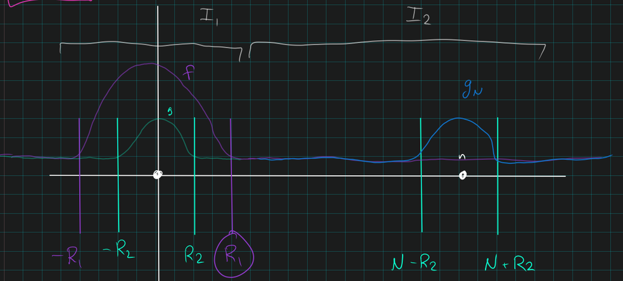

Shifting density

- Any integral $\int_a^b f$ can be written as ${\left\lVert {f} \right\rVert}_1 - O(\text{err})$.
- Bounding technique:
  $$\begin{align*}
  a-{\varepsilon}\leq b \leq a+{\varepsilon}\implies b=a
  .\end{align*}$$
- Fix ${\varepsilon}$.
- Using small tails for $f, g \in L^1$, choose $R_1, R_2 \gg 0$ so that
  $$\begin{align*}
  \int_{B_{R_1}(0)^c} {\left\lvert {f} \right\rvert} &< {\varepsilon}\\
  \int_{B_{R_2}(0)^c} {\left\lvert {g} \right\rvert} &< {\varepsilon}
  .\end{align*}$$
  - Note that this implies
    $$\begin{align*}
    \int_{-R_1}^{R_1} {\left\lvert {f} \right\rvert} &= {\left\lVert {f} \right\rVert}_1 - 2{\varepsilon}\\
    \int_{-R_2}^{R_2} {\left\lvert {g_N} \right\rvert} &= {\left\lVert {g_N} \right\rVert} - 2{\varepsilon}
    .\end{align*}$$
  - Also note that by translation invariance of the Lebesgue integral, ${\left\lVert {g} \right\rVert}_1 = {\left\lVert {g_N} \right\rVert}_1$.
- Now use $N$ to make the densities almost disjoint: choose $N\gg 1$ so that $N-R_2 > R_1$:

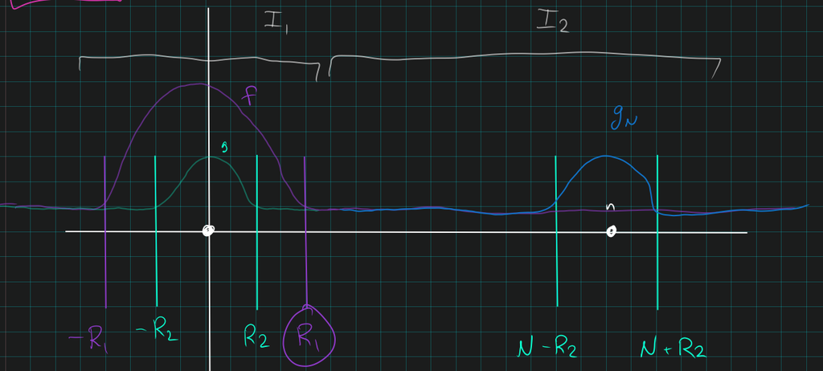

Shifting density

- Consider the change of variables $x\mapsto x-N$:
  $$\begin{align*}
  \int_{-R_2}^{R_2} {\left\lvert {g(x)} \right\rvert}\,dx
  = \int_{N-R_2} ^{N+R_2} {\left\lvert {g(x-N)} \right\rvert} \,dx
  \mathrel{\vcenter{:}}=\int_{N-R_2} ^{N+R_2} {\left\lvert {g_N(x)} \right\rvert} \,dx
  .\end{align*}
  Use this to conclude that
  \begin{align*}
  \int_{N-R_2}^{N+R_2} {\left\lvert {g_N} \right\rvert} = {\left\lVert {g_N} \right\rVert} - 2{\varepsilon}
  .\end{align*}$$
- Now split the integral in the problem statement at $R_1$:

$$\begin{align*}
{\left\lVert {f + g_N} \right\rVert}_1
= \int_{\mathbb{R}}{\left\lvert {f+g_N} \right\rvert}
= \int_{-\infty}^{R_1} {\left\lvert {f+ g_N} \right\rvert}
+ \int_{R_1}^{\infty} {\left\lvert {f+ g_N} \right\rvert}
\mathrel{\vcenter{:}}= I_1 + I_2
.\end{align*}$$

- **Idea**: from the picture,
  - On $I_1$, $f$ is big and $g_N$ is small
  - On $I_2$, $f$ is small and $g_N$ is big
- Casework: estimate $I_1, I_2$ separately, bounding from above and below.
- $I_1$ upper bound:
  $$\begin{align*}
  I_1
  &\mathrel{\vcenter{:}}=\int_{-\infty}^{R_1} {\left\lvert {f + g_N} \right\rvert} \\
  &\leq \int_{-\infty}^{R_1} {\left\lvert {f} \right\rvert} + {\left\lvert {g_N} \right\rvert} \\
  &= \int_{-\infty}^{R_1} {\left\lvert {f} \right\rvert} + \int_{-\infty}^{R_1} {\left\lvert {g_N} \right\rvert} \\
  &\leq \int_{-\infty}^{R_1} {\left\lvert {f} \right\rvert} + \int_{-\infty}^{\color{green} N - R_2} {\left\lvert {g_N} \right\rvert} && R_1 < N-R_2 \\
  &= {\left\lVert {f} \right\rVert}_1 - \int_{R_1}^{\infty} {\left\lvert {f} \right\rvert} + \int_{-\infty}^{N - R_2} {\left\lvert {g_N} \right\rvert} \\
  &\leq {\left\lVert {f} \right\rVert}_1 - \int_{R_1}^{\infty} {\left\lvert {f} \right\rvert} + {\varepsilon}\\
  &\leq {\left\lVert {f} \right\rVert}_1 + {\varepsilon}
  .\end{align*}$$
  - In the last step we’ve used that we’re subtracting off a positive number, so forgetting it only makes things larger.
  - We’ve also used monotonicity of the Lebesgue integral: if $A\leq B$, then $(c, A) \subseteq (c, B)$ and $\int_{c}^A {\left\lvert {f} \right\rvert} \leq \int_c^B {\left\lvert {f} \right\rvert}$ since ${\left\lvert {f} \right\rvert}$ is positive.
- $I_1$ lower bound:
  $$\begin{align*}
  I_1
  &\mathrel{\vcenter{:}}=\int_{-\infty}^{R_1} {\left\lvert {f + g_N} \right\rvert} \\
  &\geq \int_{-\infty}^{R_1} {\left\lvert {f} \right\rvert} - {\left\lvert {g_N} \right\rvert} \\
  &= \int_{-\infty}^{R_1} {\left\lvert {f} \right\rvert} - \int_{-\infty}^{R_1} {\left\lvert {g_N} \right\rvert} \\
  &\geq \int_{-\infty}^{R_1} {\left\lvert {f} \right\rvert} - \int_{-\infty}^{\color{green} N-R_2} {\left\lvert {g_N} \right\rvert} && R_1 < N-R_2 \\
  &= {\left\lVert {f} \right\rVert}_1 - \int_{R_1}^{ \infty } {\left\lvert {f} \right\rvert} - \int_{- \infty }^{N-R_2} {\left\lvert {g_N} \right\rvert} \\
  &\geq {\left\lVert {f} \right\rVert}_1 - {\varepsilon}- {\varepsilon}\\
  &= {\left\lVert {f} \right\rVert}_1 - 2{\varepsilon}
  .\end{align*}$$
  - Now we’ve used that the integral with $g_N$ comes in with a negative sign, so extending the range of integration only makes things *smaller*. We’ve also used the ${\varepsilon}$ bound on both $f$ and $g_N$ here, and both are tail estimates.
- Taken together we conclude
  $$\begin{align*}
  {\left\lVert {f} \right\rVert}_1 - 2{\varepsilon}
  \leq I_1
  \leq {\left\lVert {f} \right\rVert}_1 && {\varepsilon}\to 0 \implies I_1 = {\left\lVert {f} \right\rVert}_1
  .\end{align*}$$
- $I_2$ lower bound:
  $$\begin{align*}
  I_2
  &\mathrel{\vcenter{:}}=\int_{R_1}^{\infty} {\left\lvert {f + g_N} \right\rvert} \\
  &\leq \int_{R_1}^{\infty} {\left\lvert {f} \right\rvert} + \int_{R_1}^{\infty} {g_N} \\
  &\leq \int_{R_1}^{\infty} {\left\lvert {f} \right\rvert} + {\left\lVert {g_N} \right\rVert}_1 - \int_{-\infty}^{R_1} {\left\lvert {g_N} \right\rvert} \\
  &\leq {\varepsilon}+ {\left\lVert {g_N} \right\rVert}_1 - \int_{-\infty}^{R_1} {\left\lvert {g_N} \right\rvert} \\
  &\leq {\varepsilon}+ {\left\lVert {g_N} \right\rVert}_1 \\
  &= {\varepsilon}+ {\left\lVert {g} \right\rVert}_1
  .\end{align*}$$
  - Here we’ve again thrown away negative terms, only increasing the bound, and used the tail estimate on $f$.
- $I_2$ upper bound:

$$\begin{align*}
I_2
&\mathrel{\vcenter{:}}=\int_{R_1}^{\infty} {\left\lvert {f + g_N} \right\rvert} \\
&= \int_{R_1}^{\infty} {\left\lvert {g_N + f} \right\rvert} \\
&\geq \int_{R_1}^{\infty} {\left\lvert {g_N} \right\rvert} - \int_{R_1}^{\infty} {\left\lvert {f} \right\rvert} \\
&= {\left\lVert {g_N} \right\rVert} - \int_{-\infty}^{R_1} {\left\lvert {g_N} \right\rvert} - \int_{R_1}^{\infty} {\left\lvert {f} \right\rvert} \\
&\geq {\left\lVert {g_N} \right\rVert} - 2{\varepsilon}
.\end{align*}$$

- Here we’ve swapped the order under the absolute value, and used the tail estimates on both $g$ and $f$.
- Taken together:
  $$\begin{align*}
  {\left\lVert {g} \right\rVert}_1 - {\varepsilon}\leq I_2 \leq {\left\lVert {g} \right\rVert}_1 + 2{\varepsilon}
  .\end{align*}$$
- Note that we have two inequalities:
  $$\begin{align*}
  {\left\lVert {f} \right\rVert}_1 - 2{\varepsilon}&\leq \int_{-\infty}^{R_1} {\left\lvert {f -g_N} \right\rvert} \leq {\left\lVert {f} \right\rVert}_1 + {\varepsilon}\\
  {\left\lVert {g} \right\rVert}_1 - 2{\varepsilon}&\leq \int^{\infty}_{R_1} {\left\lvert {f -g_N} \right\rvert} \leq {\left\lVert {g} \right\rVert}_1 + {\varepsilon}
  .\end{align*}$$
- Add these to obtain
  $$\begin{align*}
  {\left\lVert {f} \right\rVert}_1 + {\left\lVert {g} \right\rVert}_1 - 4{\varepsilon}\leq I_1 + I_2 \mathrel{\vcenter{:}}={\left\lVert {f - g_N} \right\rVert}_1 \leq {\left\lVert {f} \right\rVert} + {\left\lVert {g} \right\rVert}_1 + 2{\varepsilon}
  .\end{align*}$$
- Check that as $N\to \infty$ as ${\varepsilon}\to 0$ to yield the result.

## 8.8 Fall 2020 # 4 $\work$

Prove that if $xf(x) \in L^1({\mathbb{R}})$, then
$$\begin{align*}
F(y) \mathrel{\vcenter{:}}=\int f(x) \cos(yx)\, dx
\end{align*}
defines a \(C^1\) function.$$

# 9 Fubini-Tonelli

## 9.1 Spring 2020 # 4 $\done$

Let $f, g\in L^1({\mathbb{R}})$. Argue that $H(x, y) \mathrel{\vcenter{:}}= f(y) g(x-y)$ defines a function in $L^1({\mathbb{R}}^2)$ and deduce from this fact that
$$\begin{align*}
(f\ast g)(x) \mathrel{\vcenter{:}}=\int_{\mathbb{R}}f(y) g(x-y) \,dy
\end{align*}
defines a function in \(L^1({\mathbb{R}})\) that satisfies
\begin{align*}
{\left\lVert {f\ast g} \right\rVert}_1 \leq {\left\lVert {f} \right\rVert}_1 {\left\lVert {g} \right\rVert}_1
.\end{align*}$$

Just do it! Sort out the justification afterward. Use Tonelli.

- Tonelli: non-negative and measurable yields measurability of slices and equality of iterated integrals
- Fubini: $f(x, y) \in L^1$ yields *integrable* slices and equality of iterated integrals
- F/T: apply Tonelli to ${\left\lvert {f} \right\rvert}$; if finite, $f\in L^1$ and apply Fubini to $f$
- See Folland’s Real Analysis II, p. 68 for a discussion of using Fubini *and* Tonelli.
- If these norms can be computed via iterated integrals, we have
  $$\begin{align*}
  {\left\lVert {f\ast g} \right\rVert}_1
  &\mathrel{\vcenter{:}}=\int_{\mathbb{R}}{\left\lvert {(f\ast g)(x)} \right\rvert} \,dx\\
  &\mathrel{\vcenter{:}}=\int_{\mathbb{R}}{\left\lvert {\int_{\mathbb{R}}H(x, y) \,dy} \right\rvert} \,dx\\
  &\mathrel{\vcenter{:}}=\int_{\mathbb{R}}{\left\lvert {\int_{\mathbb{R}}f(y)g(x-y) \,dy} \right\rvert} \,dx\\
  &\leq \int_{\mathbb{R}}\int_{\mathbb{R}}{\left\lvert {f(y) g(x-y)} \right\rvert} \,dx\,dy\\
  &\mathrel{\vcenter{:}}=\int_{\mathbb{R}}\int_{\mathbb{R}}{\left\lvert {H(x ,y)} \right\rvert}\,dx\,dy\\
  &\mathrel{\vcenter{:}}=\int_{{\mathbb{R}}^2} {\left\lvert {H} \right\rvert} \,d\mu_{{\mathbb{R}}^2} \\
  &\mathrel{\vcenter{:}}={\left\lVert {H} \right\rVert}_{L^1({\mathbb{R}}^2)}
  .\end{align*}
  So it suffices to show \({\left\lVert {H} \right\rVert}_1 < \infty\).$$
- A preliminary computation, the validity of which we will show afterward:
  $$\begin{align*}
  {\left\lVert {H} \right\rVert}_1
  &\mathrel{\vcenter{:}}={\left\lVert {H} \right\rVert}_{L^1({\mathbb{R}}^2)} \\
  &= \int _{\mathbb{R}}\qty{ \int_{\mathbb{R}}{\left\lvert {f(y)g(x-y)} \right\rvert} \, dy } \, dx && \text{Tonelli} \\
  &= \int _{\mathbb{R}}\qty{ \int_{\mathbb{R}}{\left\lvert {f(y)g(x-y)} \right\rvert} \, dx} \, dy && \text{Tonelli} \\
  &= \int _{\mathbb{R}}\qty{ \int_{\mathbb{R}}{\left\lvert {f(y)g(t)} \right\rvert} \, dt} \, dy && \text{setting } t=x-y, \,dt = - dx \\
  &= \int _{\mathbb{R}}\qty{ \int_{\mathbb{R}}{\left\lvert {f(y)} \right\rvert}\cdot {\left\lvert {g(t)} \right\rvert} \, dt}\, dy \\
  &= \int _{\mathbb{R}}{\left\lvert {f(y)} \right\rvert} \cdot \qty{ \int_{\mathbb{R}}{\left\lvert {g(t)} \right\rvert} \, dt}\, dy \\
  &\mathrel{\vcenter{:}}=\int _{\mathbb{R}}{\left\lvert {f(y)} \right\rvert} \cdot {\left\lVert {g} \right\rVert}_1 \,dy \\
  &= {\left\lVert {g} \right\rVert}_1 \int _{\mathbb{R}}{\left\lvert {f(y)} \right\rvert} \,dy &&\text{the norm is a constant} \\
  &\mathrel{\vcenter{:}}={\left\lVert {g} \right\rVert}_1 {\left\lVert {f} \right\rVert}_1 \\
  &< \infty && \text{by assumption}
  .\end{align*}$$
- We’ve used Tonelli twice: to equate the integral to the iterated integral, and to switch the order of integration, so it remains to show the hypothesis of Tonelli are fulfilled.

$H$ is measurable on ${\mathbb{R}}^2$:

- It suffices to show $\tilde f(x, y) \mathrel{\vcenter{:}}= f(y)$ and $\tilde g(x, y) \mathrel{\vcenter{:}}= g(x-y)$ are both measurable on ${\mathbb{R}}^2$.
  - Then use that products of measurable functions are measurable.
- $f \in L^1$ by assumption, and $L^1$ functions are measurable by definition.
- The function $(x, y) \mapsto g(x-y)$ is measurable on ${\mathbb{R}}^2$:
  - $g$ is measurable on ${\mathbb{R}}$ by assumption, so the cylinder function $G(x, y) \mathrel{\vcenter{:}}= g(x)$ on ${\mathbb{R}}^2$ is measurable (result from course).
  - Define a linear transformation
    $$\begin{align*}
    T \mathrel{\vcenter{:}}=
    \begin{bmatrix}
    1 & -1
    \\
    0 & 1
    \end{bmatrix}
    \in \operatorname{GL}_2({\mathbb{R}})
    && \implies \,\,\,
    T
    \begin{bmatrix}
    x
    \\
    y
    \end{bmatrix}
    =
    \begin{bmatrix}
    x-y
    \\
    y
    \end{bmatrix}
    ,\end{align*}
    and linear functions are measurable.$$
  - Write
    $$\begin{align*}
    \tilde g(x-y) \mathrel{\vcenter{:}}= G(x-y, y) \mathrel{\vcenter{:}}=(G\circ T)(x, y)
    ,\end{align*}
    and compositions of measurable functions are measurable.$$
- Apply **Tonelli** to ${\left\lvert {H} \right\rvert}$
  - $H$ measurable implies ${\left\lvert {H} \right\rvert}$ is measurable.
  - ${\left\lvert {H} \right\rvert}$ is non-negative.
  - So the iterated integrals are equal in the extended sense
  - The calculation shows the iterated integral is finite, so $\int {\left\lvert {H} \right\rvert}$ is finite and $H$ is thus integrable on ${\mathbb{R}}^2$.

> Note: Fubini is not needed, since we’re not calculating the actual integral, just showing $H$ is integrable.

## 9.2 Spring 2019 # 4 $\done$

Let $f$ be a non-negative function on ${\mathbb{R}}^n$ and $\mathcal A = \{(x, t) ∈ {\mathbb{R}}^n \times {\mathbb{R}}: 0 ≤ t ≤ f (x)\}$.

Prove the validity of the following two statements:

1. $f$ is a Lebesgue measurable function on ${\mathbb{R}}^n \iff \mathcal A$ is a Lebesgue measurable subset of ${\mathbb{R}}^{n+1}$
2. If $f$ is a Lebesgue measurable function on ${\mathbb{R}}^n$, then
   $$\begin{align*}
   m(\mathcal{A})=\int _{{\mathbb{R}}^{n}} f(x) d x=\int_{0}^{\infty} m\left(\left\{x \in {\mathbb{R}}^{n}: f(x) \geq t\right\}\right) dt
   \end{align*}$$
- See Stein and Shakarchi p.82 corollary 3.3.
- Tonelli
- Important trick! $\left\{{(x, t) {~\mathrel{\Big|}~}0\leq t \leq f(x)}\right\} = \left\{{ f(x) \geq t}\right\} \cap\left\{{ t\geq 0 }\right\}$

$\implies$:

- Suppose $f:{\mathbb{R}}^n\to {\mathbb{R}}$ is a measurable function.
- Rewrite $A$:
  $$\begin{align*}
  A
  &= \left\{{ (x, t) \in {\mathbb{R}}^d \times{\mathbb{R}}{~\mathrel{\Big|}~}0\leq t \leq f(x) }\right\} \\
  &= \left\{{ (x, t) \in {\mathbb{R}}^d \times{\mathbb{R}}{~\mathrel{\Big|}~}0 \leq t < \infty }\right\}
  \cap\left\{{ (x, t) \in {\mathbb{R}}^d\times{\mathbb{R}}{~\mathrel{\Big|}~}t\leq f(x) }\right\} \\
  &= \qty{ {\mathbb{R}}^d \times[0, \infty) }
  \cap\left\{{ (x, t) \in {\mathbb{R}}^d\times{\mathbb{R}}{~\mathrel{\Big|}~}f(x) -t \geq 0 }\right\} \\
  &\mathrel{\vcenter{:}}=\qty{ {\mathbb{R}}^d \times[0, \infty) } \cap H^{-1}\qty{[0, \infty)}
  ,\end{align*}
  where we define
  \begin{align*}
  H: {\mathbb{R}}^d \times{\mathbb{R}}&\to {\mathbb{R}}\\
  (x, t) &\mapsto f(x) - t
  .\end{align*}
  Note: this is “clearly” measurable!$$
- If we can show both sets are measurable, we’re done, since $\sigma{\hbox{-}}$algebras are closed under countable intersections.
- The first set is measurable since it is a Borel set in ${\mathbb{R}}^{d+1}$.
- For the same reason, it suffices to show $H$ is a measurable function.
- Define cylinder functions
  $$\begin{align*}
  F: {\mathbb{R}}^d \times{\mathbb{R}}&\to {\mathbb{R}}\\
  (x, t) &\mapsto f(x)
  \end{align*}
  and
  \begin{align*}
  G: {\mathbb{R}}^d \times{\mathbb{R}}&\to {\mathbb{R}}\\
  (x, t) &\mapsto t
  \end{align*}
  \(F\) is a cylinder of \(f\), and since \(f\) is measurable by assumption, \(F\) is measurable.
  \(G\) is a cylinder on the identity for \({\mathbb{R}}\), which is measurable, so \(G\) is measurable.$$
- Define
  $$\begin{align*}
  H: {\mathbb{R}}^d &\to {\mathbb{R}}\\
  (x, t) &\mapsto F(x, t) - G(x, t) \mathrel{\vcenter{:}}= f(x) - t
  ,\end{align*}
  which are linear combinations of measurable functions and thus measurable.$$

$\impliedby$:

- Suppose ${\mathcal{A}}$ is a measurable set.
- A corollary of Tonelli applied to $\chi_X$: if $E$ is measurable, then for a.e. $t$ the following slice is measurable:
  $$\begin{align*}
  {\mathcal{A}}_t \mathrel{\vcenter{:}}=\left\{{ x \in {\mathbb{R}}^d {~\mathrel{\Big|}~}(x,t) \in {\mathcal{A}}}\right\}
  &= \left\{{x\in {\mathbb{R}}^d {~\mathrel{\Big|}~}f(x) \geq t \geq 0}\right\} \\
  &= f^{-1}\qty{[t, \infty)}
  .\end{align*}$$
  - But maybe this isn’t enough, because we need $f^{-1}\qty{[\alpha, \infty)}$ for *all* $\alpha$
- But the other slice is also measurable for a.e. $x$:
  $$\begin{align*}
  {\mathcal{A}}_x
  &\mathrel{\vcenter{:}}=\left\{{ t\in {\mathbb{R}}{~\mathrel{\Big|}~}(x, t) \in {\mathcal{A}}}\right\} \\
  &= \left\{{ t\in {\mathbb{R}}{~\mathrel{\Big|}~}0 \leq t \leq f(x) }\right\} \\
  &= \left\{{ t\in {\mathbb{R}}{~\mathrel{\Big|}~}t\in [0, f(x)] }\right\} \\
  &= [0, f(x)]
  .\end{align*}$$
- Moreover the function $x\mapsto m({\mathcal{A}}_x)$ is a measurable function of $x$
- Now note $m({\mathcal{A}}_x) = f(x) - 0 = f(x)$, so $f$ must be measurable.
- Writing down what the slices are
  $$\begin{align*}
  \mathcal{A} &= \left\{{(x, t) \in {\mathbb{R}}^n\times{\mathbb{R}}{~\mathrel{\Big|}~}0 \leq t \leq f(x)}\right\}
  \\
  \mathcal{A}_t &= \left\{{x
  \in {\mathbb{R}}^n {~\mathrel{\Big|}~}t\leq f(x) }\right\}
  .\end{align*}$$
- Then
  $$\begin{align*}
  \int_{{\mathbb{R}}^n} f(x) ~dx
  &= \int_{{\mathbb{R}}^n} \int_0^{f(x)} 1 ~dt~dx \\
  &= \int_{{\mathbb{R}}^n} \int_{0}^\infty \chi_\mathcal{A} ~dt~dx \\
  &\overset{F.T.}= \int_{0}^\infty \int_{{\mathbb{R}}^n} \chi_\mathcal{A} ~dx~dt\\
  &= \int_0^\infty m(\mathcal{A}_t) ~dt
  ,\end{align*}
  where we just use that \(\int \int \chi_\mathcal{A} = m(\mathcal{A})$$
- By Tonelli, all of these integrals are equal.
  - This is justified because $f$ was assumed measurable on ${\mathbb{R}}^n$, thus by (a) $\mathcal{A}$ is a measurable set and thus $\chi_A$ is a measurable function on ${\mathbb{R}}^n\times{\mathbb{R}}$.

## 9.3 Fall 2018 # 5 $\done$

Let $f \geq 0$ be a measurable function on ${\mathbb{R}}$. Show that
$$\begin{align*}
\int _{{\mathbb{R}}} f = \int _{0}^{\infty} m(\{x: f(x)>t\}) dt
\end{align*}$$

- Claim: If $E\subseteq {\mathbb{R}}^a \times{\mathbb{R}}^b$ is a measurable set, then for almost every $y\in {\mathbb{R}}^b$, the slice $E^y$ is measurable and
  $$\begin{align*}
  m(E) = \int_{{\mathbb{R}}^b} m(E^y) \,dy
  .\end{align*}
  Set \(g = \chi_E\), which is non-negative and measurable, so apply Tonelli.
  Conclude that \(g^y = \chi_{E^y}\) is measurable, the function \(y\mapsto \int g^y(x)\, dx\) is measurable, and \(\int \int g^y(x)\,dx \,dy = \int g\).
  But \(\int g = m(E)\) and \(\int\int g^y(x) \,dx\,dy = \int m(E^y)\,dy\).$$

> Note: $f$ is a function ${\mathbb{R}}\to {\mathbb{R}}$ in the original problem, but here I’ve assumed $f:{\mathbb{R}}^n\to {\mathbb{R}}$.
- Since $f\geq 0$, set
  $$\begin{align*}
  E\mathrel{\vcenter{:}}=\left\{{(x, t) \in {\mathbb{R}}^{n} \times{\mathbb{R}}{~\mathrel{\Big|}~}f(x) > t}\right\}
  = \left\{{(x, t) \in {\mathbb{R}}^n \times{\mathbb{R}}{~\mathrel{\Big|}~}0 \leq t < f(x)}\right\}
  .\end{align*}$$
- Claim: since $f$ is measurable, $E$ is measurable and thus $m(E)$ makes sense.
  - Since $f$ is measurable, $F(x, t) \mathrel{\vcenter{:}}= t - f(x)$ is measurable on ${\mathbb{R}}^n \times{\mathbb{R}}$.
  - Then write $E = \left\{{F < 0}\right\} \cap\left\{{t\geq 0}\right\}$ as an intersection of measurable sets.
- We have slices
  $$\begin{align*}
  E^t &\mathrel{\vcenter{:}}=\left\{{x\in {\mathbb{R}}^n {~\mathrel{\Big|}~}(x, t) \in E}\right\} = \left\{{x\in {\mathbb{R}}^n {~\mathrel{\Big|}~}0 \leq t < f(x)}\right\} \\
  E^x &\mathrel{\vcenter{:}}=\left\{{t\in {\mathbb{R}}{~\mathrel{\Big|}~}(x, t) \in E}\right\} = \left\{{t\in {\mathbb{R}}{~\mathrel{\Big|}~}0 \leq t \leq f(x)}\right\} = [0, f(x)]
  .\end{align*}$$
  - $E_t$ is precisely the set that appears in the original RHS integrand.
  - $m(E^x) = f(x)$.
- Claim: $\chi_E$ satisfies the conditions of Tonelli, and thus $m(E) = \int \chi_E$ is equal to any iterated integral.
  - Non-negative: clear since $0\leq \chi_E \leq 1$
  - Measurable: characteristic functions of measurable sets are measurable.
- Conclude:
  1. For almost every $x$, $E^x$ is a measurable set, $x\mapsto m(E^x)$ is a measurable function, and $m(E) = \int_{{\mathbb{R}}^n} m(E^x) \, dx$
  2. For almost every $t$, $E^t$ is a measurable set, $t\mapsto m(E^t)$ is a measurable function, and $m(E) = \int_{{\mathbb{R}}} m(E^t) \, dt$
- On one hand,
  $$\begin{align*}
  m(E)
  &= \int_{{\mathbb{R}}^{n+1}} \chi_E(x, t) \\
  &= \int_{{\mathbb{R}}} \int_{{\mathbb{R}}^n} \chi_E(x, t) \,dt \,dx \quad\text{by Tonelli}\\
  &= \int_{{\mathbb{R}}^n} m(E^x) \,dx \quad\text{first conclusion}\\
  &= \int_{{\mathbb{R}}^n} f(x) \,dx
  .\end{align*}$$
- On the other hand,
  $$\begin{align*}
  m(E)
  &= \int_{{\mathbb{R}}^{n+1}} \chi_E(x, t) \\
  &= \int_{\mathbb{R}}\int_{{\mathbb{R}}^n} \chi_E(x, t) \, dx \,dt \quad\text{by Tonelli} \\
  &= \int_{\mathbb{R}}m(E^t) \,dt \quad\text{second conclusion}
  .\end{align*}$$
- Thus
  $$\begin{align*}
  \int_{{\mathbb{R}}^n} f \,dx = m(E) = \int_{\mathbb{R}}m(E^t) \,dt = \int_{\mathbb{R}}m\qty{\left\{{x{~\mathrel{\Big|}~}f(x) > t}\right\}}
  .\end{align*}$$

## 9.4 Fall 2015 # 5 $\work$

Let $f, g \in L^1({\mathbb{R}})$ be Borel measurable.

1. Show that
- The function
  $$\begin{align*}F(x, y) \mathrel{\vcenter{:}}= f(x-y) g(y)\end{align*}
  is Borel measurable on \({\mathbb{R}}^2\), and$$
- For almost every $y\in {\mathbb{R}}$,
  $$\begin{align*}F_y(x) \mathrel{\vcenter{:}}= f(x-y)g(y)\end{align*}
  is integrable with respect to \(y\).$$
2. Show that $f\ast g \in L^1({\mathbb{R}})$ and
   $$\begin{align*}
   \|f * g\|_{1} \leq \|f\|_{1} \|g\|_{1}
   \end{align*}$$

## 9.5 Spring 2014 # 5 $\work$

Let $f, g \in L^1([0, 1])$ and for all $x\in [0, 1]$ define
$$\begin{align*}
F(x) \mathrel{\vcenter{:}}=\int _{0}^{x} f(y) \, dy
{\quad \operatorname{and} \quad}
G(x)\mathrel{\vcenter{:}}=\int _{0}^{x} g(y) \, dy.
\end{align*}$$

Prove that
$$\begin{align*}
\int _{0}^{1} F(x) g(x) \, dx =
F(1) G(1) - \int _{0}^{1} f(x) G(x) \, dx
\end{align*}$$

## 9.6 Spring 2021 # 6

This problem may be much harder than expected. Recommended skip.

Let $f: {\mathbb{R}}\times{\mathbb{R}}\to {\mathbb{R}}$ be a measurable function and for $x\in {\mathbb{R}}$ define the set
$$\begin{align*}
E_x \mathrel{\vcenter{:}}=\left\{{ y\in {\mathbb{R}}{~\mathrel{\Big|}~}\mu\qty{ z\in {\mathbb{R}}{~\mathrel{\Big|}~}f(x,z) = f(x, y) } > 0 }\right\}
.\end{align*}
Show that the following set is a measurable subset of \({\mathbb{R}}\times{\mathbb{R}}\):
\begin{align*}
E \mathrel{\vcenter{:}}=\displaystyle\bigcup_{x\in {\mathbb{R}}} \left\{{ x }\right\} \times E_x
.\end{align*}$$

> Hint: consider the measurable function $h(x,y,z) \mathrel{\vcenter{:}}= f(x, y) - f(x, z)$.

# 10 $L^2$ and Fourier Analysis

## 10.1 Spring 2020 # 6 $\done$

### 10.1.1 a

Show that
$$\begin{align*}
L^2([0, 1]) \subseteq L^1([0, 1]) {\quad \operatorname{and} \quad} \ell^1({\mathbb{Z}}) \subseteq \ell^2({\mathbb{Z}})
.\end{align*}$$

### 10.1.2 b

For $f\in L^1([0, 1])$ define
$$\begin{align*}
\widehat{f}(n) \mathrel{\vcenter{:}}=\int _0^1 f(x) e^{-2\pi i n x} \, dx
.\end{align*}$$

Prove that if $f\in L^1([0, 1])$ and $\left\{{\widehat{f}(n)}\right\} \in \ell^1({\mathbb{Z}})$ then
$$\begin{align*}
S_N f(x) \mathrel{\vcenter{:}}=\sum_{{\left\lvert {n} \right\rvert} \leq N} \widehat{f} (n) e^{2 \pi i n x}
.\end{align*}
converges uniformly on \([0, 1]\) to a continuous function \(g\) such that \(g = f\) almost everywhere.$$

> Hint: One approach is to argue that if $f\in L^1([0, 1])$ with $\left\{{\widehat{f} (n)}\right\} \in \ell^1({\mathbb{Z}})$ then $f\in L^2([0, 1])$.
- For $e_n(x) \mathrel{\vcenter{:}}= e^{2\pi i n x}$, the set $\left\{{e_n}\right\}$ is an orthonormal basis for $L^2([0, 1])$.
- For any orthonormal sequence in a Hilbert space, we have Bessel’s inequality:
  $$\begin{align*}
  \sum_{k=1}^{\infty}\left|\left\langle x, e_{k}\right\rangle\right|^{2} \leq\|x\|^{2}
  .\end{align*}$$
- When $\left\{{e_n}\right\}$ is a basis, the above is an *equality* (Parseval)
- Arguing uniform convergence: since $\left\{{\widehat{f}(n)}\right\} \in \ell^1({\mathbb{Z}})$, we should be able to apply the $M$ test.

### 10.1.3 a

Claim: $\ell^1({\mathbb{Z}}) \subseteq \ell^2({\mathbb{Z}})$.

- Set $\mathbf{c} = \left\{{c_k {~\mathrel{\Big|}~}k\in {\mathbb{Z}}}\right\} \in \ell^1({\mathbb{Z}})$.
- It suffices to show that if $\sum_{k\in {\mathbb{Z}}} {\left\lvert {c_k} \right\rvert} < \infty$ then $\sum_{k\in {\mathbb{Z}}} {\left\lvert {c_k} \right\rvert}^2 < \infty$.
- Let $S = \left\{{c_k {~\mathrel{\Big|}~}{\left\lvert {c_k} \right\rvert} \leq 1}\right\}$, then $c_k \in S \implies {\left\lvert {c_k} \right\rvert}^2 \leq {\left\lvert {c_k} \right\rvert}$
- Claim: $S^c$ can only contain finitely many elements, all of which are finite.
  - If not, either $S^c \mathrel{\vcenter{:}}=\left\{{c_j}\right\}_{j=1}^\infty$ is infinite with every ${\left\lvert {c_j} \right\rvert} > 1$, which forces
    $$\begin{align*}\sum_{c_k\in S^c} {\left\lvert {c_k} \right\rvert} = \sum_{j=1}^\infty {\left\lvert {c_j} \right\rvert} > \sum_{j=1}^\infty 1 = \infty.\end{align*}$$
  - If any $c_j = \infty$, then $\sum_{k\in {\mathbb{Z}}} {\left\lvert {c_k} \right\rvert} \geq c_j = \infty$.
- So $S^c$ is a finite set of finite integers, let $N = \max \left\{{{\left\lvert {c_j} \right\rvert}^2 {~\mathrel{\Big|}~}c_j \in S^c}\right\} < \infty$.
- Rewrite the sum
  $$\begin{align*}
  \sum_{k\in {\mathbb{Z}}} {\left\lvert {c_k} \right\rvert}^2
  &= \sum_{c_k\in S} {\left\lvert {c_k} \right\rvert}^2 + \sum_{c_k \in S^c} {\left\lvert {c_k} \right\rvert}^2 \\
  &\leq \sum_{c_k\in S} {\left\lvert {c_k} \right\rvert} + \sum_{c_k \in S^c} {\left\lvert {c_k} \right\rvert}^2 \\
  &\leq \sum_{k\in {\mathbb{Z}}} {\left\lvert {c_k} \right\rvert} + \sum_{c_k \in S^c} {\left\lvert {c_k} \right\rvert}^2 \quad\text{since the ${\left\lvert {c_k} \right\rvert}$ are all positive} \\
  &= {\left\lVert {\mathbf{c}} \right\rVert}_{\ell^1} + \sum_{c_k \in S^c} {\left\lvert {c_k} \right\rvert}^2 \\
  &\leq {\left\lVert {\mathbf{c}} \right\rVert}_{\ell^1} + {\left\lvert {S^c} \right\rvert}\cdot N \\
  &< \infty
  .\end{align*}$$

Claim: $L^2([0, 1]) \subseteq L^1([0, 1])$.

- It suffices to show that $\int {\left\lvert {f} \right\rvert}^2 < \infty \implies \int {\left\lvert {f} \right\rvert} < \infty$.
- Define $S = \left\{{x\in [0, 1] {~\mathrel{\Big|}~}{\left\lvert {f(x)} \right\rvert} \leq 1}\right\}$, then $x\in S^c \implies {\left\lvert {f(x)} \right\rvert}^2 \geq {\left\lvert {f(x)} \right\rvert}$.
- Break up the integral:
  $$\begin{align*}
  \int_{\mathbb{R}}{\left\lvert {f} \right\rvert}
  &= \int_S {\left\lvert {f} \right\rvert} + \int_{S^c} {\left\lvert {f} \right\rvert} \\
  &\leq \int_S {\left\lvert {f} \right\rvert} + \int_{S^c} {\left\lvert {f} \right\rvert}^2 \\
  &\leq \int_S {\left\lvert {f} \right\rvert} + {\left\lVert {f} \right\rVert}_2 \\
  &\leq \sup_{x\in S}\left\{{{\left\lvert {f(x)} \right\rvert}}\right\} \cdot \mu(S) + {\left\lVert {f} \right\rVert}_2 \\
  &= 1 \cdot \mu(S) + {\left\lVert {f} \right\rVert}_2 \quad\text{by definition of } S\\
  &\leq 1 \cdot \mu([0, 1]) + {\left\lVert {f} \right\rVert}_2 \quad\text{since } S\subseteq [0, 1] \\
  &= 1 + {\left\lVert {f} \right\rVert}_2 \\
  &< \infty
  .\end{align*}$$

> Note: this proof shows $L^2(X) \subseteq L^1(X)$ whenever $\mu(X) < \infty$.

## 10.2 Fall 2017 # 5 $\done$

Let $\phi$ be a compactly supported smooth function that vanishes outside of an interval $[-N, N]$ such that $\int _{{\mathbb{R}}} \phi(x) \, dx = 1$.

For $f\in L^1({\mathbb{R}})$, define
$$\begin{align*}
K_{j}(x) \mathrel{\vcenter{:}}= j \phi(j x),
\qquad
f \ast K_{j}(x) \mathrel{\vcenter{:}}=\int_{{\mathbb{R}}} f(x-y) K_{j}(y) \, dy
\end{align*}
and prove the following:$$

1. Each $f\ast K_j$ is smooth and compactly supported.
2. $$\begin{align*}
   \lim _{j \to \infty} {\left\lVert {f * K_{j}-f} \right\rVert}_{1} = 0
   \end{align*}$$

> Hint:
> $$\begin{align*}
> \lim _{y \to 0} \int _{{\mathbb{R}}} |f(x-y)-f(x)| dy = 0
> \end{align*}$$
- ?

### 10.2.1 a

**Lemma:** If $\phi \in C_c^1$, then $(f \ast \phi)' = f \ast \phi'$ almost everywhere.

*Silly Proof:*

$$\begin{align*}
\mathcal{F}(
(f \ast \phi)'
)
&= 2\pi i \xi ~\mathcal{F}(f\ast \phi) \\
&= 2\pi i \xi ~ \mathcal{F}(f) ~ \mathcal{F}(\phi) \\
&= \mathcal{F}(f) \cdot \left( 2\pi i \xi ~\mathcal{F}(\phi)\right) \\
&= \mathcal{F}(f) \cdot \mathcal{F}(\phi') \\
&= \mathcal{F}(f\ast \phi')
.\end{align*}$$

*Actual proof*:

$$\begin{align*}
(f\ast \phi)'(x)
&= (\phi\ast f)'(x) \\
&= \lim_{h\to 0} \frac{(\phi\ast f)'(x+h) - (\phi\ast f)'(x)}{h} \\
&= \lim_{h\to 0} \int \frac{\phi(x + h - y) - \phi(x - y)}{h} f(y) \\
&\overset{DCT}= \int \lim_{h\to 0} \frac{\phi(x + h - y) - \phi(x - y)}{h} f(y) \\
&= \int \phi'(x-y) f(y) \\
&= (\phi' \ast f)(x) \\
&= (f \ast \phi')(x)
.\end{align*}$$

To see that the DCT is justified, we can apply the MVT on the interval $[0, h]$ to $f$ to obtain

$$\begin{align*}
\frac{\phi(x + h - y) - \phi(x - y)}{h}
&= \phi'(c) \quad c\in [0, h]
,\end{align*}$$

and since $\phi'$ is continuous and compactly supported, $\phi'$ is bounded by some $M < \infty$ by the extreme value theorem and thus
$$\begin{align*}
\int {\left\lvert {\frac{\phi(x + h - y) - \phi(x - y)}{h} f(y)} \right\rvert}
&= \int {\left\lvert {\phi'(c) f(y)} \right\rvert} \\
&\leq \int {\left\lvert {M} \right\rvert}{\left\lvert {f} \right\rvert} \\
&= {\left\lvert {M} \right\rvert} \int {\left\lvert {f} \right\rvert} < \infty
,\end{align*}$$

since $f\in L^1$ by assumption, so we can take $g\mathrel{\vcenter{:}}={\left\lvert {M} \right\rvert} {\left\lvert {f} \right\rvert}$ as the dominating function.

Applying this theorem infinitely many times shows that $f\ast \phi$ is smooth.

To see that $f\ast \phi$ is compactly supported, approximate $f$ by a *continuous* compactly supported function $h$, so ${\left\lVert {h - f} \right\rVert}_1 \overset{L^1}\to 0$.

Now let $g_x(y) = \phi(x-y)$, and note that $\mathrm{supp}(g) = x - \mathrm{supp}(\phi)$ which is still compact.

But since $\mathrm{supp}(h)$ is bounded, there is some $N$ such that
$$\begin{align*}
{\left\lvert {x} \right\rvert} > N \implies A_x\mathrel{\vcenter{:}}=\mathrm{supp}(h) \cap\mathrm{supp}(g_x) = \emptyset
\end{align*}$$

and thus
$$\begin{align*}
(h\ast \phi)(x)
&= \int_{\mathbb{R}}\phi(x-y) h(y)~dy \\
&= \int_{A_x} g_x(y) h(y) \\
&= 0
,\end{align*}$$

so $\left\{{x {~\mathrel{\Big|}~}f\ast g(x) = 0}\right\}$ is open, and its complement is closed and bounded and thus compact.

### 10.2.2 b

$$\begin{align*}
{\left\lVert {f\ast K_j - f} \right\rVert}_1
&= \int {\left\lvert {\int f(x-y) K_j(y) ~dy - f(x)} \right\rvert}~dx \\
&= \int {\left\lvert {\int f(x-y) K_j(y) ~dy - \int f(x) K_j(y) ~ dy} \right\rvert}~dx \\
&= \int {\left\lvert {\int ( f(x-y) - f(x) ) K_j(y) ~dy } \right\rvert} ~dx \\
&\leq \int \int {\left\lvert {(f(x-y) - f(x))} \right\rvert} \cdot {\left\lvert {K_j(y)} \right\rvert} ~ dy~dx \\
&\overset{FT}= \int \int {\left\lvert {(f(x-y) - f(x))} \right\rvert} \cdot {\left\lvert {K_j(y)} \right\rvert} \mathbf{~ dx~dy}\\
&= \int {\left\lvert {K_j(y)} \right\rvert} \left( \int {\left\lvert {(f(x-y) - f(x))} \right\rvert} ~ dx\right) ~dy \\
&= \int {\left\lvert {K_j(y)} \right\rvert} \cdot {\left\lVert {f - \tau_y f} \right\rVert}_1 ~dy
.\end{align*}$$

We now split the integral up into pieces.

1. Chose $\delta$ small enough such that ${\left\lvert {y} \right\rvert} < \delta \implies {\left\lVert {f - \tau_y f} \right\rVert}_1 < \varepsilon$ by continuity of translation in $L^1$, and
2. Since $\phi$ is compactly supported, choose $J$ large enough such that
   $$\begin{align*}
   j > J \implies \int_{{\left\lvert {y} \right\rvert} \geq \delta} {\left\lvert {K_j(y)} \right\rvert} ~dy
   = \int_{{\left\lvert {y} \right\rvert} \geq \delta} {\left\lvert {j\phi(jy)} \right\rvert} = 0
   \end{align*}$$

Then
$$\begin{align*}
{\left\lVert {f\ast K_j - f} \right\rVert}_1
&\leq
\int {\left\lvert {K_j(y)} \right\rvert} \cdot {\left\lVert {f - \tau_y f} \right\rVert}_1 ~dy \\
&= \int_{{\left\lvert {y} \right\rvert} < \delta} {\left\lvert {K_j(y)} \right\rvert} \cdot {\left\lVert {f - \tau_y f} \right\rVert}_1 ~dy
+ \int_{{\left\lvert {y} \right\rvert} \geq \delta} {\left\lvert {K_j(y)} \right\rvert} \cdot {\left\lVert {f - \tau_y f} \right\rVert}_1 ~dy \\
&= \varepsilon \int_{{\left\lvert {y} \right\rvert} \geq \delta} {\left\lvert {K_j(y)} \right\rvert} + 0 \\
&\leq \varepsilon(1) \to 0
.\end{align*}$$

## 10.3 Spring 2017 # 5 $\work$

Let $f, g \in L^2({\mathbb{R}})$. Prove that the formula
$$\begin{align*}
h(x) \mathrel{\vcenter{:}}=\int _{-\infty}^{\infty} f(t) g(x-t) \, dt
\end{align*}
defines a uniformly continuous function \(h\) on \({\mathbb{R}}\).$$

## 10.4 Spring 2015 # 6 $\work$

Let $f \in L^1({\mathbb{R}})$ and $g$ be a bounded measurable function on ${\mathbb{R}}$.

1. Show that the convolution $f\ast g$ is well-defined, bounded, and uniformly continuous on ${\mathbb{R}}$.
2. Prove that one further assumes that $g \in C^1({\mathbb{R}})$ with bounded derivative, then $f\ast g \in C^1({\mathbb{R}})$ and
   $$\begin{align*}
   \frac{d}{d x}(f * g)=f *\left(\frac{d}{d x} g\right)
   \end{align*}$$

## 10.5 Fall 2014 # 5 $\work$

1. Let $f \in C_c^0({\mathbb{R}}^n)$, and show
   $$\begin{align*}
   \lim _{t \to 0} \int_{{\mathbb{R}}^n} |f(x+t) - f(x)| \, dx = 0
   .\end{align*}$$
2. Extend the above result to $f\in L^1({\mathbb{R}}^n)$ and show that
   $$\begin{align*}
   f\in L^1({\mathbb{R}}^n), \quad g\in L^\infty({\mathbb{R}}^n) \quad
   \implies f \ast g \text{ is bounded and uniformly continuous. }
   \end{align*}$$

## 10.6 Fall 2020 # 5

Suppose $\phi\in L^1({\mathbb{R}})$ with
$$\begin{align*}
\int \phi(x) \, dx = \alpha
.\end{align*}
For each \(\delta > 0\) and \(f\in L^1({\mathbb{R}})\), define
\begin{align*}
A_\delta f(x) \mathrel{\vcenter{:}}=\int f(x-y) \delta^{-1} \phi\qty{\delta^{-1} y}\, dy
.\end{align*}$$

1. Prove that for all $\delta > 0$,
   $$\begin{align*}
   {\left\lVert {A_\delta f} \right\rVert}_1 \leq {\left\lVert {\phi} \right\rVert}_1 {\left\lVert {f} \right\rVert}_1
   .\end{align*}$$
2. Prove that
   $$\begin{align*}
   A_\delta f \to \alpha f \text{ in } L^1({\mathbb{R}}) {\quad \operatorname{as} \quad} \delta\to 0^+
   .\end{align*}$$

> Hint: you may use without proof the fact that for all $f\in L^1({\mathbb{R}})$,
> $$\begin{align*}
> \lim_{y\to 0} \int_{\mathbb{R}}{\left\lvert {f(x-y) - f(x)} \right\rvert}\, dx = 0
> .\end{align*}$$

# 11 Functional Analysis: General

## 11.1 Fall 2019 # 4 $\done$

Let $\{u_n\}_{n=1}^∞$ be an orthonormal sequence in a Hilbert space $\mathcal{H}$.

1. Prove that for every $x ∈ \mathcal H$ one has
   $$\begin{align*}
   \displaystyle\sum_{n=1}^{\infty}\left|\left\langle x, u_{n}\right\rangle\right|^{2} \leq\|x\|^{2}
   \end{align*}$$
2. Prove that for any sequence $\{a_n\}_{n=1}^\infty \in \ell^2({\mathbb{N}})$ there exists an element $x\in\mathcal H$ such that
   $$\begin{align*}
   a_n = {\left\langle {x},~{u_n} \right\rangle} \text{ for all } n\in {\mathbb{N}}
   \end{align*}
   and
   \begin{align*}
   {\left\lVert {x} \right\rVert}^2 = \sum_{n=1}^{\infty}\left|\left\langle x, u_{n}\right\rangle\right|^{2}
   \end{align*}$$
- Bessel’s Inequality
- Pythagoras
- Surjectivity of the Riesz map
- Parseval’s Identity
- Trick – remember to write out finite sum $S_N$, and consider ${\left\lVert {x - S_N} \right\rVert}$.
- Equivalently, we can show
  $$\begin{align*}
  {\left\lVert {x} \right\rVert}^2 - \sum_{n=1}^\infty {\left\lvert { {\left\langle {x},~{u_n} \right\rangle} } \right\rvert}^2 \geq 0
  .\end{align*}$$
- Claim: the LHS is the norm of an element in $H$, and thus non-negative. More precisely, set $S_N\mathrel{\vcenter{:}}=\sum_{n=1}^N {\left\langle {x},~{u_n} \right\rangle}u_n$, then the above is equal to
  $$\begin{align*}
  {\left\lVert {x - \lim_{N\to\infty} S_N} \right\rVert}^2
  .\end{align*}
  Note that if this is true, we’re done.$$
- To see this, expand the norm in terms of inner products:
  $$\begin{align*}
  {\left\lVert {x - S_N} \right\rVert}^2
  &= {\left\langle {x-S_N},~{x-S_N} \right\rangle} \\
  &= {\left\langle {x},~{x} \right\rangle} - {\left\langle {x},~{S_N} \right\rangle} - {\left\langle {S_N},~{x} \right\rangle} + {\left\langle {S_N},~{S_N} \right\rangle} \\
  &= {\left\lVert {x} \right\rVert}^2 + {\left\lVert {S_N} \right\rVert}^2 - \qty{{\left\langle {x},~{S_N} \right\rangle} + {\overline{{{\left\langle {x},~{S_N} \right\rangle}}}} } \\
  &= {\left\lVert {x} \right\rVert}^2 + {\left\lVert {S_N} \right\rVert}^2 - 2\Re\qty{{\left\langle {x},~{S_N} \right\rangle} } \\
  &= {\left\lVert {x} \right\rVert}^2 + {\left\lVert {S_N} \right\rVert}^2 - 2\Re\qty{ {\left\langle {x},~{\sum_{n=1}^N {\left\langle {x},~{u_n} \right\rangle} u_n } \right\rangle} } \\
  &= {\left\lVert {x} \right\rVert}^2 + {\left\lVert {S_N} \right\rVert}^2 - 2\Re\qty{ \sum_{n=1}^N {\left\langle {x},~{{\left\langle {x},~{u_n} \right\rangle} u_n } \right\rangle} } \\
  &= {\left\lVert {x} \right\rVert}^2 + {\left\lVert {S_N} \right\rVert}^2 - 2\Re\qty{ \sum_{n=1}^N {\overline{{{\left\langle {x},~{u_n} \right\rangle} }}} {\left\langle {x},~{u_n } \right\rangle} } \\
  &= {\left\lVert {x} \right\rVert}^2 + {\left\lVert {S_N} \right\rVert}^2 - 2\Re \sum_{n=1}^N {\left\lvert {{\left\langle {x},~{u_n} \right\rangle} } \right\rvert}^2 \\
  &= {\left\lVert {x} \right\rVert}^2 + {\left\lVert {S_N} \right\rVert}^2 - 2\sum_{n=1}^N {\left\lvert {{\left\langle {x},~{u_n} \right\rangle} } \right\rvert}^2 \\
  &= {\left\lVert {x} \right\rVert}^2 + {\left\lVert {\sum_{n=1}^N {\left\langle {x},~{u_n} \right\rangle} u_n} \right\rVert}^2 - 2\sum_{n=1}^N {\left\lvert {{\left\langle {x},~{u_n} \right\rangle} } \right\rvert}^2 \\
  &= {\left\lVert {x} \right\rVert}^2 +
  {\left\langle {\sum_{n=1}^N {\left\langle {x},~{u_n} \right\rangle} u_n},~{\sum_{m=1}^N {\left\langle {x},~{u_m} \right\rangle} u_m} \right\rangle}
  - 2\sum_{n=1}^N {\left\lvert {{\left\langle {x},~{u_n} \right\rangle} } \right\rvert}^2 \\
  &= {\left\lVert {x} \right\rVert}^2 +
  \sum_{n, m \leq N}{\left\langle {x},~{u_n} \right\rangle} {\overline{{{\left\langle {x},~{u_m} \right\rangle} }}}{\left\langle {u_n},~{u_m} \right\rangle}
  - 2\sum_{n=1}^N {\left\lvert {{\left\langle {x},~{u_n} \right\rangle} } \right\rvert}^2 \\
  &= {\left\lVert {x} \right\rVert}^2 + \sum_{n, m\leq N} {\left\langle {x},~{u_n} \right\rangle} {\overline{{{\left\langle {x},~{u_m} \right\rangle}}}} \delta_{mn}
  - 2\sum_{n=1}^N {\left\lvert {{\left\langle {x},~{u_n} \right\rangle} } \right\rvert}^2 \\
  &= {\left\lVert {x} \right\rVert}^2 + \sum_{n\leq N} {\left\lvert {{\left\langle {x},~{u_n} \right\rangle}} \right\rvert}^2
  - 2\sum_{n=1}^N {\left\lvert {{\left\langle {x},~{u_n} \right\rangle} } \right\rvert}^2 \\
  &= {\left\lVert {x} \right\rVert}^2
  - \sum_{n=1}^N {\left\lvert {{\left\langle {x},~{u_n} \right\rangle} } \right\rvert}^2
  .\end{align*}$$
- Now take $\lim_{N\to\infty}$ and use that ${\left\lVert {{-}} \right\rVert}$ is continuous.
- Set
  $$\begin{align*}
  x\mathrel{\vcenter{:}}=\sum_{n\in {\mathbb{N}}} a_n u_n
  .\end{align*}$$
- Checking the first desired property:
  $$\begin{align*}
  {\left\langle {x},~{u_m} \right\rangle} &= {\left\langle { \sum_{n\geq 1} a_n u_n },~{u_m} \right\rangle} \\
  &=\sum_{n\geq 1} a_n {\left\langle { u_n },~{u_m} \right\rangle} \\
  &=\sum_{n\geq 1} a_n \delta_{mn} \\
  &= a_m
  .\end{align*}$$
- That $x\in H$: this would follow from
  $$\begin{align*}
  {\left\lVert {x} \right\rVert}^2 = \sum_n {\left\lvert {{\left\langle {x},~{u_n } \right\rangle}} \right\rvert}^2 = \sum_n {\left\lvert {a_n} \right\rvert}^2 <\infty
  .\end{align*}
  The inequality holds by assumption since \(\left\{{a_n}\right\}\in\ell^2\), so it suffices to show the first equality:$$

$$\begin{align*}
{\left\lVert {x} \right\rVert}^2 &\mathrel{\vcenter{:}}={\left\langle {x},~{x} \right\rangle} \\
&= {\left\langle {\sum_n a_n u_n},~{\sum_m a_m u_m} \right\rangle} \\
&= \sum_{n, m} a_n {\overline{{a_m}}} {\left\langle {u_n},~{u_m} \right\rangle} \\
&= \sum_{n, m} a_n {\overline{{a_m}}} \delta_{mn} \\
&= \sum_{n} a_n {\overline{{a_n}}} \\
&= \sum_{n} {\left\lvert {a_n} \right\rvert}^2 \\
&= \sum_n {\left\lvert {{\left\langle {x},~{u_n} \right\rangle}} \right\rvert}^2
.\end{align*}$$

## 11.2 Spring 2019 # 5 $\done$

1. Show that $L^2([0, 1]) ⊆ L^1([0, 1])$ and argue that $L^2([0, 1])$ in fact forms a dense subset of $L^1([0, 1])$.
2. Let $Λ$ be a continuous linear functional on $L^1([0, 1])$.

Prove the Riesz Representation Theorem for $L^1([0, 1])$ by following the steps below:

1. Establish the existence of a function $g ∈ L^2([0, 1])$ which represents $Λ$ in the sense that
   $$\begin{align*}
   Λ(f ) = f (x)g(x) dx \text{ for all } f ∈ L^2([0, 1]).
   \end{align*}$$

> Hint: You may use, without proof, the Riesz Representation Theorem for $L^2([0, 1])$.
2. Argue that the $g$ obtained above must in fact belong to $L^∞([0, 1])$ and represent $Λ$ in the sense that
   $$\begin{align*}
   \Lambda(f)=\int_{0}^{1} f(x) \overline{g(x)} d x \quad \text { for all } f \in L^{1}([0,1])
   \end{align*}
   with
   \begin{align*}
   \|g\|_{L^{\infty}([0,1])} = \|\Lambda\|_{L^{1}([0,1]) {}^{ \vee }}
   \end{align*}$$
- Holders’ inequality: ${\left\lVert {fg} \right\rVert}_1 \leq {\left\lVert {f} \right\rVert}_p {\left\lVert {f} \right\rVert}_q$
- Riesz Representation for $L^2$: If $\Lambda \in (L^2) {}^{ \vee }$ then there exists a unique $g\in L^2$ such that $\Lambda(f) = \int fg$.
- ${\left\lVert {f} \right\rVert}_{L^\infty(X)} \mathrel{\vcenter{:}}=\inf \left\{{t\geq 0 {~\mathrel{\Big|}~}{\left\lvert {f(x)} \right\rvert} \leq t \text{ almost everywhere} }\right\}$.
- **Lemma**: $m(X) < \infty \implies L^p(X) \subset L^2(X)$.
  - Write Holder’s inequality as ${\left\lVert {fg} \right\rVert}_1 \leq {\left\lVert {f} \right\rVert}_a {\left\lVert {g} \right\rVert}_b$ where $\frac 1 a + \frac 1 b = 1$, then
    $$\begin{align*}
    {\left\lVert {f} \right\rVert}_p^p = {\left\lVert {{\left\lvert {f} \right\rvert}^p} \right\rVert}_1 \leq {\left\lVert {{\left\lvert {f} \right\rvert}^p} \right\rVert}_a ~{\left\lVert {1} \right\rVert}_b
    .\end{align*}$$
  - Now take $a = \frac 2 p$ and this reduces to
    $$\begin{align*}
    {\left\lVert {f} \right\rVert}_p^p &\leq {\left\lVert {f} \right\rVert}_2^p ~m(X)^{\frac 1 b} \\
    \implies {\left\lVert {f} \right\rVert}_p &\leq {\left\lVert {f} \right\rVert}_2 \cdot O(m(X)) < \infty
    .\end{align*}$$
- Note $X = [0, 1] \implies m(X) = 1$.
- By Holder’s inequality with $p=q=2$,
  $$\begin{align*}
  {\left\lVert {f} \right\rVert}_1 = {\left\lVert {f\cdot 1} \right\rVert}_1 \leq {\left\lVert {f} \right\rVert}_2 \cdot {\left\lVert {1} \right\rVert}_2 = {\left\lVert {f} \right\rVert}_2 \cdot m(X)^{\frac 1 2} = {\left\lVert {f} \right\rVert}_2,
  \end{align*}$$
- Thus $L^2(X) \subseteq L^1(X)$
- Since they share a common dense subset (simple functions), $L^2$ is dense in $L^1$

Let $\Lambda \in L^1(X) {}^{ \vee }$ be arbitrary.

Let $f\in L^2\subseteq L^1$ be arbitrary.

Claim: $\Lambda\in L^1(X) {}^{ \vee }\implies \Lambda \in L^2(X) {}^{ \vee }$.

- Suffices to show that ${\left\lVert {\Gamma} \right\rVert}_{L^2(X) {}^{ \vee }} \mathrel{\vcenter{:}}=\sup_{{\left\lVert {f} \right\rVert}_2 = 1} {\left\lvert {\Gamma(f)} \right\rvert} < \infty$, since bounded implies continuous.
- By the lemma, ${\left\lVert {f} \right\rVert}_1 \leq C{\left\lVert {f} \right\rVert}_2$ for some constant $C \approx m(X)$.
- Note
  $$\begin{align*}{\left\lVert {\Lambda} \right\rVert}_{L^1(X) {}^{ \vee }} \mathrel{\vcenter{:}}=\displaystyle\sup_{{\left\lVert {f} \right\rVert}_1 = 1} {\left\lvert {\Lambda(f)} \right\rvert}\end{align*}$$
- Define $\widehat{f} = {f\over {\left\lVert {f} \right\rVert}_1}$ so ${\left\lVert {\widehat{f}} \right\rVert}_1 = 1$
- Since ${\left\lVert {\Lambda} \right\rVert}_{1 {}^{ \vee }}$ is a supremum over *all* $f \in L^1(X)$ with ${\left\lVert {f} \right\rVert}_1 =1$,
  $$\begin{align*}
  {\left\lvert {\Lambda(\widehat{f})} \right\rvert} \leq {\left\lVert {\Lambda} \right\rVert}_{(L^1(X)) {}^{ \vee }}
  ,\end{align*}$$
- Then
  $$\begin{align*}
  \frac{{\left\lvert {\Lambda(f)} \right\rvert}}{{\left\lVert {f} \right\rVert}_1} &= {\left\lvert {\Lambda(\widehat{f})} \right\rvert} \leq {\left\lVert {\Lambda} \right\rVert}_{L^1(X) {}^{ \vee }} \\
  \implies {\left\lvert {\Lambda(f)} \right\rvert}
  &\leq {\left\lVert {\Lambda} \right\rVert}_{1 {}^{ \vee }} \cdot {\left\lVert {f} \right\rVert}_1 \\
  &\leq {\left\lVert {\Lambda} \right\rVert}_{1 {}^{ \vee }} \cdot C {\left\lVert {f} \right\rVert}_2 < \infty \quad\text{by assumption}
  ,\end{align*}$$
- So $\Lambda \in (L^2) {}^{ \vee }$.

Now apply Riesz Representation for $L^2$: there is a $g \in L^2$ such that
$$\begin{align*}f\in L^2 \implies \Lambda(f) = {\left\langle {f},~{g} \right\rangle} \mathrel{\vcenter{:}}=\int_0^1 f(x) \mkern 1.5mu\overline{\mkern-1.5mug(x)\mkern-1.5mu}\mkern 1.5mu\, dx.\end{align*}$$

- It suffices to show ${\left\lVert {g} \right\rVert}_{L^\infty(X)} < \infty$.
- Since we’re assuming ${\left\lVert {\Gamma} \right\rVert}_{L^1(X) {}^{ \vee }} < \infty$, it suffices to show the stated equality.
- Claim: ${\left\lVert {\Lambda} \right\rVert}_{L^1(X) {}^{ \vee }} ={\left\lVert {g} \right\rVert}_{L^\infty(X)}$
  - The result will follow since $\Lambda$ was assumed to be in $L^1(X) {}^{ \vee }$, so ${\left\lVert {\Lambda} \right\rVert}_{L^1(X) {}^{ \vee }} < \infty$.
  - $\leq$:
    $$\begin{align*}
    {\left\lVert {\Lambda} \right\rVert}_{L^1(X) {}^{ \vee }}
    &= \sup_{{\left\lVert {f} \right\rVert}_1 = 1} {\left\lvert {\Lambda(f)} \right\rvert} \\
    &= \sup_{{\left\lVert {f} \right\rVert}_1 = 1} {\left\lvert {\int_X f \mkern 1.5mu\overline{\mkern-1.5mug\mkern-1.5mu}\mkern 1.5mu} \right\rvert} \quad\text{by (i)}\\
    &= \sup_{{\left\lVert {f} \right\rVert}_1 = 1} \int_X {\left\lvert {f \mkern 1.5mu\overline{\mkern-1.5mug\mkern-1.5mu}\mkern 1.5mu} \right\rvert} \\
    &\mathrel{\vcenter{:}}=\sup_{{\left\lVert {f} \right\rVert}_1 = 1} {\left\lVert {fg} \right\rVert}_1 \\
    &\leq \sup_{{\left\lVert {f} \right\rVert}_1 = 1} {\left\lVert {f} \right\rVert}_1 {\left\lVert {g} \right\rVert}_\infty \quad\text{by Holder with } p=1,q=\infty\\
    &= {\left\lVert {g} \right\rVert}_\infty
    ,\end{align*}$$
  - $\geq$:
    - Suppose toward a contradiction that ${\left\lVert {g} \right\rVert}_\infty > {\left\lVert {\Lambda} \right\rVert}_{1 {}^{ \vee }}$.
    - Then there exists some $E\subseteq X$ with $m(E) > 0$ such that
      $$\begin{align*}x\in E \implies {\left\lvert {g(x)} \right\rvert} > {\left\lVert {\Lambda} \right\rVert}_{L^1(X) {}^{ \vee }}.\end{align*}$$
    - Define
      $$\begin{align*}
      h = \frac{1}{m(E)} \frac{\overline{g}}{{\left\lvert {g} \right\rvert}} \chi_E
      .\end{align*}$$
    - Note ${\left\lVert {h} \right\rVert}_{L^1(X)} = 1$.
    - Then
      $$\begin{align*}
      \Lambda(h) &= \int_X hg \\
      &\mathrel{\vcenter{:}}=\int_X \frac{1}{m(E)} \frac{g \overline g}{{\left\lvert {g} \right\rvert}} \chi_E \\
      &= \frac{1}{m(E)} \int_E {\left\lvert {g} \right\rvert} \\
      &\geq \frac{1}{m(E)} {\left\lVert {g} \right\rVert}_\infty m(E) \\
      &= {\left\lVert {g} \right\rVert}_\infty \\
      &> {\left\lVert {\Lambda} \right\rVert}_{L^1(X) {}^{ \vee }}
      ,\end{align*}
      a contradiction since \({\left\lVert {\Lambda} \right\rVert}_{L^1(X) {}^{ \vee }}\) is the supremum over all \(h_\alpha\) with \({\left\lVert {h_\alpha} \right\rVert}_{L^1(X)} = 1\).$$

## 11.3 Spring 2016 # 6 $\work$

Without using the Riesz Representation Theorem, compute
$$\begin{align*}
\sup \left\{\left|\int_{0}^{1} f(x) e^{x} d x\right| {~\mathrel{\Big|}~}f \in L^{2}([0,1], m),~~ \|f\|_{2} \leq 1\right\}
\end{align*}$$

## 11.4 Spring 2015 # 5 $\work$

Let $\mathcal H$ be a Hilbert space.

1. Let $x\in \mathcal H$ and $\left\{{u_n}\right\}_{n=1}^N$ be an orthonormal set. Prove that the best approximation to $x$ in $\mathcal H$ by an element in ${\operatorname{span}}_{\mathbb{C}}\left\{{u_n}\right\}$ is given by
   $$\begin{align*}
   \widehat{x} \mathrel{\vcenter{:}}=\sum_{n=1}^N {\left\langle {x},~{u_n} \right\rangle}u_n.
   \end{align*}$$
2. Conclude that finite dimensional subspaces of $\mathcal H$ are always closed.

## 11.5 Fall 2015 # 6 $\work$

Let $f: [0, 1] \to {\mathbb{R}}$ be continuous. Show that
$$\begin{align*}
\sup \left\{\|f g\|_{1} {~\mathrel{\Big|}~}g \in L^{1}[0,1],~~ \|g\|_{1} \leq 1\right\}=\|f\|_{\infty}
\end{align*}$$

## 11.6 Fall 2014 # 6 $\work$

Let $1 \leq p,q \leq \infty$ be conjugate exponents, and show that
$$\begin{align*}
f \in L^p({\mathbb{R}}^n) \implies \|f\|_{p} = \sup _{\|g\|_{q}=1}\left|\int f(x) g(x) d x\right|
\end{align*}$$

# 12 Functional Analysis: Banach Spaces

## 12.1 Spring 2019 # 1 $\done$

Let $C([0, 1])$ denote the space of all continuous real-valued functions on $[0, 1]$.

1. Prove that $C([0, 1])$ is complete under the uniform norm ${\left\lVert {f} \right\rVert}_u := \displaystyle\sup_{x\in [0,1]} |f (x)|$.
2. Prove that $C([0, 1])$ is not complete under the $L^1{\hbox{-}}$norm ${\left\lVert {f} \right\rVert}_1 = \displaystyle\int_0^1 |f (x)| ~dx$.
- Let $\left\{{f_n}\right\}$ be a Cauchy sequence in $C(I, {\left\lVert {{-}} \right\rVert}_\infty)$, so $\lim_n\lim_m {\left\lVert {f_m - f_n} \right\rVert}_\infty = 0$, we will show it converges to some $f$ in this space.
- For each fixed $x_0 \in [0, 1]$, the sequence of real numbers $\left\{{f_n(x_0)}\right\}$ is Cauchy in ${\mathbb{R}}$ since
  $$\begin{align*}
  x_0\in I \implies {\left\lvert {f_m(x_0) - f_n(x_0)} \right\rvert} \leq \sup_{x\in I} {\left\lvert {f_m(x) - f_n(x)} \right\rvert} \mathrel{\vcenter{:}}={\left\lVert {f_m - f_n} \right\rVert}_\infty \overset{m>n\to\infty}\to 0,
  \end{align*}$$
- Since ${\mathbb{R}}$ is complete, this sequence converges and we can define $f(x) \mathrel{\vcenter{:}}=\lim_{k\to \infty} f_n(x)$.
- Thus $f_n\to f$ pointwise by construction
- Claim: ${\left\lVert {f - f_n} \right\rVert} \overset{n\to\infty}\to 0$, so $f_n$ converges to $f$ in $C([0, 1], {\left\lVert {{-}} \right\rVert}_\infty)$.
  - Proof:
    - Fix ${\varepsilon}> 0$; we will show there exists an $N$ such that $n\geq N \implies {\left\lVert {f_n - f} \right\rVert} < {\varepsilon}$
    - Fix an $x_0 \in I$. Since $f_n \to f$ pointwise, choose $N_1$ large enough so that
      $$\begin{align*}n\geq N_1 \implies {\left\lvert {f_n(x_0) - f(x_0)} \right\rvert} < {\varepsilon}/2.\end{align*}$$
    - Since ${\left\lVert {f_n - f_m} \right\rVert}_\infty \to 0$, choose and $N_2$ large enough so that
      $$\begin{align*}n, m \geq N_2 \implies {\left\lVert {f_n - f_m} \right\rVert}_\infty < {\varepsilon}/2.\end{align*}$$
    - Then for $n, m \geq \max(N_1, N_2)$, we have
      $$\begin{align*}
      {\left\lvert {f_n(x_0) - f(x_0)} \right\rvert}
      &= {\left\lvert {f_n(x_0) - f(x_0) + f_m(x_0) - f_m(x_0)} \right\rvert} \\
      &= {\left\lvert {f_n(x_0) - f_m(x_0) + f_m(x_0) - f(x_0)} \right\rvert} \\
      &\leq {\left\lvert {f_n(x_0) - f_m(x_0)} \right\rvert} + {\left\lvert {f_m(x_0) - f(x_0)} \right\rvert} \\
      &< {\left\lvert {f_n(x_0) - f_m(x_0)} \right\rvert} + {{\varepsilon}\over 2} \\
      &\leq \sup_{x\in I} {\left\lvert {f_n(x) - f_m(x)} \right\rvert} + {{\varepsilon}\over 2} \\
      &< {\left\lVert {f_n - f_m} \right\rVert}_\infty + {{\varepsilon}\over 2} \\
      &\leq {{\varepsilon}\over 2} + {{\varepsilon}\over 2} \\
      \implies {\left\lvert {f_n(x_0) - f(x_0)} \right\rvert} &< {\varepsilon}\\
      \implies \sup_{x\in I} {\left\lvert {f_n(x_0) - f(x_0)} \right\rvert} &\leq \sup_{x\in I} {\varepsilon}\quad\text{by order limit laws} \\
      \implies {\left\lVert {f_n - f} \right\rVert} &\leq {\varepsilon}\\
      .\end{align*}$$
- $f$ is the uniform limit of continuous functions and thus continuous, so $f\in C([0, 1])$.
- It suffices to produce a Cauchy sequence that does not converge to a continuous function.
- Take the following sequence of functions:
  - $f_1$ increases linearly from 0 to 1 on $[0, 1/2]$ and is 1 on $[1/2, 1]$
  - $f_2$ is 0 on $[0, 1/4]$ increases linearly from 0 to 1 on $[1/4, 1/2]$ and is 1 on $[1/2, 1]$
  - $f_3$ is 0 on $[0, 3/8]$ increases linearly from 0 to 1 on $[3/8, 1/2]$ and is 1 on $[1/2, 1]$
  - $f_3$ is 0 on $[0, (1/2 - 3/8)/2]$ increases linearly from 0 to 1 on $[(1/2 - 3/8)/2, 1/2]$ and is 1 on $[1/2, 1]$

  > Idea: take sequence starting points for the triangles: $0, 0 + {1\over 4}, 0 + {1 \over 4} + {1\over 8}, \cdots$ which converges to $1/2$ since $\sum_{k=1}^\infty{1\over 2^k} = -{1\over 2} + \sum_{k=0}^\infty {1\over 2^k}$.
- Then each $f_n$ is clearly integrable, since its graph is contained in the unit square.
- $\left\{{f_n}\right\}$ is Cauchy: geometrically subtracting areas yields a single triangle whose area tends to 0.
- But $f_n$ converges to $\chi_{[{1\over 2}, 1]}$ which is discontinuous.

## 12.2 Spring 2017 # 6 $\done$

Show that the space $C^1([a, b])$ is a Banach space when equipped with the norm
$$\begin{align*}
\|f\|:=\sup _{x \in[a, b]}|f(x)|+\sup _{x \in[a, b]}\left|f^{\prime}(x)\right|.
\end{align*}$$

- See https://math.stackexchange.com/questions/507263/prove-that-c1a-b-with-the-c1-norm-is-a-banach-space/
- Denote this norm ${\left\lVert {{-}} \right\rVert}_u$
- Let $f_n$ be a Cauchy sequence in this space, so ${\left\lVert {f_n} \right\rVert}_u < \infty$ for every $n$ and ${\left\lVert {f_j - f_k} \right\rVert}_u \overset{j, k\to\infty}\to 0$.

and define a candidate limit: for each $x\in I$, set
$$\begin{align*}f(x) \mathrel{\vcenter{:}}=\lim_{n\to\infty} f_n(x).\end{align*}$$

- Note that
  $$\begin{align*}
  {\left\lVert {f_n} \right\rVert}_\infty &\leq {\left\lVert {f_n} \right\rVert}_u < \infty \\
  {\left\lVert {f_n'} \right\rVert}_\infty &\leq {\left\lVert {f_n} \right\rVert}_u < \infty
  .\end{align*}$$
  - Thus both $f_n, f_n'$ are Cauchy sequences in $C^0([a, b], {\left\lVert {{-}} \right\rVert}_\infty)$, which is a Banach space, so they converge.
- So
  - $f_n \to f$ uniformly (by uniqueness of limits),
  - $f_n' \to g$ uniformly for some $g$, and
  - $f, g\in C^0([a, b])$.
- Claim: $g = f'$
  - For any fixed $a\in I$, we have
    $$\begin{align*}
    f_n(x) - f_n(a) \quad &\overset{u}\to f(x) - f(a) \\
    \int_a^x f'_n \quad &\overset{u}\to \int_a^x g
    .\end{align*}$$
  - By the FTC, the left-hand sides are equal.
  - By uniqueness of limits so are the right-hand sides, so $f' = g$.
- Claim: the limit $f$ is an element in this space.
  - Since $f, f'\in C^0([a, b])$, they are bounded, and so ${\left\lVert {f} \right\rVert}_u < \infty$.
- Claim: ${\left\lVert {f_n - f} \right\rVert}_u \overset{n\to\infty}\to 0$
- Thus the Cauchy sequence $\left\{{f_n}\right\}$ converges to a function $f$ in the $u{\hbox{-}}$norm where $f$ is an element of this space, making it complete.

## 12.3 Fall 2017 # 6 $\done$

Let $X$ be a complete metric space and define a norm
$$\begin{align*}
\|f\|:=\max \{|f(x)|: x \in X\}.
\end{align*}$$

Show that $(C^0({\mathbb{R}}), {\left\lVert {{-}} \right\rVert} )$ (the space of continuous functions $f: X\to {\mathbb{R}}$) is complete.

Let $\left\{{f_k}\right\}$ be a Cauchy sequence, so ${\left\lVert {f_k} \right\rVert} < \infty$ for all $k$. Then for a fixed $x$, the sequence $f_k(x)$ is Cauchy in ${\mathbb{R}}$ and thus converges to some $f(x)$, so define $f$ by $f(x) \mathrel{\vcenter{:}}=\lim_{k\to\infty} f_k(x)$.

Then ${\left\lVert {f_k - f} \right\rVert} = \max_{x\in X}{\left\lvert {f_k(x) - f(x)} \right\rvert} \overset{k\to\infty}\to 0$, and thus $f_k \to f$ uniformly and thus $f$ is continuous. It just remains to show that $f$ has bounded norm.

Choose $N$ large enough so that ${\left\lVert {f - f_N} \right\rVert} < \varepsilon$, and write ${\left\lVert {f_N} \right\rVert} \mathrel{\vcenter{:}}= M < \infty$

$$\begin{align*}
{\left\lVert {f} \right\rVert} \leq {\left\lVert {f - f_N} \right\rVert} + {\left\lVert {f_N} \right\rVert} < \varepsilon + M < \infty
.\end{align*}$$

# 13 Extras

Compute the following limits:

- $\lim_{n\to\infty} \sum_{k\geq 1} {1\over k^2} \sin^n(k)$
- $\lim_{n\to\infty} \sum_{k\geq 1} {1\over k} e^{-k/n}$

For the first, use that
$$\begin{align*}
{\left\lvert { \sum_{k\geq 1} {1\over k^2} \sin^n(k) } \right\rvert}
\leq
\sum_{k\geq 1} {\left\lvert { {1\over k^2} \sin^n(k) } \right\rvert}
\sum_{k\geq 1} {\left\lvert { {1\over k^2}} \right\rvert} < \infty
,\end{align*}
since \({\left\lvert {\sin(x)} \right\rvert} \leq 1\) and \(x^n < x\) for \({\left\lvert {x} \right\rvert}\leq 1\). By the dominated convergence theorem, we can pass the limit inside. Using the same fact as above, \(\lim_{n\to\infty}\sin^n(x) = 0\),$$

For the second, the claim is that it diverges (very slowly). Note that $\lim_{n\to\infty} e^{-k/n} = 1$ for any $k$. By Fatou, we have
$$\begin{align*}
\liminf_{n\to\infty} \sum_{k\geq 1} {e^{-k/n} \over k}
\geq \sum_{k\geq 1} \liminf_{n\to\infty} {e^{-k/n} \over k}
= \sum_{k\geq 1} {1 \over k}
= \infty
.\end{align*}$$

Let $(\Omega,{\mathcal{B}})$ be a measurable space with a Borel $\sigma{\hbox{-}}$algebra and $\mu_n: {\mathcal{B}}\to [0, \infty]$ be a $\sigma{\hbox{-}}$additive measure for each $n$. Show that the following map is again a $\sigma{\hbox{-}}$additive measure on ${\mathcal{B}}$:
$$\begin{align*}
\mu(B) \mathrel{\vcenter{:}}=\sum_{n\geq 1} \mu_n(B)
.\end{align*}$$

Apply Fubini-Tonelli to commute two sums:
$$\begin{align*}
\mu\qty{\displaystyle\bigcup_{1\leq k \leq M} E_k}\mathrel{\vcenter{:}}=
&= \sum_{n\geq 1} \mu_n\qty{\displaystyle\bigcup_{1\leq k \leq M} E_k}\\
&= \sum_{n\geq 1} \sum_{1\leq k \leq M} \mu_n\qty{E_k}\\
&= \sum_{1\leq k \leq M}\sum_{n\geq 1} \mu_n\qty{E_k} \text{FT} \\
&\mathrel{\vcenter{:}}=\sum_{1\leq k \leq M} \mu(E_k)
.\end{align*}$$

# 14 Midterm Exam 2 (December 2014)

## 14.1 1

> Note: (a) is a repeat.
- Let $\Lambda\in L^2(X) {}^{ \vee }$.
  - Show that $M\mathrel{\vcenter{:}}=\left\{{f\in L^2(X) {~\mathrel{\Big|}~}\Lambda(f) = 0}\right\} \subseteq L^2(X)$ is a closed subspace, and $L^2(X) = M \oplus M\perp$.
  - Prove that there exists a unique $g\in L^2(X)$ such that $\Lambda(f) = \int_X g \mkern 1.5mu\overline{\mkern-1.5muf\mkern-1.5mu}\mkern 1.5mu$.

## 14.2 2

1. In parts:
- Given a definition of $L^\infty({\mathbb{R}}^n)$.
- Verify that ${\left\lVert {{-}} \right\rVert}_\infty$ defines a norm on $L^\infty({\mathbb{R}}^n)$.
- Carefully proved that $(L^\infty({\mathbb{R}}^n), {\left\lVert {{-}} \right\rVert}_\infty)$ is a Banach space.
2. Prove that for any measurable $f:{\mathbb{R}}^n \to {\mathbb{C}}$,
   $$\begin{align*}
   L^1({\mathbb{R}}^n) \cap L^\infty({\mathbb{R}}^n) \subset L^2({\mathbb{R}}^n) {\quad \operatorname{and} \quad} {\left\lVert {f} \right\rVert}_2 \leq {\left\lVert {f} \right\rVert}_1^{1\over 2} \cdot {\left\lVert {f} \right\rVert}_\infty^{1\over 2}
   .\end{align*}$$

## 14.3 3

1. Prove that if $f, g: {\mathbb{R}}^n\to {\mathbb{C}}$ is both measurable then $F(x, y) \mathrel{\vcenter{:}}= f(x)$ and $h(x, y)\mathrel{\vcenter{:}}= f(x-y) g(y)$ is measurable on ${\mathbb{R}}^n\times{\mathbb{R}}^n$.
2. Show that if $f\in L^1({\mathbb{R}}^n) \cap L^\infty({\mathbb{R}}^n)$ and $g\in L^1({\mathbb{R}}^n)$, then $f\ast g \in L^1({\mathbb{R}}^n) \cap L^\infty({\mathbb{R}}^n)$ is well defined, and carefully show that it satisfies the following properties:
   $$\begin{align*}
   {\left\lVert {f\ast g} \right\rVert}_\infty &\leq {\left\lVert {g} \right\rVert}_1 {\left\lVert {f} \right\rVert}_\infty
   {\left\lVert {f\ast g} \right\rVert}_1 &\leq {\left\lVert {g} \right\rVert}_1 {\left\lVert {f} \right\rVert}_1
   {\left\lVert {f\ast g} \right\rVert}_2 &\leq {\left\lVert {g} \right\rVert}_1 {\left\lVert {f} \right\rVert}_2
   .\end{align*}$$

> Hint: first show ${\left\lvert {f\ast g} \right\rvert}^2 \leq {\left\lVert {g} \right\rVert}_1 \qty{ {\left\lvert {f} \right\rvert}^2 \ast {\left\lvert {g} \right\rvert}}$.

## 14.4 4 (Weierstrass Approximation Theorem)

> Note: (a) is a repeat.

Let $f: [0, 1]\to {\mathbb{R}}$ be continuous, and prove the Weierstrass approximation theorem: for any ${\varepsilon}> 0$ there exists a polynomial $P$ such that ${\left\lVert {f - P} \right\rVert}_{\infty} < {\varepsilon}$.

# 15 Midterm Exam 1 (October 2018)

## 15.1 Problem 1

Let $E \subseteq {\mathbb{R}}^n$ be bounded. Prove the following are equivalent:

1. For any $\epsilon>0$ there exists and open set $G$ and a closed set $F$ such that
   $$\begin{align*}
   F \subseteq E \subseteq G && m(G\setminus F) < \epsilon
   .\end{align*}$$
2. There exists a $G_ \delta$ set $V$ and an $F_ \sigma$ set $H$ such that
   $$\begin{align*}
   m(V\setminus H) = 0
   .\end{align*}$$

## 15.2 Problem 2

Let $\left\{{ f_k }\right\} _{k=1}^{\infty }$ be a sequence of extended real-valued Lebesgue measurable functions.

1. Prove that $\sup_k f_k$ is a Lebesgue measurable function.
2. Prove that if $\lim_{k \to \infty } f_k(x)$ exists for every $x \in {\mathbb{R}}^n$ then $\lim_{k\to \infty } f_k$ is also a measurable function.

## 15.3 Problem 3

### 15.3.1 a

Prove that if $E \subseteq {\mathbb{R}}^n$ is a Lebesgue measurable set, then for any $h \in {\mathbb{R}}$ the set
$$\begin{align*}
E+h \mathrel{\vcenter{:}}=\left\{{x + h {~\mathrel{\Big|}~}x\in E }\right\}
\end{align*}
is also Lebesgue measurable and satisfies \(m(E + h) = m(E)\).$$

### 15.3.2 b

Prove that if $f$ is a non-negative measurable function on ${\mathbb{R}}^n$ and $h\in {\mathbb{R}}^n$ then the function
$$\begin{align*}
\tau_h d(x) \mathrel{\vcenter{:}}= f(x-h)
\end{align*}
is a non-negative measurable function and
\begin{align*}
\int f(x) \,dx= \int f(x-h) \,dx
.\end{align*}$$

## 15.4 Problem 4

Let $f: {\mathbb{R}}^n\to {\mathbb{R}}$ be a Lebesgue measurable function.

1. Prove that for all $\alpha> 0$ ,
   $$\begin{align*}
   A_ \alpha \mathrel{\vcenter{:}}=\left\{{x\in {\mathbb{R}}^n {~\mathrel{\Big|}~}{\left\lvert { f(x) } \right\rvert} > \alpha}\right\} \implies m(A_ \alpha) \leq {1\over \alpha} \int {\left\lvert {f (x)} \right\rvert} \,dx
   .\end{align*}$$
2. Prove that
   $$\begin{align*}
   \int {\left\lvert { f(x) } \right\rvert} \,dx= 0 \iff f = 0 \text{ almost everywhere}
   .\end{align*}$$

## 15.5 Problem 5

Let $\left\{{ f_k }\right\}_{k=1}^{\infty } \subseteq L^2([0, 1])$ be a sequence which *converges in $L^1$* to a function $f$.

1. Prove that $f\in L^1([0, 1])$.
2. Give an example illustrating that $f_k$ may not converge to $f$ almost everywhere.
3. Prove that $\left\{{f_k}\right\}$ must contain a subsequence that converges to $f$ almost everywhere.

# 16 Midterm Exam 2 (November 2018)

## 16.1 Problem 1

Let $f, g\in L^1([0, 1])$, define $F(x) = \int_0^x f(y)\,dy$ and $G(x) = \int_0^x g(y)\,dy$, and show
$$\begin{align*}
\int_0^1 F(x)g(x) \,dx = F(1)G(1) - \int_0^1 f(x) G(x) \, dx
.\end{align*}$$

## 16.2 Problem 2

Let $\phi\in L^1({\mathbb{R}}^n)$ such that $\int \phi = 1$ and define $\phi_t(x) = t^{-n}\phi(t^{-1}x)$. Show that if $f$ is bounded and uniformly continuous then $f\ast \phi_t \overset{t\to 0}\to f$ uniformly.

## 16.3 Problem 3

Let $g\in L^\infty([0, 1])$.

1. Prove
   $$\begin{align*}
   {\left\lVert {g} \right\rVert}_{L^p([0, 1])} \overset{p\to\infty}\to {\left\lVert {g} \right\rVert}_{L^\infty([0, 1])}
   .\end{align*}$$
2. Prove that the map
   $$\begin{align*}
   \Lambda_g: L^1([0, 1]) &\to {\mathbb{C}}\\
   f &\mapsto \int_0^1 fg
   \end{align*}
   defines an element of \(L^1([0, 1]) {}^{ \vee }\) with \({\left\lVert {\Lambda_g} \right\rVert}_{L^1([0, 1]) {}^{ \vee }}= {\left\lVert {g} \right\rVert}_{L^\infty([0, 1])}\).$$

# 17 Practice Exam (November 2014)

## 17.1 Problem 1

Let $m_*(E)$ denote the Lebesgue outer measure of a set $E \subseteq {\mathbb{R}}^n$.

1. Prove using the definition of Lebesgue outer measure that
   $$\begin{align*}
   m \qty{ \displaystyle\bigcup_{j=1}^{\infty } E_j } \leq \sum_{j=1}^{\infty } m_*(E_j)
   .\end{align*}$$
2. Prove that for any $E \subseteq {\mathbb{R}}^n$ and any $\epsilon> 0$ there exists an open set $G$ with $E \subseteq G$ and
   $$\begin{align*}
   m_*(E) \leq m_*(G) \leq m_*(E) + \epsilon
   .\end{align*}$$

## 17.2 Problem 2

      *Hint: argue that*
      $$\begin{align*}
      \left\{{x {~\mathrel{\Big|}~}\inf_k f_k(x) < a}\right\} = \displaystyle\bigcup_k \left\{{x {~\mathrel{\Big|}~}f_k(x) < a}\right\}
      .\end{align*}$$
   2. Carefully state Fatou’s Lemma and deduce the Monotone Converge Theorem from it.

## 17.3 Problem 3

1. Prove that if $f, g\in L^+({\mathbb{R}})$ then
   $$\begin{align*}
   \int(f +g) = \int f + \int g
   .\end{align*}
   Extend this to establish that if \(\left\{{ f_k}\right\} \subseteq L^+({\mathbb{R}}^n)\) then
   \begin{align*}
   \int \sum_k f_k = \sum_k \int f_k
   .\end{align*}$$
2. Let $\left\{{E_j}\right\}_{j\in {\mathbb{N}}} \subseteq \mathcal{M}({\mathbb{R}}^n)$ with $E_j \nearrow E$. Use the countable additivity of $\mu_f$ on $\mathcal{M}({\mathbb{R}}^n)$ established above to show that
   $$\begin{align*}
   \mu_f(E) = \lim_{j\to \infty } \mu_f(E_j)
   .\end{align*}$$

## 17.4 Problem 4

1. Show that $f\in L^1({\mathbb{R}}^n) \implies {\left\lvert {f(x)} \right\rvert} < \infty$ almost everywhere.
2. Show that if $\left\{{f_k}\right\} \subseteq L^1({\mathbb{R}}^n)$ with $\sum {\left\lVert {f_k} \right\rVert}_1 < \infty$ then $\sum f_k$ converges almost everywhere and in $L^1$.
3. Use the Dominated Convergence Theorem to evaluate
   $$\begin{align*}
   \lim_{t\to 0} \int_0^1 {e^{tx^2} - 1 \over t} \,dx
   .\end{align*}$$

# 18 Practice Exam (November 2014)

## 18.1 1: Fubini-Tonelli

1. Carefully state Tonelli’s theorem for a nonnegative function $F(x, t)$ on ${\mathbb{R}}^n\times{\mathbb{R}}$.
2. Let $f:{\mathbb{R}}^n\to [0, \infty]$ and define
   $$\begin{align*}
   {\mathcal{A}}\mathrel{\vcenter{:}}=\left\{{(x, t) \in {\mathbb{R}}^n\times{\mathbb{R}}{~\mathrel{\Big|}~}0\leq t \leq f(x)}\right\}
   .\end{align*}$$

   Prove the validity of the following two statements:
   1. $f$ is Lebesgue measurable on ${\mathbb{R}}^{n} \iff {\mathcal{A}}$ is a Lebesgue measurable subset of ${\mathbb{R}}^{n+1}$.
   2. If $f$ is Lebesgue measurable on ${\mathbb{R}}^n$ then
      $$\begin{align*}
      m(\mathcal{A})=\int_{\mathbb{R}^{n}} f(x) d x=\int_{0}^{\infty} m\left(\left\{x \in \mathbb{R}^{n}{~\mathrel{\Big|}~}f(x) \geq t\right\}\right) d t
      .\end{align*}$$

## 18.2 2: Convolutions and the Fourier Transform

1. Let $f, g\in L^1({\mathbb{R}}^n)$ and give a definition of $f\ast g$.
2. Prove that if $f, g$ are integrable and bounded, then
   $$\begin{align*}
   (f\ast g)(x) \overset{{\left\lvert {x} \right\rvert}\to\infty}\to 0
   .\end{align*}$$
3. In parts:
   1. Define the *Fourier transform* of an integrable function $f$ on ${\mathbb{R}}^n$.
   2. Give an outline of the proof of the Fourier inversion formula.
   3. Give an example of a function $f\in L^1({\mathbb{R}}^n)$ such that $\widehat{f}$ is not in $L^1({\mathbb{R}}^n)$.

## 18.3 3: Hilbert Spaces

Let $\left\{{u_n}\right\}_{n=1}^\infty$ be an orthonormal sequence in a Hilbert space $H$.

1. Let $x\in H$ and verify that
   $$\begin{align*}
   \left\|x-\sum_{n=1}^{N}\left\langle x, u_{n}\right\rangle u_{n}\right\|_H^{2}
   =
   \|x\|_H^{2}-\sum_{n=1}^{N}\left|\left\langle x, u_{n}\right\rangle\right|^{2}
   .\end{align*}
   for any \(N\in {\mathbb{N}}\) and deduce that
   \begin{align*}
   \sum_{n=1}^{\infty}\left|\left\langle x, u_{n}\right\rangle\right|^{2} \leq\|x\|_H^{2}
   .\end{align*}$$
2. Let $\left\{{a_n}\right\}_{n\in {\mathbb{N}}} \in \ell^2({\mathbb{N}})$ and prove that there exists an $x\in H$ such that $a_n = {\left\langle {x},~{u_n} \right\rangle}$ for all $n\in {\mathbb{N}}$, and moreover $x$ may be chosen such that
   $$\begin{align*}
   {\left\lVert {x} \right\rVert}_H = \qty{ \sum_{n\in {\mathbb{N}}} {\left\lvert {a_n} \right\rvert}^2}^{1\over 2}
   .\end{align*}$$
3. Prove that if $\left\{{u_n}\right\}$ is *complete*, Bessel’s inequality becomes an equality.
- Take $\left\{{a_n}\right\} \in \ell^2$, then note that $\sum {\left\lvert {a_n} \right\rvert}^2 < \infty \implies$ the tails vanish.
- Define $x \mathrel{\vcenter{:}}=\displaystyle\lim_{N\to\infty} S_N$ where $S_N = \sum_{k=1}^N a_k u_k$
- $\left\{{S_N}\right\}$ is Cauchy and $H$ is complete, so $x\in H$.
- By construction,
  $$\begin{align*}
  {\left\langle {x},~{u_n} \right\rangle} = {\left\langle {\sum_k a_k u_k},~{u_n} \right\rangle} = \sum_k a_k {\left\langle {u_k},~{u_n} \right\rangle} = a_n
  \end{align*}
  since the \(u_k\) are all orthogonal.$$
- By Pythagoras since the $u_k$ are normal,
  $$\begin{align*}
  {\left\lVert {x} \right\rVert}^2 = {\left\lVert {\sum_k a_k u_k} \right\rVert}^2 = \sum_k {\left\lVert {a_k u_k} \right\rVert}^2 = \sum_k {\left\lvert {a_k} \right\rvert}^2
  .\end{align*}$$

Let $x$ and $u_n$ be arbitrary.

$$\begin{align*}
{\left\langle {x - \sum_{k=1}^\infty {\left\langle {x},~{u_k} \right\rangle}u_k },~{u_n} \right\rangle}
&=
{\left\langle {x},~{u_n} \right\rangle}
-
{\left\langle {\sum_{k=1}^\infty {\left\langle {x},~{u_k} \right\rangle}u_k },~{u_n} \right\rangle} \\
&=
{\left\langle {x},~{u_n} \right\rangle}
-
\sum_{k=1}^\infty {\left\langle {{\left\langle {x},~{u_k} \right\rangle}u_k },~{u_n} \right\rangle} \\
&=
{\left\langle {x},~{u_n} \right\rangle}
-
\sum_{k=1}^\infty {\left\langle {x},~{u_k} \right\rangle} {\left\langle {u_k },~{u_n} \right\rangle} \\
&= {\left\langle {x},~{u_n} \right\rangle} - {\left\langle {x},~{u_n} \right\rangle} = 0 \\
\implies
x - \sum_{k=1}^\infty {\left\langle {x},~{u_k} \right\rangle}u_k &= 0 \quad\text{by completeness}
.\end{align*}$$

So
$$\begin{align*}
x = \sum_{k=1}^\infty {\left\langle {x},~{u_k} \right\rangle} u_k
\implies
{\left\lVert {x} \right\rVert}^2 = \sum_{k=1}^\infty {\left\lvert {{\left\langle {x},~{u_k} \right\rangle}} \right\rvert}^2. \hfill\blacksquare
.\end{align*}$$

## 18.4 4: $L^p$ Spaces

1. Prove Holder’s inequality: let $f\in L^p, g\in L^q$ with $p, q$ conjugate, and show that
   $$\begin{align*}
   {\left\lVert {fg} \right\rVert}_{p} \leq {\left\lVert {f} \right\rVert}_{p} \cdot {\left\lVert {g} \right\rVert}_{q}
   .\end{align*}$$
2. Prove Minkowski’s Inequality:
   $$\begin{align*}
   1\leq p < \infty \implies {\left\lVert {f+g} \right\rVert}_{p} \leq {\left\lVert {f} \right\rVert}_{p}+ {\left\lVert {g} \right\rVert}_{p}
   .\end{align*}
   Conclude that if \(f, g\in L^p({\mathbb{R}}^n)\) then so is \(f+g\).$$
3. Let $X = [0, 1] \subset {\mathbb{R}}$.
   1. Give a definition of the Banach space $L^\infty(X)$ of essentially bounded functions of $X$.
   2. Let $f$ be non-negative and measurable on $X$, prove that
      $$\begin{align*}
      \int_X f(x)^p \,dx \overset{p\to\infty}\to
      \begin{dcases}
      \infty \quad\text{or} \\
      m\qty{\left\{{f^{-1}(1)}\right\}}
      \end{dcases}
      ,\end{align*}
      and characterize the functions of each type$$

$$\begin{align*}
\int f^p
&= \int_{x < 1} f^p + \int_{x=1}f^p + \int_{x > 1} f^p\\
&= \int_{x < 1} f^p + \int_{x=1}1 + \int_{x > 1} f^p \\
&= \int_{x < 1} f^p + m(\left\{{f = 1}\right\}) + \int_{x > 1} f^p \\
&\overset{p\to\infty}\to 0 + m(\left\{{f = 1}\right\}) +
\begin{cases}
0 & m(\left\{{x\geq 1}\right\}) = 0 \\
\infty & m(\left\{{x\geq 1}\right\}) > 0.
\end{cases}
\end{align*}$$

## 18.5 5: Dual Spaces

Let $X$ be a normed vector space.

1. Give the definition of what it means for a map $L:X\to {\mathbb{C}}$ to be a *linear functional*.
2. Define what it means for $L$ to be *bounded* and show $L$ is bounded $\iff L$ is continuous.
3. Prove that $(X {}^{ \vee }, {\left\lVert {{-}} \right\rVert}_{^{\operatorname{op}}})$ is a Banach space.

# 19 Fall 2021

## 19.1 Fall 2021 #1

Let $\left\{x_{n}\right\}_{n-1}^{\infty}$ be a sequence of real numbers such that $x_{1}>0$ and
$$\begin{align*}
x_{n+1}=1-\left(2+x_{n}\right)^{-1}=\frac{1+x_{n}}{2+x_{n}} \text {. }
\end{align*}
Prove that the sequence \(\left\{x_{n}\right\}\) converges, and find its limit.$$

## 19.2 Fall 2021 #2

1. Let $F \subset \mathbb{R}$ be closed, and define
   $$\begin{align*}
   \delta_{F}(y):=\inf _{x \in F}|x-y| .
   \end{align*}
   For \(y \notin F\), show that
   \begin{align*}
   \int_{F}|x-y|^{-2} d x \leq \frac{2}{\delta_F(y)},
   \end{align*}$$
2. Let $F \subset \mathbb{R}$ be a closed set whose complement has finite measure, i.e. $m(R \setminus F)< \infty$. Define the function
   $$\begin{align*}
   I(x):=\int_{\mathbb{R}} \frac{\delta_{F}(y)}{|x-y|^{2}} d y
   \end{align*}
   Prove that \(I(x)=\infty\) if \(x \not\in F\), however \(I(x)<\infty\) for almost every \(x \in F\).$$

   > Hint: investigate $\int_{F} I(x) d x$.

## 19.3 Fall 2021 #3

Recall that a set $E \subset \mathbb{R}^{d}$ is measurable if for every $c>0$ there is an open set $U \subseteq {\mathbb{R}}^d$ such that $m^{*}(U \setminus E)<\epsilon$.

1. Prove that if $E$ is measurable then for all $\epsilon>0$ there exists an elementary $\operatorname{set} F$, such that $m(E \Delta F)<\epsilon$.

   Here $m(E)$ denotes the Lebesgue measure of $E$, a set $F$ is called elementary if it is a finite union of rectangles and $E \Delta F$ denotes the symmetric difference of the sets $E$ and $F$.
2. Let $E \subset \mathbb{R}$ be a measurable set, such that $0<m(E)<\infty$. Use part (a) to show that
   $$\begin{align*}
   \lim _{n \rightarrow \infty} \int_{E} \sin (n t) d t=0
   \end{align*}$$

## 19.4 Fall 2021 #4

Let $f$ be a measurable function on $\mathbb{R}$. Show that the graph of $f$ has measure zero in $\mathbb{R}^{2}$.

## 19.5 Fall 2021 #5

Consider the Hilbert space $\mathcal{H}=L^{2}([0,1])$.

1. Prove that of $E \subset \mathcal{H}$ is closed and convex then $E$ contains an element of smallest norm.

   > Hint: Show that if $\left\|f_{n}\right\|_{2} \rightarrow \min \left\{f \in E:\|f\|_{2}\right\}$ then $\left\{f_{n}\right\}$ is a Cauchy sequence.
2. Construct a non-empty closed subset $E \subset \mathcal{H}$ which does not contain an element of smallest norm.

# 20 Bibliography